# Acknowledgements

## 3.3 Incidence and Case Count Classes

### 3.3.1 Visualizations

Two Target Variables:

1. Incidence: Two classes of Incidence (Low, High)
2. Categorical Case Count: Four classes of case count (0,1,2,3)

Below are some more calculations and visualizations of Lyme disease incidence and case count.

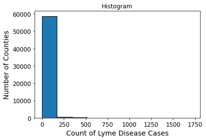

```python
import matplotlib.pyplot as plt
%matplotlib inline

plt.hist(LD_clean_df.CaseCount, edgecolor='black')
plt.ylabel('Number of Counties')
plt.xlabel('Count of Lyme Disease Cases')
plt.title('Histogram')
plt.show()
```

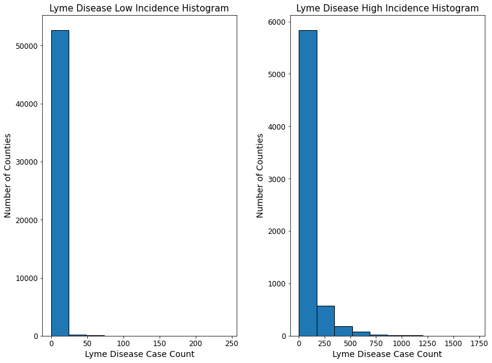

```python
import matplotlib.pyplot as plt
%matplotlib inline

# Figure
fig, (ax1, ax2) = plt.subplots(1, 2, figsize=(13, 7))
fig.set_size_inches(12, 9)

LD_clean_df_0 = LD_clean_df.loc[LD_clean_df.Frequency < 0.0001]
LD_clean_df_1 = LD_clean_df.loc[LD_clean_df.Frequency >= 0.0001]

# Plots
ax1.hist(LD_clean_df_0.CaseCount, edgecolor='black')
ax2.hist(LD_clean_df_1.CaseCount, edgecolor='black')

# Labels
ax1.set_title('Lyme Disease Low Incidence Histogram', fontsize=15)
ax1.set_xlabel('Lyme Disease Case Count')
ax1.set_ylabel('Number of Counties')
ax2.set_title('Lyme Disease High Incidence Histogram', fontsize=15)
ax2.set_xlabel('Lyme Disease Case Count')
ax2.set_ylabel('Number of Counties')

fig.tight_layout(pad=3.0)

plt.show()
#about 180 length of each bar x range
```

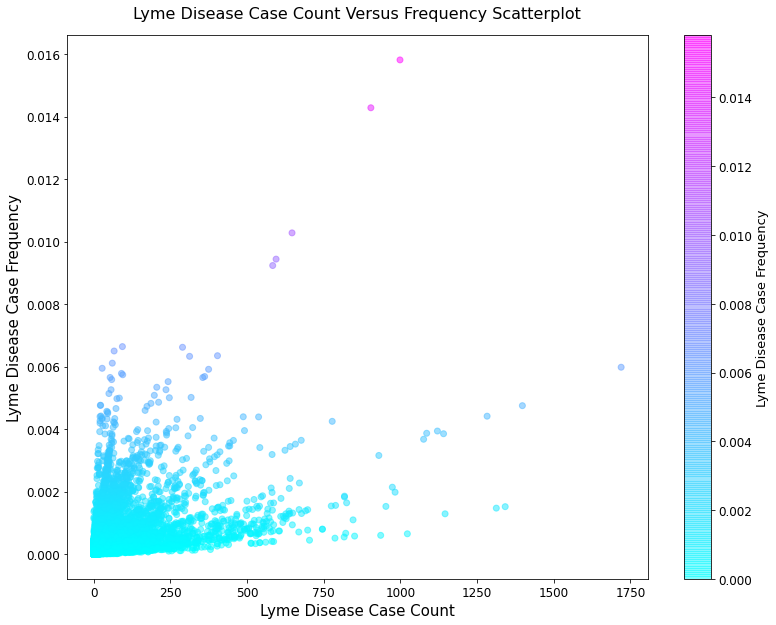

```python
import matplotlib.pyplot as plt
%matplotlib inline

# Figure
fig, ax1 = plt.subplots()
fig.set_size_inches(13, 10)

#c sequence
c = LD_clean_df['Frequency']

# Plot
plt.scatter(x=LD_clean_df['CaseCount'], y=LD_clean_df['Frequency'],
            c=c, cmap='cool', alpha=0.5)

# Labels
ax1.set_title('Lyme Disease Case Count Versus Frequency Scatterplot',
              fontsize=16, y=1.02)
ax1.set_xlabel('Lyme Disease Case Count',
              fontsize=15)
ax1.set_ylabel('Lyme Disease Case Frequency',
              fontsize=15)

cbar = plt.colorbar()
cbar.set_label('Lyme Disease Case Frequency', fontsize=13)

plt.show()
```

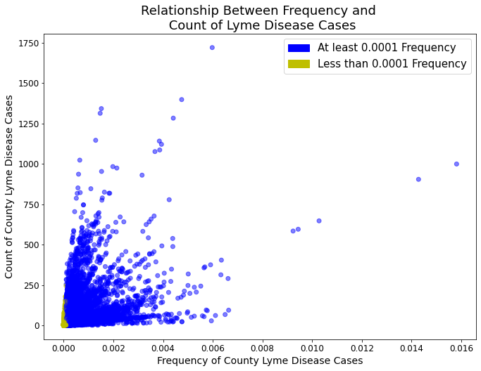

```python
### Scatter plot case count and frequency ###
import matplotlib.pyplot as plt
import matplotlib.patches as mpatches
%matplotlib inline

# Figure
fig, ax1 = plt.subplots()
fig.set_size_inches(11, 8)

#c sequence and color
color = np.where(LD_clean_df["Frequency"]<0.0001,'y','b')

# Plot
plt.scatter(x=LD_clean_df['Frequency'], y=LD_clean_df['CaseCount'],
            c=color, alpha=0.5)

# Labels
ax1.set_title('Relationship Between Frequency and \n Count of Lyme Disease Cases',
              fontsize=18)
ax1.set_xlabel('Frequency of County Lyme Disease Cases')
ax1.set_ylabel('Count of County Lyme Disease Cases')

blu_patch = mpatches.Patch(color='y', label='Less than 0.0001 Frequency')
yel_patch = mpatches.Patch(color='b', label='At least 0.0001 Frequency')
plt.legend(handles=[yel_patch, blu_patch], prop={'size': 15})

plt.show()
```

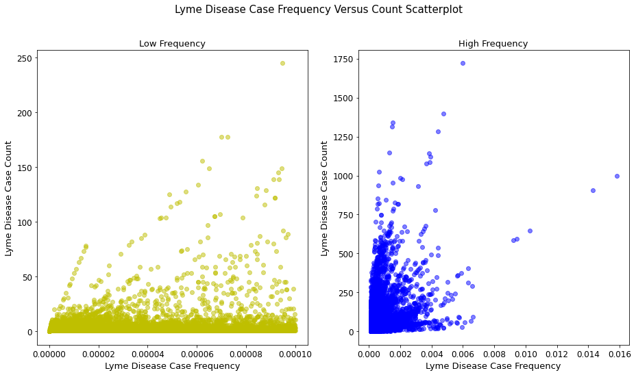

```python
import matplotlib.pyplot as plt
%matplotlib inline

d1 = LD_clean_df[LD_clean_df["Frequency"]<0.0001]
d2 = LD_clean_df[LD_clean_df["Frequency"]>=0.0001]

# Figure
fig, (ax1, ax2) = plt.subplots(1, 2, figsize=(13, 7))

#c sequence
c1 = d1['CaseCount']
c2 = d2['CaseCount']

# Plot
ax1.scatter(x=d1['Frequency'], y=d1['CaseCount'],
            color='y', alpha=0.5)
ax2.scatter(x=d2['Frequency'], y=d2['CaseCount'],
            color='b', alpha=0.5)

# Labels
fig.suptitle('Lyme Disease Case Frequency Versus Count Scatterplot',
             fontsize=15, y=1.08)
ax1.set_title('Low Frequency',
              fontsize=13)
ax1.set_xlabel('Lyme Disease Case Frequency', fontsize=13)
ax1.set_ylabel('Lyme Disease Case Count', fontsize=13)
ax2.set_title('High Frequency',
              fontsize=13)
ax2.set_xlabel('Lyme Disease Case Frequency', fontsize=13)
ax2.set_ylabel('Lyme Disease Case Count', fontsize=13)

fig.tight_layout(pad=1.0)

plt.show()
```

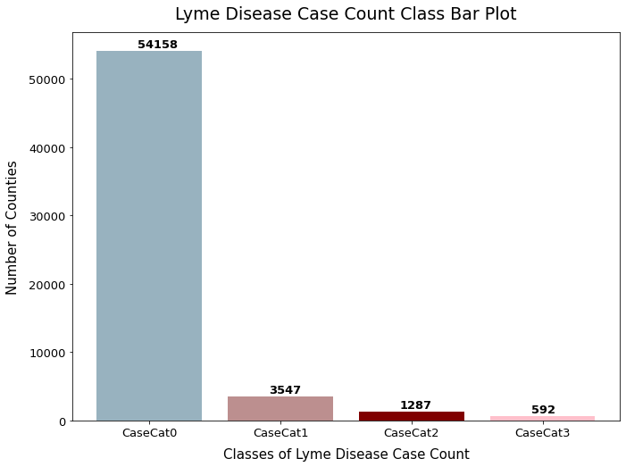

```python
#### Barplot of case count classes ###
import matplotlib.pyplot as plt
%matplotlib inline

CaseCat0 = LD_clean_df.loc[LD_clean_df.CaseCount<10]
CaseCat1 = LD_clean_df.loc[(LD_clean_df.CaseCount>=10) &
                                   (LD_clean_df.CaseCount<75)]
CaseCat2 = LD_clean_df.loc[(LD_clean_df.CaseCount>=75) &
                                   (LD_clean_df.CaseCount<225)]
CaseCat3 = LD_clean_df.loc[LD_clean_df.CaseCount>=225]

height = [len(CaseCat0), len(CaseCat1), len(CaseCat2), len(CaseCat3)]

# Figure
fig, ax1 = plt.subplots()
fig.set_size_inches(11, 8)

# Plot
ax1.bar(['CaseCat0','CaseCat1','CaseCat2','CaseCat3'],
        height=height,
        color=[(0.2, 0.4, 0.5, 0.5),'rosybrown','maroon','pink'])

# Labels
ax1.set_title('Lyme Disease Case Count Class Bar Plot', fontsize=19, y=1.02)
ax1.set_xlabel('Classes of Lyme Disease Case Count', fontsize=15, labelpad=10)
ax1.set_ylabel('Number of Counties', fontsize=15, labelpad=10)
ax1.tick_params(axis='both', which='major', labelsize=13)

for i, v in enumerate(height):
    ax1.text(i-.09, v+500, str(v), color='k', fontsize=13, fontweight='bold')

plt.show()
```

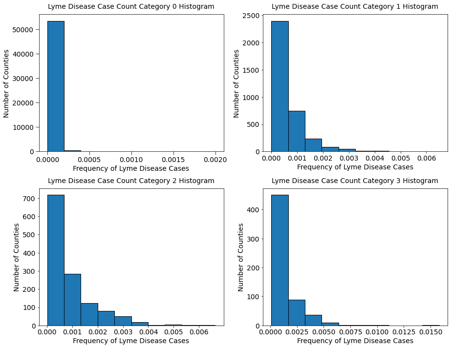

```python
#### Bar plot of case count classes ###
import matplotlib.pyplot as plt
%matplotlib inline

# Figure
fig, ax = plt.subplots(2, 2, figsize=(13, 10))

# Plot
ax[0,0].hist(CaseCat0.Frequency, edgecolor='black')
ax[0,1].hist(CaseCat1.Frequency, edgecolor='black')
ax[1,0].hist(CaseCat2.Frequency, edgecolor='black')
ax[1,1].hist(CaseCat3.Frequency, edgecolor='black')

# Labels
ax[0,0].set_title('Lyme Disease Case Count Category 0 Histogram', fontsize=14, y=1.02)
ax[0,0].set_xlabel('Frequency of Lyme Disease Cases', fontsize=14)
ax[0,0].set_ylabel('Number of Counties', fontsize=14)
ax[0,0].tick_params(axis='both', which='major', labelsize=14,length=7)

ax[0,1].set_title('Lyme Disease Case Count Category 1 Histogram', fontsize=14, y=1.02)
ax[0,1].set_xlabel('Frequency of Lyme Disease Cases', fontsize=14)
ax[0,1].set_ylabel('Number of Counties', fontsize=14)
ax[0,1].tick_params(axis='both', which='major', labelsize=14)

ax[1,0].set_title('Lyme Disease Case Count Category 2 Histogram', fontsize=14, y=1.02)
ax[1,0].set_xlabel('Frequency of Lyme Disease Cases', fontsize=14)
ax[1,0].set_ylabel('Number of Counties', fontsize=14)
ax[1,0].tick_params(axis='both', which='major', labelsize=14)

ax[1,1].set_title('Lyme Disease Case Count Category 3 Histogram', fontsize=14, y=1.02)
ax[1,1].set_xlabel('Frequency of Lyme Disease Cases', fontsize=14)
ax[1,1].set_ylabel('Number of Counties', fontsize=14)
ax[1,1].tick_params(axis='both', which='major', labelsize=14)

fig.tight_layout()

plt.show()
```

```python
for i, cat in enumerate([CaseCat0, CaseCat1, CaseCat2, CaseCat3]):
  print('Class', i, 'Frequency < 0.0001:', len(cat[cat.Frequency<0.0001]))
  print('Class', i, 'Frequency >= 0.0001:', len(cat[cat.Frequency>=0.0001]))
```

```
Class 0 Frequency < 0.0001: 52150
Class 0 Frequency >= 0.0001: 2008
Class 1 Frequency < 0.0001: 690
Class 1 Frequency >= 0.0001: 2857
Class 2 Frequency < 0.0001: 45
Class 2 Frequency >= 0.0001: 1242
Class 3 Frequency < 0.0001: 1
Class 3 Frequency >= 0.0001: 591
```

As a reminder, this is what the combined data looked like:

```python
LD_clean_df.info()
```

```
<class 'pandas.core.frame.DataFrame'>
RangeIndex: 59584 entries, 0 to 59583
Data columns (total 17 columns):
 #   Column               Non-Null Count  Dtype
---  ------               --------------  -----
 0   Ctyname              59584 non-null  object
 1   Stname               59584 non-null  object
 2   STCODE               59584 non-null  float64
 3   CTYCODE              59584 non-null  float64
 4   Year                 59584 non-null  int64
 5   CaseCount            59584 non-null  float64
 6   Population           59584 non-null  float64
 7   Frequency            59584 non-null  float64
 8   AREALAND             59584 non-null  float64
 9   CENTLAT              59584 non-null  float64
 10  CENTLON              59584 non-null  float64
 11  Population Density   59584 non-null  float64
 12  Percent Forest Area  59584 non-null  float64
 13  Precipitation        59584 non-null  float64
 14  Average Temperature  59584 non-null  float64
 15  Maximum Temperature  59584 non-null  float64
 16  Minimum Temperature  59584 non-null  float64
dtypes: float64(14), int64(1), object(2)
memory usage: 7.7+ MB
```

```python
LD_clean_df.head()
```

|  | Ctyname | Stname | STCODE | CTYCODE | Year | CaseCount | Population | Frequency | AREALAND | CENTLAT | CENTLON | Population Density | Percent Forest Area | Precipitation | Average Temperature | Maximum Temperature | Minimum Temperature |
| --- | --- | --- | --- | --- | --- | --- | --- | --- | --- | --- | --- | --- | --- | --- | --- | --- | --- |
| 0 | Autauga County | Alabama | 1.0 | 1.0 | 2000 | 0.0 | 44021.0 | 0.0 | 1.539602e+09 | 32.534897 | -86.642761 | 0.000029 | 0.705797 | 39.78 | 64.3 | 77.0 | 51.7 |
| 1 | Autauga County | Alabama | 1.0 | 1.0 | 2001 | 0.0 | 44889.0 | 0.0 | 1.539602e+09 | 32.534897 | -86.642761 | 0.000029 | 0.705797 | 60.25 | 63.8 | 75.6 | 51.9 |
| 2 | Autauga County | Alabama | 1.0 | 1.0 | 2002 | 0.0 | 45909.0 | 0.0 | 1.539602e+09 | 32.534897 | -86.642761 | 0.000030 | 0.705797 | 51.34 | 64.4 | 75.7 | 53.0 |
| 3 | Autauga County | Alabama | 1.0 | 1.0 | 2003 | 0.0 | 46800.0 | 0.0 | 1.539602e+09 | 32.534897 | -86.642761 | 0.000030 | 0.705797 | 66.54 | 63.5 | 74.5 | 52.4 |
| 4 | Autauga County | Alabama | 1.0 | 1.0 | 2004 | 0.0 | 48366.0 | 0.0 | 1.539602e+09 | 32.534897 | -86.642761 | 0.000031 | 0.705797 | 51.28 | 64.3 | 75.1 | 53.5 |

```python
import statistics

print("Median of County Frequency of Lyme Disease is : % s "
        % (statistics.median(LD_clean_df.Frequency)))
print("Median of County Case Count of Lyme Disease is : % s "
        % (statistics.median(LD_clean_df.CaseCount)))
LD_clean_df.describe()
```

```
Median of County Frequency of Lyme Disease is : 0.0
Median of County Case Count of Lyme Disease is : 0.0
```

|  | STCODE | CTYCODE | Year | CaseCount | Population | Frequency | AREALAND | CENTLAT | CENTLON | Population Density | Percent Forest Area | Precipitation | Average Temperature | Maximum Temperature | Minimum Temperature |
| --- | --- | --- | --- | --- | --- | --- | --- | --- | --- | --- | --- | --- | --- | --- | --- |
| count | 59584.000000 | 59584.000000 | 59584.000000 | 59584.000000 | 5.958400e+04 | 59584.000000 | 5.958400e+04 | 59584.000000 | 59584.000000 | 5.958400e+04 | 59584.000000 | 59584.000000 | 59584.000000 | 59584.000000 | 59584.000000 |
| mean | 30.313457 | 103.700893 | 2009.000000 | 9.096788 | 9.705477e+04 | 0.000082 | 2.909894e+09 | 38.477041 | -92.172289 | 9.975636e-05 | 0.412951 | 39.641565 | 54.901118 | 66.008115 | 43.787372 |
| std | 15.135790 | 107.706396 | 5.477272 | 48.531688 | 3.129454e+05 | 0.000354 | 9.364881e+09 | 5.256585 | 12.674421 | 6.742124e-04 | 0.210403 | 16.864384 | 8.440346 | 8.814469 | 8.315460 |
| min | 1.000000 | 1.000000 | 2000.000000 | 0.000000 | 5.500000e+01 | 0.000000 | 5.141806e+06 | 25.039041 | -174.938398 | 1.413260e-08 | 0.017210 | 0.620000 | 13.600000 | 20.100000 | 6.900000 |
| 25% | 19.000000 | 35.000000 | 2004.000000 | 0.000000 | 1.106900e+04 | 0.000000 | 1.116657e+09 | 34.714036 | -98.208678 | 6.507519e-06 | 0.288057 | 27.927500 | 48.700000 | 59.500000 | 37.800000 |
| 50% | 29.000000 | 79.000000 | 2009.000000 | 0.000000 | 2.548500e+04 | 0.000000 | 1.595510e+09 | 38.395143 | -90.368520 | 1.712622e-05 | 0.393634 | 40.040000 | 54.900000 | 66.000000 | 43.800000 |
| 75% | 45.000000 | 133.000000 | 2014.000000 | 1.000000 | 6.562725e+04 | 0.000007 | 2.392091e+09 | 41.823456 | -83.425831 | 4.317556e-05 | 0.586066 | 49.880000 | 61.300000 | 72.900000 | 49.800000 |
| max | 56.000000 | 840.000000 | 2018.000000 | 1720.000000 | 1.012054e+07 | 0.015811 | 3.769299e+11 | 69.451496 | -67.608540 | 2.789184e-02 | 0.894676 | 226.290000 | 78.600000 | 90.000000 | 70.700000 |

```python
LD_clean_df.median(axis=0)
```

```
STCODE                 2.900000e+01
CTYCODE                7.900000e+01
Year                   2.009000e+03
CaseCount              0.000000e+00
Population             2.548500e+04
Frequency              0.000000e+00
AREALAND               1.595510e+09
CENTLAT                3.839514e+01
CENTLON               -9.036852e+01
Population Density     1.712622e-05
Percent Forest Area    3.936340e-01
Precipitation          4.004000e+01
Average Temperature    5.490000e+01
Maximum Temperature    6.600000e+01
Minimum Temperature    4.380000e+01
dtype: float64
```

Since the median case count is zero, clearly the majority of the samples (county or county equivalent) had low Lyme disease frequency.

Regular boxplot and zoomed in boxplot with no outliers:

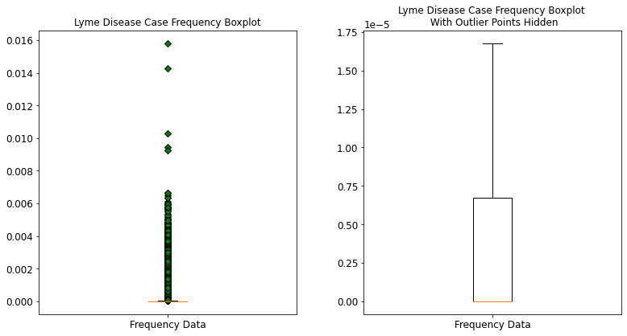

```
[array([0., 0.]), array([6.71324591e-06, 1.67754274e-05])]
```

|  | Minimum Whisker (Minimum value within Q1-1.5*IQR) | Quartile 1 (25th Percentile) | Median | Quartile 3 (75th Percentile) | Maximum Whisker (Maximum value within Q3+1.5*IQR) | Interquartile Range (Q3-Q1) |
| --- | --- | --- | --- | --- | --- | --- |
| 0 | 0.0 | 0.0 | 0.0 | 0.000007 | 0.000017 | 0.000007 |

```python
#updated
import matplotlib.pyplot as plt
%matplotlib inline

# Figure
fig, (ax1, ax2) = plt.subplots(1, 2, figsize=(12, 7))

green_diamond = dict(markerfacecolor='g', marker='D')
# Plot
p1 = ax1.boxplot(LD_clean_df.Frequency, flierprops=green_diamond, labels=["Frequency Data"])
p2 = ax2.boxplot(LD_clean_df.Frequency, showfliers=False, labels=["Frequency Data"])

ax1.set_title('Lyme Disease Case Frequency Boxplot')
ax2.set_title('Lyme Disease Case Frequency Boxplot \n With Outlier Points Hidden')

fig.tight_layout(pad=5.0)

plt.show()

print([item.get_ydata() for item in p1['whiskers']])

Q1 = p1['boxes'][0].get_ydata()[1]
Q3 = p1['boxes'][0].get_ydata()[2]
IQR = Q3-Q1
dict1={"Minimum Whisker (Minimum value within Q1-1.5*IQR)":p1['whiskers'][0].get_ydata()[1],
 "Quartile 1 (25th Percentile)":p1['boxes'][0].get_ydata()[1],
 "Median":p1['medians'][0].get_ydata()[1],
 "Quartile 3 (75th Percentile)":p1['boxes'][0].get_ydata()[2],
 "Maximum Whisker (Maximum value within Q3+1.5*IQR)":p1['whiskers'][1].get_ydata()[1],
 "Interquartile Range (Q3-Q1)": IQR}
pd.DataFrame([dict1])
```

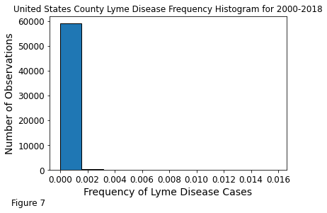

```python
import matplotlib.pyplot as plt
%matplotlib inline

plt.hist(LD_clean_df.Frequency, edgecolor='black')
plt.ylabel('Number of Observations')
plt.xlabel('Frequency of Lyme Disease Cases')
plt.title('United States County Lyme Disease Frequency Histogram for 2000-2018')
# Figure Number
plt.figtext(0, -.05, "Figure 7", fontsize=12)
plt.show()
```

The histogram and boxplots show the majority of the county observations have a frequency of Lyme Disease cases no more than approximately 6.71e-06, which would be considered low incidence.

```python
print('Number of county observations with low incidence:',
      len(LD_clean_df.loc[LD_clean_df.Frequency>=0.0001]))
print('Number of county observations with high incidence:',
      len(LD_clean_df.loc[LD_clean_df.Frequency<0.0001]))
```

[output not shown]

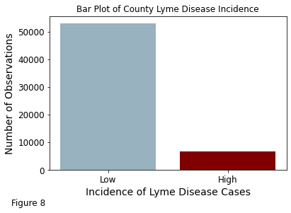

```python
%matplotlib inline

barlist = plt.bar(['Low','High'],
                  height=[len(LD_clean_df.loc[LD_clean_df.Frequency<0.0001]),
                          len(LD_clean_df.loc[LD_clean_df.Frequency>=0.0001])],
                  color=[(0.2, 0.4, 0.5, 0.5),'maroon'])
plt.xlabel('Incidence of Lyme Disease Cases')
plt.ylabel('Number of Observations')
plt.title('Bar Plot of County Lyme Disease Incidence')
# Figure Number
plt.figtext(0, -.05, "Figure 8", fontsize=12)
plt.show()
```

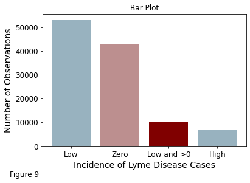

```python
%matplotlib inline

zeroCount = len(LD_clean_df.loc[LD_clean_df.Frequency==0])
mlowCount = len(LD_clean_df.loc[(LD_clean_df.Frequency>0) &
                                 (LD_clean_df.Frequency<0.0001)])
lowCount = len(LD_clean_df.loc[LD_clean_df.Frequency<0.0001])
highCount = len(LD_clean_df.loc[LD_clean_df.Frequency>=0.0001])
barlist = plt.bar(['Low','Zero','Low and >0','High'],
                  height=[lowCount,zeroCount,mlowCount,highCount],
                  color=[(0.2, 0.4, 0.5, 0.5),'rosybrown','maroon'])
plt.ylabel('Number of Observations')
plt.xlabel('Incidence of Lyme Disease Cases')
plt.title('Bar Plot')
# Figure Number
plt.figtext(0, -.05, "Figure 9", fontsize=12)
plt.show()
```

```python
print('Number of Counties with zero incidence:', zeroCount)
print('Number of Counties with low, but not zero incidence:', mlowCount)
print('Number of Counties with low incidence:', lowCount)
print('Number of Counties with high incidence:', highCount)
```

```
Number of Counties with zero incidence: 42790
Number of Counties with low, but not zero incidence: 10096
Number of Counties with low incidence: 52886
Number of Counties with high incidence: 6698
```

### 3.3.2 Creation of Lyme Disease Case Incidence and Count Classes

The CDC defines low incidence of Lyme disease cases as the average incidence of less than 10 confirmed cases per 100,000 persons for the previous three reporting years. The CDC defines high incidence of Lyme disease cases as the average incidence of at least 10 confirmed cases per 100,000 persons for previous three reporting years. [31] For purposes of this project, low incidence of Lyme disease cases will be defined as the frequency of less than 10 reported cases per 100,000 persons in one year. High incidence of Lyme disease cases will be defined as the frequency of at least 10 reported cases per 100,000 persons in one year.

I seperated the frequency of Lyme disease into two classes: low incidence and high incidence.

Frequency: 10 cases/100000 persons = 0.0001 cases/person

First I made a copy of the clean Lyme disease dataset that contained all the variables.

```python
LD_full_df = LD_clean_df.copy()
# or could do:
#LD_full_df = pd.read_csv("LD_clean_df.csv", encoding='latin-1')
```

The function displayed in the code below created the classes for the Incidence target variable. The function was then applied to the full Lyme disease dataset where the values in the Incidence column described the Lyme disease incidence for the year in each values' respective row.

```python
def funcInc(row):
    if row['Frequency'] < 0.0001:
        val = 'Low'
    else:
        val = 'High'
    return val
```

```python
LD_full_df['Incidence'] = LD_full_df.apply(funcInc, axis=1)
```

The number of observations in the full dataset for each class of the Incidence variable is displayed using the code below.

```python
LD_full_df['Incidence'].value_counts()
```

```
Low     52886
High     6698
Name: Incidence, dtype: int64
```

The following function displayed in the code below created the classes for the categorical case count target variable. The function was then applied to the full Lyme disease dataset where the values in the CaseCat column categorically described the Lyme disease case count for the year in each values' respective row.

```python
def funcCaseCat(row):
    if row['CaseCount'] < 10:
        val = 0
    elif row['CaseCount'] < 75:
        val = 1
    elif row['CaseCount'] < 225:
        val = 2
    else:
        val = 3
    return val
```

```python
LD_full_df['CaseCat'] = LD_full_df.apply(funcCaseCat, axis=1)
```

The number of observations in the full dataset for each class of the categorical case count variable is displayed using the code below.

```python
LD_full_df['CaseCat'].value_counts()
```

```
0    54158
1     3547
2     1287
3      592
Name: CaseCat, dtype: int64
```

After adding those two columns, the full dataset looked like this:

```python
LD_full_df.info()
```

```
<class 'pandas.core.frame.DataFrame'>
RangeIndex: 59584 entries, 0 to 59583
Data columns (total 19 columns):
 #   Column               Non-Null Count  Dtype
---  ------               --------------  -----
 0   Ctyname              59584 non-null  object
 1   Stname               59584 non-null  object
 2   STCODE               59584 non-null  float64
 3   CTYCODE              59584 non-null  float64
 4   Year                 59584 non-null  int64
 5   CaseCount            59584 non-null  float64
 6   Population           59584 non-null  float64
 7   Frequency            59584 non-null  float64
 8   AREALAND             59584 non-null  float64
 9   CENTLAT              59584 non-null  float64
 10  CENTLON              59584 non-null  float64
 11  Population Density   59584 non-null  float64
 12  Percent Forest Area  59584 non-null  float64
 13  Precipitation        59584 non-null  float64
 14  Average Temperature  59584 non-null  float64
 15  Maximum Temperature  59584 non-null  float64
 16  Minimum Temperature  59584 non-null  float64
 17  Incidence            59584 non-null  object
 18  CaseCat              59584 non-null  int64
dtypes: float64(14), int64(2), object(3)
memory usage: 8.6+ MB
```

```python
LD_full_df.head()
```

|  | Ctyname | Stname | STCODE | CTYCODE | Year | CaseCount | Population | Frequency | AREALAND | CENTLAT | CENTLON | Population Density | Percent Forest Area | Precipitation | Average Temperature | Maximum Temperature | Minimum Temperature | Incidence | CaseCat |
| --- | --- | --- | --- | --- | --- | --- | --- | --- | --- | --- | --- | --- | --- | --- | --- | --- | --- | --- | --- |
| 0 | Autauga County | Alabama | 1.0 | 1.0 | 2000 | 0.0 | 44021.0 | 0.0 | 1.539602e+09 | 32.534897 | -86.642761 | 0.000029 | 0.705797 | 39.78 | 64.3 | 77.0 | 51.7 | Low | 0 |
| 1 | Autauga County | Alabama | 1.0 | 1.0 | 2001 | 0.0 | 44889.0 | 0.0 | 1.539602e+09 | 32.534897 | -86.642761 | 0.000029 | 0.705797 | 60.25 | 63.8 | 75.6 | 51.9 | Low | 0 |
| 2 | Autauga County | Alabama | 1.0 | 1.0 | 2002 | 0.0 | 45909.0 | 0.0 | 1.539602e+09 | 32.534897 | -86.642761 | 0.000030 | 0.705797 | 51.34 | 64.4 | 75.7 | 53.0 | Low | 0 |
| 3 | Autauga County | Alabama | 1.0 | 1.0 | 2003 | 0.0 | 46800.0 | 0.0 | 1.539602e+09 | 32.534897 | -86.642761 | 0.000030 | 0.705797 | 66.54 | 63.5 | 74.5 | 52.4 | Low | 0 |
| 4 | Autauga County | Alabama | 1.0 | 1.0 | 2004 | 0.0 | 48366.0 | 0.0 | 1.539602e+09 | 32.534897 | -86.642761 | 0.000031 | 0.705797 | 51.28 | 64.3 | 75.1 | 53.5 | Low | 0 |

Any county that had less than a population of 10,000, only needed one recorded case in a year for the county to be considered high incidence for that year. The code below shows how that number was found and an observation in the dataset that was High Incidence with only one recorded Lyme disease case.

```python
min(LD_full_df.CaseCount[LD_full_df.Incidence=='High'])
```

```
1.0
```

```python
LD_full_df.iloc[LD_full_df.CaseCount[LD_full_df.Incidence=='High'].idxmin()]
```

```
Ctyname                Greene County
Stname                       Alabama
STCODE                             1
CTYCODE                           63
Year                            2007
CaseCount                          1
Population                      9385
Frequency                0.000106553
AREALAND                 1.67578e+09
CENTLAT                       32.853
CENTLON                     -87.9522
Population Density       5.60037e-06
Percent Forest Area         0.705797
Precipitation                  36.14
Average Temperature             64.9
Maximum Temperature             77.2
Minimum Temperature             52.6
Incidence                       High
CaseCat                            0
Name: 596, dtype: object
```

The code below created a histogram displaying the number of High Incidence observations for each case count in the lowest case count category.

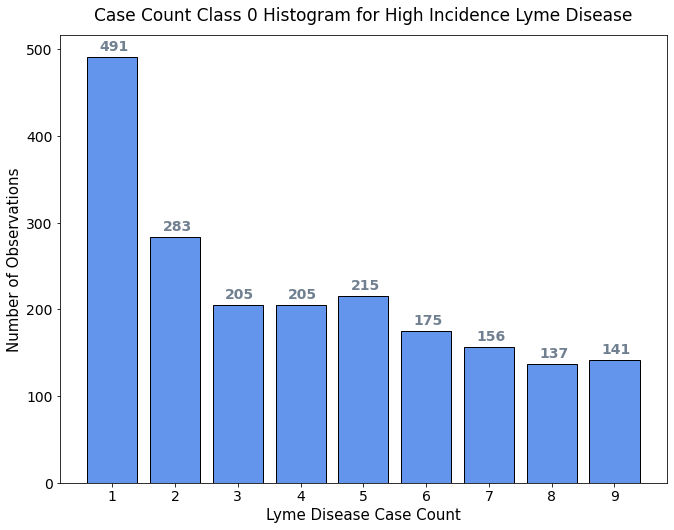

```python
import matplotlib.pyplot as plt
%matplotlib inline

LD_full_df_1 = LD_full_df.loc[(LD_full_df['Incidence'] == 'High') &
                              (LD_full_df['CaseCat'] == 0)]
caseCount, numObs = np.unique(LD_full_df_1.CaseCount, return_counts=True)

# Figure
fig, ax = plt.subplots()
fig.set_size_inches(10, 8)

# Plots
ax.bar(caseCount, numObs, align='center', edgecolor='black', facecolor='cornflowerblue')

# Labels
ax.set_title('Case Count Class 0 Histogram for High Incidence Lyme Disease',
              fontsize=17, y=1.02)
ax.set_xlabel('Lyme Disease Case Count', fontsize=15)
ax.set_ylabel('Number of Observations', fontsize=15)
ax.set_xticks(caseCount)
ax.tick_params(labelsize=14)

for i, v in enumerate(numObs):
    ax.text(i+.8, v+8, str(v), color='slategrey', fontsize=14, fontweight='bold')

fig.tight_layout(pad=3.0)

plt.show()
```

### 3.3.3 Creation of Future Lyme Disease Case Incidence and Count Data

If the classifier was trained to predict the Lyme disease classes of the current year, then the year would have to be over in order for all the data to be obtained and classified. For example, living in the year 2020, the latest classifications that could be made would be for 2019. By fall of 2020, the 2019 reported cases would already be out and so the classier would not be needed. If the classifier was trained to predict Lyme disease classes one year in advance, then the latest classification that could be made would be for 2020. This might be useful for some applications, however, it may not leave enough time to prepare for why the Lyme disease classes were wanted in the first place. If the classifier was trained to predict the Lyme disease classes two years in advance, then the latest classifications that could be made would be for 2021. This could be useful and leave more time for preperation. Thus, the Lyme disease classification done in this project was a prediction of the Lyme disease classes that would occur two years into the future.

The classifier predicted the incidence and categorical case count of counties and county equivalents two years into the future. For example, the data for the year 2000 was used to predict the 2002 Lyme disease incidence and categorical case count. These new columns in the dataset were called "Future Incidence" and "Future CaseCat". The following code created these columns.

```python
LD_fut_df = LD_full_df.loc[:,['Ctyname','Stname','STCODE','CTYCODE','Year',
                           'CaseCount','CaseCat','Frequency','Incidence']]
LD_fut_df['Future Year'] = LD_fut_df.loc[:,['Year']]
LD_fut_df['Future CaseCount'] = LD_fut_df.loc[:,['CaseCount']]
LD_fut_df['Future CaseCat'] = LD_fut_df.loc[:,['CaseCat']]
LD_fut_df['Future Frequency'] = LD_fut_df.loc[:,['Frequency']]
LD_fut_df['Future Incidence'] = LD_fut_df.loc[:,['Incidence']]

def funcFut(row):
  y = row['Year'] - 2
  return y

LD_fut_df['Year'] = LD_fut_df.apply(funcFut, axis=1)

LD_fut_df.head()
```

|  | Ctyname | Stname | STCODE | CTYCODE | Year | CaseCount | CaseCat | Frequency | Incidence | Future Year | Future CaseCount | Future CaseCat | Future Frequency | Future Incidence |
| --- | --- | --- | --- | --- | --- | --- | --- | --- | --- | --- | --- | --- | --- | --- |
| 0 | Autauga County | Alabama | 1.0 | 1.0 | 1998 | 0.0 | 0 | 0.0 | Low | 2000 | 0.0 | 0 | 0.0 | Low |
| 1 | Autauga County | Alabama | 1.0 | 1.0 | 1999 | 0.0 | 0 | 0.0 | Low | 2001 | 0.0 | 0 | 0.0 | Low |
| 2 | Autauga County | Alabama | 1.0 | 1.0 | 2000 | 0.0 | 0 | 0.0 | Low | 2002 | 0.0 | 0 | 0.0 | Low |
| 3 | Autauga County | Alabama | 1.0 | 1.0 | 2001 | 0.0 | 0 | 0.0 | Low | 2003 | 0.0 | 0 | 0.0 | Low |
| 4 | Autauga County | Alabama | 1.0 | 1.0 | 2002 | 0.0 | 0 | 0.0 | Low | 2004 | 0.0 | 0 | 0.0 | Low |

```python
LD_fut_df.drop(columns=['CaseCount','CaseCat','Frequency','Incidence'], inplace=True)
LD_fut_df.head()
```

|  | Ctyname | Stname | STCODE | CTYCODE | Year | Future Year | Future CaseCount | Future CaseCat | Future Frequency | Future Incidence |
| --- | --- | --- | --- | --- | --- | --- | --- | --- | --- | --- |
| 0 | Autauga County | Alabama | 1.0 | 1.0 | 1998 | 2000 | 0.0 | 0 | 0.0 | Low |
| 1 | Autauga County | Alabama | 1.0 | 1.0 | 1999 | 2001 | 0.0 | 0 | 0.0 | Low |
| 2 | Autauga County | Alabama | 1.0 | 1.0 | 2000 | 2002 | 0.0 | 0 | 0.0 | Low |
| 3 | Autauga County | Alabama | 1.0 | 1.0 | 2001 | 2003 | 0.0 | 0 | 0.0 | Low |
| 4 | Autauga County | Alabama | 1.0 | 1.0 | 2002 | 2004 | 0.0 | 0 | 0.0 | Low |

```python
LD_ff_df = pd.merge(LD_full_df, LD_fut_df, how='inner',
                    on=['Ctyname','Stname','STCODE','CTYCODE','Year'])
LD_ff_df['Year'] = LD_ff_df['Year'].astype(int)
print(LD_ff_df.shape) # (53312, 24)
LD_ff_df.head()
```

```
(53312, 24)
```

|  | Ctyname | Stname | STCODE | CTYCODE | Year | CaseCount | Population | Frequency | AREALAND | CENTLAT | CENTLON | Population Density | Percent Forest Area | Precipitation | Average Temperature | Maximum Temperature | Minimum Temperature | Incidence | CaseCat | Future Year | Future CaseCount | Future CaseCat | Future Frequency | Future Incidence |
| --- | --- | --- | --- | --- | --- | --- | --- | --- | --- | --- | --- | --- | --- | --- | --- | --- | --- | --- | --- | --- | --- | --- | --- | --- |
| 0 | Autauga County | Alabama | 1.0 | 1.0 | 2000 | 0.0 | 44021.0 | 0.0 | 1.539602e+09 | 32.534897 | -86.642761 | 0.000029 | 0.705797 | 39.78 | 64.3 | 77.0 | 51.7 | Low | 0 | 2002 | 0.0 | 0 | 0.0 | Low |
| 1 | Autauga County | Alabama | 1.0 | 1.0 | 2001 | 0.0 | 44889.0 | 0.0 | 1.539602e+09 | 32.534897 | -86.642761 | 0.000029 | 0.705797 | 60.25 | 63.8 | 75.6 | 51.9 | Low | 0 | 2003 | 0.0 | 0 | 0.0 | Low |
| 2 | Autauga County | Alabama | 1.0 | 1.0 | 2002 | 0.0 | 45909.0 | 0.0 | 1.539602e+09 | 32.534897 | -86.642761 | 0.000030 | 0.705797 | 51.34 | 64.4 | 75.7 | 53.0 | Low | 0 | 2004 | 0.0 | 0 | 0.0 | Low |
| 3 | Autauga County | Alabama | 1.0 | 1.0 | 2003 | 0.0 | 46800.0 | 0.0 | 1.539602e+09 | 32.534897 | -86.642761 | 0.000030 | 0.705797 | 66.54 | 63.5 | 74.5 | 52.4 | Low | 0 | 2005 | 0.0 | 0 | 0.0 | Low |
| 4 | Autauga County | Alabama | 1.0 | 1.0 | 2004 | 0.0 | 48366.0 | 0.0 | 1.539602e+09 | 32.534897 | -86.642761 | 0.000031 | 0.705797 | 51.28 | 64.3 | 75.1 | 53.5 | Low | 0 | 2006 | 0.0 | 0 | 0.0 | Low |

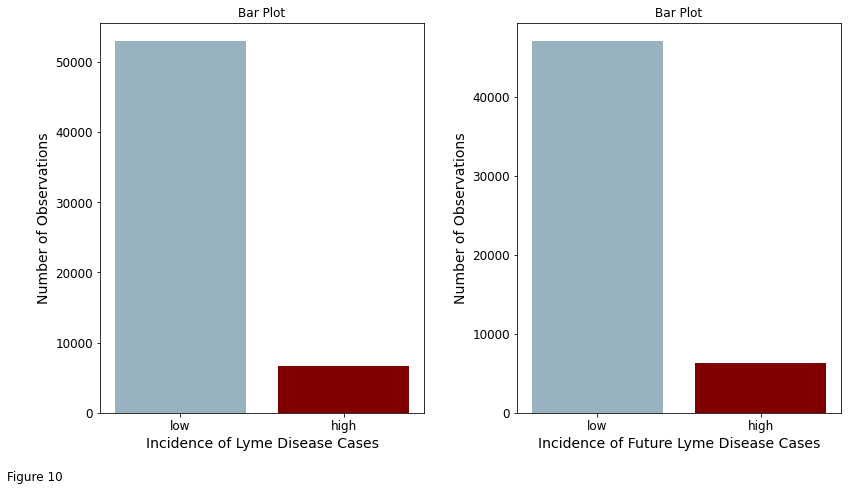

```python
lowCount = len(LD_clean_df.loc[LD_clean_df.Frequency<0.0001])
highCount = len(LD_clean_df.loc[LD_clean_df.Frequency>=0.0001])
lowCountFut = len(LD_ff_df[LD_ff_df['Future Incidence']=="Low"])
highCountFut = len(LD_ff_df[LD_ff_df['Future Incidence']=="High"])

%matplotlib inline

# Figure
fig, ax = plt.subplots(1, 2, figsize=(12, 7))
# Bar Plot
ax[0].bar(['low','high'], height=[lowCount, highCount],
            color=[(0.2, 0.4, 0.5, 0.5),'maroon'])
ax[1].bar(['low','high'], height=[lowCountFut, highCountFut],
            color=[(0.2, 0.4, 0.5, 0.5),'maroon'])

# Labels
ax[0].set_title('Bar Plot')
ax[0].set_xlabel('Incidence of Lyme Disease Cases')
ax[0].set_ylabel('Number of Observations')
ax[1].set_title('Bar Plot')
ax[1].set_xlabel('Incidence of Future Lyme Disease Cases')
#plt.xlabel('Future Incidence of Lyme Disease Cases')
ax[1].set_ylabel('Number of Observations')

plt.figtext(0, 0, "Figure 10", fontsize=12)

fig.tight_layout(pad=3.0)

plt.show()

# First bar plot is for years 2000-2018
# Second bar plot is for years 2002-2018
```

[figure not shown]

```python
#### Barplot of case count classes ###
%matplotlib inline

CaseCat0 = LD_clean_df.loc[LD_clean_df.CaseCount<10]
CaseCat1 = LD_clean_df.loc[(LD_clean_df.CaseCount>=10) &
                                   (LD_clean_df.CaseCount<75)]
CaseCat2 = LD_clean_df.loc[(LD_clean_df.CaseCount>=75) &
                                   (LD_clean_df.CaseCount<225)]
CaseCat3 = LD_clean_df.loc[LD_clean_df.CaseCount>=225]

CaseCat0Fut = LD_ff_df.loc[LD_ff_df['Future CaseCat']==0]
CaseCat1Fut = LD_ff_df.loc[LD_ff_df['Future CaseCat']==1]
CaseCat2Fut = LD_ff_df.loc[LD_ff_df['Future CaseCat']==2]
CaseCat3Fut = LD_ff_df.loc[LD_ff_df['Future CaseCat']==3]

# Figure
fig, ax = plt.subplots()
fig.set_size_inches(11, 8)

# set height of bar
height = [len(CaseCat0), len(CaseCat1), len(CaseCat2), len(CaseCat3)]
heightFut = [len(CaseCat0Fut), len(CaseCat1Fut), len(CaseCat2Fut), len(CaseCat3Fut)]

# set width of bar
barWidth = 0.4

# Set position of bar on X axis
r1 = np.arange(len(height))
r2 = [x + barWidth for x in r1]

# Make the Bar plot
ax.bar(r1, height, color='#7f6d5f', width=barWidth, edgecolor='white', label='All')
ax.bar(r2, heightFut, color='#2d7f5e', width=barWidth, edgecolor='white', label='Future')

# Labels
ax.set_title('Lyme Disease Case Count Bar Plot', fontsize=17, y=1.02)
ax.set_xlabel('Lyme Disease Case Count Class', fontsize=15, labelpad=10)
ax.set_ylabel('Number of Observations', fontsize=15, labelpad=10)
# Add xticks at center of class bars
plt.xticks([r + barWidth/2 for r in range(len(height))],
           ['0' '\n' '(Less than 10)',
            '1' '\n' '(At least 10' '\n' 'and less than 75)',
            '2' '\n' '(At least 75' '\n' 'and less than 255)',
            '3' '\n' '(At least 225)'])
ax.tick_params(labelsize=14)

# Display bar heights
for i, v in enumerate(height):
    ax.text(i-.13, v+500, str(v), color='k', fontsize=13, fontweight='bold')
for i, v in enumerate(heightFut):
    ax.text(i+.28, v+500, str(v), color='k', fontsize=13, fontweight='bold')

# Create legend
plt.legend(fontsize=17)

# Figure Number
plt.figtext(0, -.05, "Figure num", fontsize=12)

# Show graphic
plt.show()

# number of cases in parentheses
```

```python
LD_ff_df.to_csv(r'LD_FullFut_df.csv', index = False)
```

```python
LD_ff_df = pd.read_csv("LD_FullFut_df.csv",
                          encoding='latin-1')
```

### 3.3.4 Seperation of Training and Test Sets

I made the test set approximately 20% of the entire "LD_ff_df" dataset

First, I created the test set starting with the years 2004, 2011, and 2018, then later I added the rest to meet 20%.

```python
# test set
test_set_part = LD_ff_df.loc[(LD_ff_df['Future Year']==2004) |
                             (LD_ff_df['Future Year']==2011) |
                             (LD_ff_df['Future Year']==2018)].copy()
```

```python
print(test_set_part.shape) # (3*(3141 U.S. counties - 5 Hawaii counties)=9408, 24)
test_set_part.head()
```

```
(9408, 24)
```

|  | Ctyname | Stname | STCODE | CTYCODE | Year | CaseCount | Population | Frequency | AREALAND | CENTLAT | CENTLON | Population Density | Percent Forest Area | Precipitation | Average Temperature | Maximum Temperature | Minimum Temperature | Incidence | CaseCat | Future Year | Future CaseCount | Future CaseCat | Future Frequency | Future Incidence |
| --- | --- | --- | --- | --- | --- | --- | --- | --- | --- | --- | --- | --- | --- | --- | --- | --- | --- | --- | --- | --- | --- | --- | --- | --- |
| 2 | Autauga County | Alabama | 1.0 | 1.0 | 2002 | 0.0 | 45909.0 | 0.000000 | 1.539602e+09 | 32.534897 | -86.642761 | 0.000030 | 0.705797 | 51.34 | 64.4 | 75.7 | 53.0 | Low | 0 | 2004 | 0.0 | 0 | 0.000000 | Low |
| 9 | Autauga County | Alabama | 1.0 | 1.0 | 2009 | 0.0 | 54135.0 | 0.000000 | 1.539602e+09 | 32.534897 | -86.642761 | 0.000035 | 0.705797 | 73.20 | 63.8 | 74.6 | 52.9 | Low | 0 | 2011 | 0.0 | 0 | 0.000000 | Low |
| 16 | Autauga County | Alabama | 1.0 | 1.0 | 2016 | 2.0 | 55242.0 | 0.000036 | 1.539602e+09 | 32.534897 | -86.642761 | 0.000036 | 0.705797 | 50.76 | 66.1 | 78.5 | 53.7 | Low | 0 | 2018 | 0.0 | 0 | 0.000000 | Low |
| 19 | Baldwin County | Alabama | 1.0 | 3.0 | 2002 | 1.0 | 147957.0 | 0.000007 | 4.117626e+09 | 30.660178 | -87.749784 | 0.000036 | 0.705797 | 65.80 | 67.3 | 77.7 | 56.9 | Low | 0 | 2004 | 0.0 | 0 | 0.000000 | Low |
| 26 | Baldwin County | Alabama | 1.0 | 3.0 | 2009 | 1.0 | 179406.0 | 0.000006 | 4.117626e+09 | 30.660178 | -87.749784 | 0.000044 | 0.705797 | 78.43 | 67.2 | 77.3 | 57.0 | Low | 0 | 2011 | 1.0 | 0 | 0.000005 | Low |

```python
rowIndex = LD_ff_df.index[(LD_ff_df['Future Year'] == 2004) |
                          (LD_ff_df['Future Year'] == 2011) |
                          (LD_ff_df['Future Year'] == 2018)]
# LD_ff_df.loc[rowIndex] is same as test_set_part
print(LD_ff_df.loc[rowIndex].shape)
LD_ff_df.loc[rowIndex].head()
```

```
(9408, 24)
```

|  | Ctyname | Stname | STCODE | CTYCODE | Year | CaseCount | Population | Frequency | AREALAND | CENTLAT | CENTLON | Population Density | Percent Forest Area | Precipitation | Average Temperature | Maximum Temperature | Minimum Temperature | Incidence | CaseCat | Future Year | Future CaseCount | Future CaseCat | Future Frequency | Future Incidence |
| --- | --- | --- | --- | --- | --- | --- | --- | --- | --- | --- | --- | --- | --- | --- | --- | --- | --- | --- | --- | --- | --- | --- | --- | --- |
| 2 | Autauga County | Alabama | 1.0 | 1.0 | 2002 | 0.0 | 45909.0 | 0.000000 | 1.539602e+09 | 32.534897 | -86.642761 | 0.000030 | 0.705797 | 51.34 | 64.4 | 75.7 | 53.0 | Low | 0 | 2004 | 0.0 | 0 | 0.000000 | Low |
| 9 | Autauga County | Alabama | 1.0 | 1.0 | 2009 | 0.0 | 54135.0 | 0.000000 | 1.539602e+09 | 32.534897 | -86.642761 | 0.000035 | 0.705797 | 73.20 | 63.8 | 74.6 | 52.9 | Low | 0 | 2011 | 0.0 | 0 | 0.000000 | Low |
| 16 | Autauga County | Alabama | 1.0 | 1.0 | 2016 | 2.0 | 55242.0 | 0.000036 | 1.539602e+09 | 32.534897 | -86.642761 | 0.000036 | 0.705797 | 50.76 | 66.1 | 78.5 | 53.7 | Low | 0 | 2018 | 0.0 | 0 | 0.000000 | Low |
| 19 | Baldwin County | Alabama | 1.0 | 3.0 | 2002 | 1.0 | 147957.0 | 0.000007 | 4.117626e+09 | 30.660178 | -87.749784 | 0.000036 | 0.705797 | 65.80 | 67.3 | 77.7 | 56.9 | Low | 0 | 2004 | 0.0 | 0 | 0.000000 | Low |
| 26 | Baldwin County | Alabama | 1.0 | 3.0 | 2009 | 1.0 | 179406.0 | 0.000006 | 4.117626e+09 | 30.660178 | -87.749784 | 0.000044 | 0.705797 | 78.43 | 67.2 | 77.3 | 57.0 | Low | 0 | 2011 | 1.0 | 0 | 0.000005 | Low |

```python
rest_set = LD_ff_df.drop(rowIndex, axis=0)
```

```python
print(LD_ff_df.shape) # (53312, 24)
print(rest_set.shape) # (53312 - 3*(3141-5)= 53312 - 9408 = 43904, 24)
rest_set.head()
```

```
(53312, 24)
(43904, 24)
```

|  | Ctyname | Stname | STCODE | CTYCODE | Year | CaseCount | Population | Frequency | AREALAND | CENTLAT | CENTLON | Population Density | Percent Forest Area | Precipitation | Average Temperature | Maximum Temperature | Minimum Temperature | Incidence | CaseCat | Future Year | Future CaseCount | Future CaseCat | Future Frequency | Future Incidence |
| --- | --- | --- | --- | --- | --- | --- | --- | --- | --- | --- | --- | --- | --- | --- | --- | --- | --- | --- | --- | --- | --- | --- | --- | --- |
| 0 | Autauga County | Alabama | 1.0 | 1.0 | 2000 | 0.0 | 44021.0 | 0.0 | 1.539602e+09 | 32.534897 | -86.642761 | 0.000029 | 0.705797 | 39.78 | 64.3 | 77.0 | 51.7 | Low | 0 | 2002 | 0.0 | 0 | 0.0 | Low |
| 1 | Autauga County | Alabama | 1.0 | 1.0 | 2001 | 0.0 | 44889.0 | 0.0 | 1.539602e+09 | 32.534897 | -86.642761 | 0.000029 | 0.705797 | 60.25 | 63.8 | 75.6 | 51.9 | Low | 0 | 2003 | 0.0 | 0 | 0.0 | Low |
| 3 | Autauga County | Alabama | 1.0 | 1.0 | 2003 | 0.0 | 46800.0 | 0.0 | 1.539602e+09 | 32.534897 | -86.642761 | 0.000030 | 0.705797 | 66.54 | 63.5 | 74.5 | 52.4 | Low | 0 | 2005 | 0.0 | 0 | 0.0 | Low |
| 4 | Autauga County | Alabama | 1.0 | 1.0 | 2004 | 0.0 | 48366.0 | 0.0 | 1.539602e+09 | 32.534897 | -86.642761 | 0.000031 | 0.705797 | 51.28 | 64.3 | 75.1 | 53.5 | Low | 0 | 2006 | 0.0 | 0 | 0.0 | Low |
| 5 | Autauga County | Alabama | 1.0 | 1.0 | 2005 | 0.0 | 49676.0 | 0.0 | 1.539602e+09 | 32.534897 | -86.642761 | 0.000032 | 0.705797 | 58.33 | 64.0 | 75.6 | 52.5 | Low | 0 | 2007 | 0.0 | 0 | 0.0 | Low |

To add random stratified data to the test set, I created two subsets of the train set with one of the subsets being the percentage needed to meet 20%.

```python
from sklearn.model_selection import StratifiedShuffleSplit

perc = 0.2 - (len(test_set_part)/len(LD_ff_df))
split = StratifiedShuffleSplit(n_splits=1, test_size=perc, random_state=42)
for train_index, test_index in split.split(
    rest_set.reset_index(), rest_set.reset_index()["Future Incidence"]):
  strat_train_set = rest_set.reset_index().loc[train_index]
  strat_test_set = rest_set.reset_index().loc[test_index]
```

```python
print(strat_test_set.shape)
strat_test_set.head() #index column is previous index from LD_ff_df
```

```
(1034, 25)
```

|  | index | Ctyname | Stname | STCODE | CTYCODE | Year | CaseCount | Population | Frequency | AREALAND | CENTLAT | CENTLON | Population Density | Percent Forest Area | Precipitation | Average Temperature | Maximum Temperature | Minimum Temperature | Incidence | CaseCat | Future Year | Future CaseCount | Future CaseCat | Future Frequency | Future Incidence |
| --- | --- | --- | --- | --- | --- | --- | --- | --- | --- | --- | --- | --- | --- | --- | --- | --- | --- | --- | --- | --- | --- | --- | --- | --- | --- |
| 24096 | 29260 | Richardson County | Nebraska | 31.0 | 147.0 | 2003 | 0.0 | 8949.0 | 0.000000 | 1.429261e+09 | 40.125109 | -95.717479 | 0.000006 | 0.032054 | 28.73 | 52.5 | 64.1 | 40.9 | Low | 0 | 2005 | 0.0 | 0 | 0.000000 | Low |
| 8433 | 10240 | Clinton County | Illinois | 17.0 | 27.0 | 2006 | 0.0 | 37051.0 | 0.000000 | 1.227500e+09 | 38.606496 | -89.422575 | 0.000030 | 0.136440 | 37.10 | 56.6 | 66.9 | 46.4 | Low | 0 | 2008 | 0.0 | 0 | 0.000000 | Low |
| 9879 | 11996 | Dearborn County | Indiana | 18.0 | 29.0 | 2011 | 0.0 | 49985.0 | 0.000000 | 7.901712e+08 | 39.145098 | -84.973340 | 0.000063 | 0.210650 | 64.59 | 54.8 | 64.4 | 45.1 | Low | 0 | 2013 | 0.0 | 0 | 0.000000 | Low |
| 43225 | 52487 | Pepin County | Wisconsin | 55.0 | 91.0 | 2008 | 3.0 | 7545.0 | 0.000398 | 6.008945e+08 | 44.582950 | -92.001852 | 0.000013 | 0.489888 | 28.95 | 42.7 | 53.0 | 32.4 | High | 0 | 2010 | 19.0 | 1 | 0.002544 | High |
| 1622 | 1969 | Bradley County | Arkansas | 5.0 | 11.0 | 2014 | 0.0 | 11016.0 | 0.000000 | 1.681392e+09 | 33.466252 | -92.162417 | 0.000007 | 0.563162 | 49.43 | 60.9 | 71.6 | 50.3 | Low | 0 | 2016 | 0.0 | 0 | 0.000000 | Low |

The code below shows how the random stratified test data was added to the test set.

```python
# Adding the stratified test set to the partial test set
test_set = test_set_part.append(strat_test_set.set_index('index'))
```

```python
print(test_set.shape)
test_set.head()
```

```
(10442, 24)
```

|  | Ctyname | Stname | STCODE | CTYCODE | Year | CaseCount | Population | Frequency | AREALAND | CENTLAT | CENTLON | Population Density | Percent Forest Area | Precipitation | Average Temperature | Maximum Temperature | Minimum Temperature | Incidence | CaseCat | Future Year | Future CaseCount | Future CaseCat | Future Frequency | Future Incidence |
| --- | --- | --- | --- | --- | --- | --- | --- | --- | --- | --- | --- | --- | --- | --- | --- | --- | --- | --- | --- | --- | --- | --- | --- | --- |
| 2 | Autauga County | Alabama | 1.0 | 1.0 | 2002 | 0.0 | 45909.0 | 0.000000 | 1.539602e+09 | 32.534897 | -86.642761 | 0.000030 | 0.705797 | 51.34 | 64.4 | 75.7 | 53.0 | Low | 0 | 2004 | 0.0 | 0 | 0.000000 | Low |
| 9 | Autauga County | Alabama | 1.0 | 1.0 | 2009 | 0.0 | 54135.0 | 0.000000 | 1.539602e+09 | 32.534897 | -86.642761 | 0.000035 | 0.705797 | 73.20 | 63.8 | 74.6 | 52.9 | Low | 0 | 2011 | 0.0 | 0 | 0.000000 | Low |
| 16 | Autauga County | Alabama | 1.0 | 1.0 | 2016 | 2.0 | 55242.0 | 0.000036 | 1.539602e+09 | 32.534897 | -86.642761 | 0.000036 | 0.705797 | 50.76 | 66.1 | 78.5 | 53.7 | Low | 0 | 2018 | 0.0 | 0 | 0.000000 | Low |
| 19 | Baldwin County | Alabama | 1.0 | 3.0 | 2002 | 1.0 | 147957.0 | 0.000007 | 4.117626e+09 | 30.660178 | -87.749784 | 0.000036 | 0.705797 | 65.80 | 67.3 | 77.7 | 56.9 | Low | 0 | 2004 | 0.0 | 0 | 0.000000 | Low |
| 26 | Baldwin County | Alabama | 1.0 | 3.0 | 2009 | 1.0 | 179406.0 | 0.000006 | 4.117626e+09 | 30.660178 | -87.749784 | 0.000044 | 0.705797 | 78.43 | 67.2 | 77.3 | 57.0 | Low | 0 | 2011 | 1.0 | 0 | 0.000005 | Low |

```python
strat_train_set.set_index(strat_train_set['index'].values, inplace=True)
strat_train_set.drop('index', axis=1, inplace=True)
print(strat_train_set.shape) #(42870, 24)
strat_train_set.head()
```

```
(42870, 24)
```

|  | Ctyname | Stname | STCODE | CTYCODE | Year | CaseCount | Population | Frequency | AREALAND | CENTLAT | CENTLON | Population Density | Percent Forest Area | Precipitation | Average Temperature | Maximum Temperature | Minimum Temperature | Incidence | CaseCat | Future Year | Future CaseCount | Future CaseCat | Future Frequency | Future Incidence |
| --- | --- | --- | --- | --- | --- | --- | --- | --- | --- | --- | --- | --- | --- | --- | --- | --- | --- | --- | --- | --- | --- | --- | --- | --- |
| 21143 | Clinton County | Michigan | 26.0 | 37.0 | 2012 | 0.0 | 76166.0 | 0.0 | 1.467018e+09 | 42.943573 | -84.601513 | 5.191892e-05 | 0.556225 | 31.23 | 50.9 | 60.9 | 40.9 | Low | 0 | 2014 | 0.0 | 0 | 0.0 | Low |
| 46146 | Robertson County | Texas | 48.0 | 395.0 | 2008 | 0.0 | 16535.0 | 0.0 | 2.214748e+09 | 31.026913 | -96.512879 | 7.465860e-06 | 0.373382 | 29.02 | 66.9 | 79.0 | 54.8 | Low | 0 | 2010 | 0.0 | 0 | 0.0 | Low |
| 15638 | Hamilton County | Kansas | 20.0 | 75.0 | 2015 | 0.0 | 2565.0 | 0.0 | 2.580954e+09 | 37.998936 | -101.791247 | 9.938186e-07 | 0.047816 | 23.29 | 55.7 | 70.1 | 41.2 | Low | 0 | 2017 | 0.0 | 0 | 0.0 | Low |
| 15662 | Harvey County | Kansas | 20.0 | 79.0 | 2005 | 0.0 | 33566.0 | 0.0 | 1.397961e+09 | 38.043249 | -97.427272 | 2.401068e-05 | 0.047816 | 38.99 | 57.0 | 68.3 | 45.6 | Low | 0 | 2007 | 0.0 | 0 | 0.0 | Low |
| 15449 | Ellsworth County | Kansas | 20.0 | 53.0 | 2013 | 0.0 | 6368.0 | 0.0 | 1.853335e+09 | 38.696599 | -98.204725 | 3.435968e-06 | 0.047816 | 35.39 | 54.0 | 66.4 | 41.6 | Low | 0 | 2015 | 0.0 | 0 | 0.0 | Low |

### 3.3.5 Seperation of Feature and Target Datasets

Predictor Variables (Features) chosen: Population, latitude (CENTLAT), longitude (CENTLON), Population Density, Percent Forest Land Area, Precipitation, Average Temperature, Maximum Temperature, Minimum Temperature

Targets: Future Incidence and Future Categorical Case count (2 years out)

`X_train` represented the feature dataset and `y_train` represented the target dataset for training.

```python
# train set
X_train = strat_train_set.loc[:,['CENTLAT','CENTLON','Population','Population Density',
                                 'Percent Forest Area','Precipitation',
                                 'Average Temperature','Maximum Temperature',
                                 'Minimum Temperature', 'Future CaseCat']]
                                 # predictors for training set
y_train = strat_train_set.loc[:,['Future Incidence','Future CaseCat']] # labels for training set
```

```python
print(X_train.shape) #(42870, 10)
X_train.head()
```

```
(42870, 10)
```

|  | CENTLAT | CENTLON | Population | Population Density | Percent Forest Area | Precipitation | Average Temperature | Maximum Temperature | Minimum Temperature | Future CaseCat |
| --- | --- | --- | --- | --- | --- | --- | --- | --- | --- | --- |
| 21143 | 42.943573 | -84.601513 | 76166.0 | 5.191892e-05 | 0.556225 | 31.23 | 50.9 | 60.9 | 40.9 | 0 |
| 46146 | 31.026913 | -96.512879 | 16535.0 | 7.465860e-06 | 0.373382 | 29.02 | 66.9 | 79.0 | 54.8 | 0 |
| 15638 | 37.998936 | -101.791247 | 2565.0 | 9.938186e-07 | 0.047816 | 23.29 | 55.7 | 70.1 | 41.2 | 0 |
| 15662 | 38.043249 | -97.427272 | 33566.0 | 2.401068e-05 | 0.047816 | 38.99 | 57.0 | 68.3 | 45.6 | 0 |
| 15449 | 38.696599 | -98.204725 | 6368.0 | 3.435968e-06 | 0.047816 | 35.39 | 54.0 | 66.4 | 41.6 | 0 |

```python
print(y_train.shape) #(42870, 2)
y_train.head()
```

```
(42870, 2)
```

|  | Future Incidence | Future CaseCat |
| --- | --- | --- |
| 21143 | Low | 0 |
| 46146 | Low | 0 |
| 15638 | Low | 0 |
| 15662 | Low | 0 |
| 15449 | Low | 0 |

`X_test` represented the feature dataset and `y_test` represented the target dataset for training.

```python
# test set
X_test = test_set.loc[:,['CENTLAT','CENTLON','Population','Population Density',
                         'Percent Forest Area','Precipitation',
                         'Average Temperature','Maximum Temperature',
                         'Minimum Temperature']]
                         # predictors for test set
y_test = test_set.loc[:,['Future Incidence','Future CaseCat']] # labels for training set
```

```python
print(X_test.shape) #(10442, 9)
X_test.head()
```

```
(10442, 9)
```

|  | CENTLAT | CENTLON | Population | Population Density | Percent Forest Area | Precipitation | Average Temperature | Maximum Temperature | Minimum Temperature |
| --- | --- | --- | --- | --- | --- | --- | --- | --- | --- |
| 2 | 32.534897 | -86.642761 | 45909.0 | 0.000030 | 0.705797 | 51.34 | 64.4 | 75.7 | 53.0 |
| 9 | 32.534897 | -86.642761 | 54135.0 | 0.000035 | 0.705797 | 73.20 | 63.8 | 74.6 | 52.9 |
| 16 | 32.534897 | -86.642761 | 55242.0 | 0.000036 | 0.705797 | 50.76 | 66.1 | 78.5 | 53.7 |
| 19 | 30.660178 | -87.749784 | 147957.0 | 0.000036 | 0.705797 | 65.80 | 67.3 | 77.7 | 56.9 |
| 26 | 30.660178 | -87.749784 | 179406.0 | 0.000044 | 0.705797 | 78.43 | 67.2 | 77.3 | 57.0 |

```python
print(y_test.shape) #(10442, 2)
y_test.head()
```

```
(10442, 2)
```

|  | Future Incidence | Future CaseCat |
| --- | --- | --- |
| 2 | Low | 0 |
| 9 | Low | 0 |
| 16 | Low | 0 |
| 19 | Low | 0 |
| 26 | Low | 0 |

```python
from collections import Counter

print('Train dataset distribution: %s' % Counter(np.ravel(y_train)))
print('Test dataset distribution: %s' % Counter(np.ravel(y_test)))
```

```
Train dataset distribution: Counter({0: 38749, 'Low': 37824, 'High': 5046, 1: 2692, 2: 961, 3: 468})
Test dataset distribution: Counter({0: 9442, 'Low': 9162, 'High': 1280, 1: 643, 2: 269, 3: 88})
```

```python
y_train['Future Incidence'].value_counts()
```

```
Low     37824
High     5046
Name: Future Incidence, dtype: int64
```

```python
y_train['Future CaseCat'].value_counts()
```

```
0    38749
1     2692
2      961
3      468
Name: Future CaseCat, dtype: int64
```

```python
strat_train_set["Future Incidence"].value_counts()
```

```
Low     37824
High     5046
Name: Future Incidence, dtype: int64
```

```python
test_set["Future Incidence"].value_counts()
```

```
Low     9162
High    1280
Name: Future Incidence, dtype: int64
```

```python
strat_train_set["Future Incidence"].value_counts() / len(strat_train_set)
```

```
Low     0.882295
High    0.117705
Name: Future Incidence, dtype: float64
```

```python
test_set["Future Incidence"].value_counts() / len(test_set)
```

```
Low     0.877418
High    0.122582
Name: Future Incidence, dtype: float64
```

There definitely was an imbalance in the target classes that could affect the performance of the classifier. Thus, I decided to resample the training data to fix the imbalance.

## 3.4 Resampling

### 3.4.1 Undersample

After splitting the data into training features and targets and test features and targets, the training data was resampled. I undersampled the majority Incidence class in the training set so that there would be an equal number of high and low incidence observations during training. When there is a siginificant imbalance of classes during training, some classifiers, such as random forests, may tend to label unseen observations as the majority class simply because when it did that during training, it yielded high results which could lead to not as accurate or strong of results on unseen data. With a K-Nearest Neighbors classifier, if there is significantly more of one class in the training set, there might be more nearest neighbors to a test sample point that are of that one class because there is just more of that one class to begin with and in majority voting, the test sample would get labeled as the class that has the most representatives within the nearest neighbors of the test point.

Using `RandomUnderSampler`from `imblearn.under_sampling`, the data was resampled.

```python
from imblearn.under_sampling import RandomUnderSampler

rus = RandomUnderSampler(random_state=42)
```

```python
from collections import Counter

X_train_us, y_train_us = rus.fit_resample(X_train, np.ravel(y_train['Future Incidence']))
#us stands for undersample
print(sorted(Counter(y_train_us).items()))
```

```
[('High', 5046), ('Low', 5046)]
```

```python
X_train_us
```

```
array([[ 4.10933552e+01, -8.97974889e+01,  6.15600000e+03, ...,
         6.23000000e+01,  4.18000000e+01,  0.00000000e+00],
       [ 4.07741301e+01, -7.39698320e+01,  1.57817100e+06, ...,
         6.46000000e+01,  4.82000000e+01,  3.00000000e+00],
       [ 4.30350373e+01, -7.30930733e+01,  3.69740000e+04, ...,
         5.46000000e+01,  3.26000000e+01,  0.00000000e+00],
       ...,
       [ 3.24783307e+01, -9.21549861e+01,  1.56877000e+05, ...,
         7.68000000e+01,  5.39000000e+01,  0.00000000e+00],
       [ 3.55272854e+01, -8.74931049e+01,  1.19940000e+04, ...,
         6.79000000e+01,  4.63000000e+01,  0.00000000e+00],
       [ 4.30395992e+01, -1.08625631e+02,  3.61300000e+04, ...,
         5.47000000e+01,  2.92000000e+01,  0.00000000e+00]])
```

```python
y_train_us
```

```
array(['High', 'High', 'High', ..., 'Low', 'Low', 'Low'], dtype=object)
```

```python
X_train_us = pd.DataFrame(X_train_us)
y_train_us = pd.DataFrame(y_train_us)
```

```python
print(X_train_us.shape)
X_train_us.head()
```

```
(10092, 10)
```

|  | 0 | 1 | 2 | 3 | 4 | 5 | 6 | 7 | 8 | 9 |
| --- | --- | --- | --- | --- | --- | --- | --- | --- | --- | --- |
| 0 | 41.093355 | -89.797489 | 6156.0 | 0.000008 | 0.136440 | 36.48 | 52.0 | 62.3 | 41.8 | 0.0 |
| 1 | 40.774130 | -73.969832 | 1578171.0 | 0.026894 | 0.628825 | 52.97 | 56.4 | 64.6 | 48.2 | 3.0 |
| 2 | 43.035037 | -73.093073 | 36974.0 | 0.000021 | 0.778268 | 39.01 | 43.6 | 54.6 | 32.6 | 0.0 |
| 3 | 46.316436 | -90.263666 | 6411.0 | 0.000003 | 0.489888 | 33.48 | 41.4 | 52.0 | 30.8 | 0.0 |
| 4 | 44.068793 | -88.644658 | 169270.0 | 0.000150 | 0.489888 | 35.37 | 46.8 | 56.4 | 37.1 | 1.0 |

```python
print(y_train_us.shape)
y_train_us.head()
```

```
(10092, 1)
```

|  | 0 |
| --- | --- |
| 0 | High |
| 1 | High |
| 2 | High |
| 3 | High |
| 4 | High |

```python
# Adding Categorical Case Count label to train target dataset
y_train_us[1] = X_train_us.loc[:,9]
print(y_train_us.shape)
y_train_us.head()
```

```
(10092, 2)
```

|  | 0 | 1 |
| --- | --- | --- |
| 0 | High | 0.0 |
| 1 | High | 3.0 |
| 2 | High | 0.0 |
| 3 | High | 0.0 |
| 4 | High | 1.0 |

The following code dropped the Categorical Case Count column from the train feature dataset since those labels were only kept there temporarily till they were moved to the train target dataset after the Incidence label was undersampled.

```python
# Dropping Categorical Case Count column
X_train_us.drop(9, axis=1, inplace=True)
print(X_train_us.shape) #(10092, 9)
print(X_test.shape) #(10442, 9)
```

```
(10092, 9)
(10442, 9)
```

```python
print(y_test.shape)
y_test.head()
```

```
(10442, 2)
```

|  | Future Incidence | Future CaseCat |
| --- | --- | --- |
| 2 | Low | 0 |
| 9 | Low | 0 |
| 16 | Low | 0 |
| 19 | Low | 0 |
| 26 | Low | 0 |

```python
from collections import Counter

print('Original Train dataset Incidence distribution: %s' % Counter(np.ravel(y_train['Future Incidence'])))
print('Resampled Train dataset Incidence distribution: %s' % Counter(np.ravel(y_train_us[0])))
print('Original Train dataset categorical case count distribution: \n %s' % Counter(np.ravel(y_train['Future CaseCat'])))
print('Resampled Train dataset categorical case count distribution: \n %s' % Counter(np.ravel(y_train_us[1])))
```

```
Original Train dataset Incidence distribution: Counter({'Low': 37824, 'High': 5046})
Resampled Train dataset Incidence distribution: Counter({'High': 5046, 'Low': 5046})
Original Train dataset categorical case count distribution:
 Counter({0: 38749, 1: 2692, 2: 961, 3: 468})
Resampled Train dataset categorical case count distribution:
 Counter({0.0: 6449, 1.0: 2244, 2.0: 932, 3.0: 467})
```

```python
y_train['Future Incidence'].value_counts() / len(y_train['Future Incidence'])
```

```
Low     0.882295
High    0.117705
Name: Future Incidence, dtype: float64
```

```python
y_train_us[0].value_counts() / len(y_train_us[0])
```

```
Low     0.5
High    0.5
Name: 0, dtype: float64
```

```python
y_train['Future CaseCat'].value_counts() / len(y_train['Future CaseCat'])
```

```
0    0.903872
1    0.062794
2    0.022417
3    0.010917
Name: Future CaseCat, dtype: float64
```

```python
y_train_us[1].value_counts() / len(y_train_us[1])
```

```
0.0    0.639021
1.0    0.222354
2.0    0.092350
3.0    0.046274
Name: 1, dtype: float64
```

```python
df1 = y_train.groupby(['Future Incidence']).size().reset_index(name="Number of Observations")
p1 = pd.DataFrame(y_train['Future Incidence'].value_counts() / len(y_train['Future Incidence']))
p1.reset_index(inplace=True)
p1.rename(columns={'index':"Future Incidence", 'Future Incidence':'Proportion'}, inplace=True)
df1 = pd.merge(df1, p1, on=['Future Incidence'], how='outer')

df2 = y_train_us.groupby(0).size().reset_index(name="Number of Observations")
df2.rename(columns={0:'Future Incidence'}, inplace=True)
p2 = pd.DataFrame(y_train_us[0].value_counts() / len(y_train_us[0]))
p2.reset_index(inplace=True)
p2.rename(columns={'index':"Future Incidence",  0:'Proportion'}, inplace=True)
df2 = pd.merge(df2, p2, on=['Future Incidence'], how='outer')

df3 = y_test.groupby(['Future Incidence']).size().reset_index(name="Number of Observations")
p3 = pd.DataFrame(y_test['Future Incidence'].value_counts() / len(y_test['Future Incidence']))
p3.reset_index(inplace=True)
p3.rename(columns={'index':"Future Incidence", 'Future Incidence':'Proportion'}, inplace=True)
df3 = pd.merge(df3, p3, on=['Future Incidence'], how='outer')

df = pd.merge(df1, df2, on=['Future Incidence'], how='outer')
df = pd.merge(df, df3, on=['Future Incidence'], how='outer')
df.set_index('Future Incidence', inplace=True) #drop index

df.columns = pd.MultiIndex.from_tuples(
    zip(['Train Set Before Resampling','Train Set Before Resampling',
         'Undersampled Train Set','Undersampled Train Set',
         'Test Set','Test Set'],
        ['Number of Observations',"Proportion",'Number of Observations',"Proportion",
        'Number of Observations',"Proportion"]))
df
```

| Future Incidence | Train Set Before Resampling Number of Observations | Train Set Before Resampling Proportion | Undersampled Train Set Number of Observations | Undersampled Train Set Proportion | Test Set Number of Observations | Test Set Proportion |
| --- | --- | --- | --- | --- | --- | --- |
| High | 5046 | 0.117705 | 5046 | 0.5 | 1280 | 0.122582 |
| Low | 37824 | 0.882295 | 5046 | 0.5 | 9162 | 0.877418 |

```python
df1 = y_train.groupby(['Future CaseCat']).size().reset_index(name="Number of Observations")
df1["Proportion"] = y_train['Future CaseCat'].value_counts() / len(y_train['Future CaseCat'])
df2 = y_train_us.groupby(1).size().reset_index(name="Number of Observations")
df2.rename(columns={1:'Future CaseCat'}, inplace=True)
df2["Proportion"] = y_train_us[1].value_counts() / len(y_train_us[1])
df3 = y_test.groupby(['Future CaseCat']).size().reset_index(name="Number of Observations")
df3["Proportion"] = y_test['Future CaseCat'].value_counts() / len(y_test['Future CaseCat'])

df = pd.merge(df1, df2, on=['Future CaseCat'], how='outer')
df = pd.merge(df, df3, on=['Future CaseCat'], how='outer')
df.set_index('Future CaseCat', inplace=True) #drop index

df.columns = pd.MultiIndex.from_tuples(
    zip(['Train Set Before Resampling','Train Set Before Resampling',
         'Undersampled Train Set','Undersampled Train Set',
         'Test Set','Test Set'],
        ['Number of Observations',"Proportion",'Number of Observations',"Proportion",
        'Number of Observations',"Proportion"]))
df
```

| Future CaseCat | Train Set Before Resampling Number of Observations | Train Set Before Resampling Proportion | Undersampled Train Set Number of Observations | Undersampled Train Set Proportion | Test Set Number of Observations | Test Set Proportion |
| --- | --- | --- | --- | --- | --- | --- |
| 0 | 38749 | 0.903872 | 6449 | 0.639021 | 9442 | 0.904233 |
| 1 | 2692 | 0.062794 | 2244 | 0.222354 | 643 | 0.061578 |
| 2 | 961 | 0.022417 | 932 | 0.092350 | 269 | 0.025761 |
| 3 | 468 | 0.010917 | 467 | 0.046274 | 88 | 0.008428 |

The proportions in the three following tables are as follows:

- Proportion 1 represents the proportion of the number of samples (value in "Number of Samples" column) out of the total number of samples (sum of the "Number of Samples" column).
- Proportion 2 represents the proportion of the number of samples (value in "Number of Samples" column) out of the total number of samples in its respective incidence class (sum of the values in the "Number of Samples" column of the same "Future Incidence" class).
- Proportion 3 represents the proportion of the number of samples (value in "Number of Samples" column) out of the total number of samples in its respective case count class (sum of the values in the "Number of Samples" column of the same "Future CaseCat" class).

```python
# group train set before resampling
group_train = y_train.groupby(
    ['Future Incidence',
     'Future CaseCat']).size().reset_index(name='Number of Samples')

# proportion within all samples
group_train["Proportion 1"] = group_train['Number of Samples'] / len(y_train['Future CaseCat'])
# proportion within incidence class
def funcPropInc(row, y):
  if row["Future Incidence"] == "High":
    num_Inc = len(y.loc[y['Future Incidence']=="High"])
  else:
    num_Inc = len(y.loc[y['Future Incidence']=="Low"])
  val = row["Number of Samples"] / num_Inc
  return val
group_train["Proportion 2"] = group_train.apply(funcPropInc, args=(y_train,), axis=1)
# proportion within CaseCat
def funcPropCC(row, y):
  if row["Future CaseCat"] == 0:
    num_CC = len(y.loc[y['Future CaseCat']==0])
  elif row["Future CaseCat"] == 1:
    num_CC = len(y.loc[y['Future CaseCat']==1])
  elif row["Future CaseCat"] == 2:
    num_CC = len(y.loc[y['Future CaseCat']==2])
  elif row["Future CaseCat"] == 3:
    num_CC = len(y.loc[y['Future CaseCat']==3])
  val = row["Number of Samples"] / num_CC
  return val
group_train["Proportion 3"] = group_train.apply(funcPropCC, args=(y_train,), axis=1)

display(group_train)
```

|  | Future Incidence | Future CaseCat | Number of Samples | Proportion 1 | Proportion 2 | Proportion 3 |
| --- | --- | --- | --- | --- | --- | --- |
| 0 | High | 0 | 1475 | 0.034406 | 0.292311 | 0.038065 |
| 1 | High | 1 | 2179 | 0.050828 | 0.431827 | 0.809435 |
| 2 | High | 2 | 925 | 0.021577 | 0.183314 | 0.962539 |
| 3 | High | 3 | 467 | 0.010893 | 0.092549 | 0.997863 |
| 4 | Low | 0 | 37274 | 0.869466 | 0.985459 | 0.961935 |
| 5 | Low | 1 | 513 | 0.011966 | 0.013563 | 0.190565 |
| 6 | Low | 2 | 36 | 0.000840 | 0.000952 | 0.037461 |
| 7 | Low | 3 | 1 | 0.000023 | 0.000026 | 0.002137 |

The first table shown above displays the distribution of the training set (before resampling). It may seem unintuinitive that more high incidence samples belonged to the case count classes 0 and 1 than the case count classes 2 and 3 meaning more samples with a high frequency of Lyme disease had lower case counts than higher case counts. However, the table above shows only approximately 3.8% of samples that had a case count category of class 0 also had a high incidence while the rest, 96.19%, of the case count class 0 had a low incidence. Additionally, only approximately 0.21% of samples that had a case count category of class 3 also had a low incidence while the rest, 99.79%, of the case count class 3 had a high incidence. Thus, it is likely that the reason there was a lot more samples that were both high incidence and case count class 0 than there were samples that were both high incidence and case count class 3 is because there was a lot more samples that were case count class 0 than case count class 3 to begin with.

This next table below displays the distribution of the undersampled training set.

```python
# group train set undersample
group_us = y_train_us.groupby([0, 1]).size().reset_index(name='Number of Samples')
# rename columns
group_us.rename(columns={0:'Future Incidence',	1:'Future CaseCat'}, inplace=True)
y_train_us_re = y_train_us.rename(columns={0: "Future Incidence", 1: "Future CaseCat"})

# proportion within all samples
group_us["Proportion 1"] = group_us['Number of Samples'] / len(y_train_us_re['Future CaseCat'])
# proportion within incidence class
group_us["Proportion 2"] = group_us.apply(funcPropInc, args=(y_train_us_re,), axis=1)
# proportion within CaseCat
group_us["Proportion 3"] = group_us.apply(funcPropCC, args=(y_train_us_re,), axis=1)

display(group_us)
```

|  | Future Incidence | Future CaseCat | Number of Samples | Proportion 1 | Proportion 2 | Proportion 3 |
| --- | --- | --- | --- | --- | --- | --- |
| 0 | High | 0.0 | 1475 | 0.146155 | 0.292311 | 0.228718 |
| 1 | High | 1.0 | 2179 | 0.215914 | 0.431827 | 0.971034 |
| 2 | High | 2.0 | 925 | 0.091657 | 0.183314 | 0.992489 |
| 3 | High | 3.0 | 467 | 0.046274 | 0.092549 | 1.000000 |
| 4 | Low | 0.0 | 4974 | 0.492866 | 0.985731 | 0.771282 |
| 5 | Low | 1.0 | 65 | 0.006441 | 0.012881 | 0.028966 |
| 6 | Low | 2.0 | 7 | 0.000694 | 0.001387 | 0.007511 |

```python
display(group_us.style.set_caption("Undersampled Training Set Distribution"))
```

Undersampled Training Set Distribution

|  | Future Incidence | Future CaseCat | Number of Samples | Proportion 1 | Proportion 2 | Proportion 3 |
| --- | --- | --- | --- | --- | --- | --- |
| 0 | High | 0.000000 | 1475 | 0.146155 | 0.292311 | 0.228718 |
| 1 | High | 1.000000 | 2179 | 0.215914 | 0.431827 | 0.971034 |
| 2 | High | 2.000000 | 925 | 0.091657 | 0.183314 | 0.992489 |
| 3 | High | 3.000000 | 467 | 0.046274 | 0.092549 | 1.000000 |
| 4 | Low | 0.000000 | 4974 | 0.492866 | 0.985731 | 0.771282 |
| 5 | Low | 1.000000 | 65 | 0.006441 | 0.012881 | 0.028966 |
| 6 | Low | 2.000000 | 7 | 0.000694 | 0.001387 | 0.007511 |

This last table below displays the distribution of the test set.

```python
# group test set
group_test = y_test.groupby(
    ['Future Incidence',
     'Future CaseCat']).size().reset_index(name='Number of Samples')

# proportion within all samples
group_test["Proportion 1"] = group_test['Number of Samples'] / len(y_test['Future CaseCat'])
# proportion within incidence class
group_test["Proportion 2"] = group_test.apply(funcPropInc, args=(y_test,), axis=1)
# proportion within CaseCat
group_test["Proportion 3"] = group_test.apply(funcPropCC, args=(y_test,), axis=1)

display(group_test)
```

|  | Future Incidence | Future CaseCat | Number of Samples | Proportion 1 | Proportion 2 | Proportion 3 |
| --- | --- | --- | --- | --- | --- | --- |
| 0 | High | 0 | 396 | 0.037924 | 0.309375 | 0.041940 |
| 1 | High | 1 | 531 | 0.050852 | 0.414844 | 0.825816 |
| 2 | High | 2 | 265 | 0.025378 | 0.207031 | 0.985130 |
| 3 | High | 3 | 88 | 0.008428 | 0.068750 | 1.000000 |
| 4 | Low | 0 | 9046 | 0.866309 | 0.987339 | 0.958060 |
| 5 | Low | 1 | 112 | 0.010726 | 0.012224 | 0.174184 |
| 6 | Low | 2 | 4 | 0.000383 | 0.000437 | 0.014870 |

The test set's distribution is more similar to the training set before resampling than the undersampled training set.

## 3.5 Encoder

### 3.5.1 Ordinal Encoder

Changing Class Labels from "Low" and "High" to 0 and 1, respectively:

```python
from sklearn.preprocessing import OrdinalEncoder

oe = OrdinalEncoder(categories=[['Low', 'High'], [0,1,2,3,4]])
print(oe.get_params())
oe.fit(y_train_us)
```

```
{'categories': [['Low', 'High'], [0, 1, 2, 3, 4]], 'dtype': <class 'numpy.float64'>}
```

```
OrdinalEncoder(categories=[['Low', 'High'], [0, 1, 2, 3, 4]],
               dtype=<class 'numpy.float64'>)
```

```python
y_train_us_enc = oe.transform(y_train_us)
y_test_enc = oe.transform(y_test)
print(oe.categories_)
```

```
[array(['Low', 'High'], dtype=object), array([0., 1., 2., 3., 4.])]
```

The `y_train` data used to look like this:

```python
y_train_us
```

|  | 0 | 1 |
| --- | --- | --- |
| 0 | High | 0.0 |
| 1 | High | 3.0 |
| 2 | High | 0.0 |
| 3 | High | 0.0 |
| 4 | High | 1.0 |
| ... | ... | ... |
| 10087 | Low | 0.0 |
| 10088 | Low | 0.0 |
| 10089 | Low | 0.0 |
| 10090 | Low | 0.0 |
| 10091 | Low | 0.0 |

10092 rows × 2 columns

After encoding, it looked like this:

```python
y_train_us_enc
```

```
array([[1., 0.],
       [1., 3.],
       [1., 0.],
       ...,
       [0., 0.],
       [0., 0.],
       [0., 0.]])
```

The `y test` data used to look like this:

```python
y_test
```

|  | Future Incidence | Future CaseCat |
| --- | --- | --- |
| 2 | Low | 0 |
| 9 | Low | 0 |
| 16 | Low | 0 |
| 19 | Low | 0 |
| 26 | Low | 0 |
| ... | ... | ... |
| 23936 | Low | 0 |
| 1219 | Low | 0 |
| 25682 | Low | 0 |
| 12051 | Low | 0 |
| 34370 | Low | 0 |

10442 rows × 2 columns

After encoding, it looked like this:

```python
y_test_enc
```

```
array([[0., 0.],
       [0., 0.],
       [0., 0.],
       ...,
       [0., 0.],
       [0., 0.],
       [0., 0.]])
```

The x data was not encoded so it looks the same as it did before anything was encoded:

```python
X_train_us.head()
```

|  | 0 | 1 | 2 | 3 | 4 | 5 | 6 | 7 | 8 |
| --- | --- | --- | --- | --- | --- | --- | --- | --- | --- |
| 0 | 41.093355 | -89.797489 | 6156.0 | 0.000008 | 0.136440 | 36.48 | 52.0 | 62.3 | 41.8 |
| 1 | 40.774130 | -73.969832 | 1578171.0 | 0.026894 | 0.628825 | 52.97 | 56.4 | 64.6 | 48.2 |
| 2 | 43.035037 | -73.093073 | 36974.0 | 0.000021 | 0.778268 | 39.01 | 43.6 | 54.6 | 32.6 |
| 3 | 46.316436 | -90.263666 | 6411.0 | 0.000003 | 0.489888 | 33.48 | 41.4 | 52.0 | 30.8 |
| 4 | 44.068793 | -88.644658 | 169270.0 | 0.000150 | 0.489888 | 35.37 | 46.8 | 56.4 | 37.1 |

```python
X_test.head()
```

|  | CENTLAT | CENTLON | Population | Population Density | Percent Forest Area | Precipitation | Average Temperature | Maximum Temperature | Minimum Temperature |
| --- | --- | --- | --- | --- | --- | --- | --- | --- | --- |
| 2 | 32.534897 | -86.642761 | 45909.0 | 0.000030 | 0.705797 | 51.34 | 64.4 | 75.7 | 53.0 |
| 9 | 32.534897 | -86.642761 | 54135.0 | 0.000035 | 0.705797 | 73.20 | 63.8 | 74.6 | 52.9 |
| 16 | 32.534897 | -86.642761 | 55242.0 | 0.000036 | 0.705797 | 50.76 | 66.1 | 78.5 | 53.7 |
| 19 | 30.660178 | -87.749784 | 147957.0 | 0.000036 | 0.705797 | 65.80 | 67.3 | 77.7 | 56.9 |
| 26 | 30.660178 | -87.749784 | 179406.0 | 0.000044 | 0.705797 | 78.43 | 67.2 | 77.3 | 57.0 |

As displayed below, there are 9 features and 2 target variables in the train and test sets, and there are 10,092 observations in the training set and 10,442 observations in the test set.

```python
print('Train feature dataset shape:', X_train_us.shape)
print('Train target dataset shape:', y_train_us_enc.shape)
print('Test feature dataset shape:', X_test.shape)
print('Test target dataset shape:', y_test_enc.shape)
```

```
Train feature dataset shape: (10092, 9)
Train target dataset shape: (10092, 2)
Test feature dataset shape: (10442, 9)
Test target dataset shape: (10442, 2)
```

## 4.1 Preperation

Before classifying the data, it was important to know what type of classification I was doing.

Binary classification is when each sample is labeled as only one class out of only two classes for a target variable (e.g. Positive or negative usually represented by 0 or 1 respectively).

Multiclass classification is when each sample is labeled as only one class out of more than two classes for a target variable. For example, if classifying images that display only one type of clothing item, either a shirt, pants, dress, skirt, or shoes, into one of the type of clothing classes (shirt, pants, dress, skirt, shoes), then that would be a multiclass classification.

Multilabel classification is when each sample is classified as a set of labels which are not mutually exclusive where the set can include a number of labels from 0 to the number of classes. For example, when classifying images taken in a clothing store, the images might display a shirt, pants, dress, skirt, or shoes, or any set or those, or none of them. The classification of labeling what is displayed in the images as exampled is multilabel classification.

Multioutput-multiclass classification, or multi-task classification, is when there is more than one output, or target variable, and a target variable has more than two classes. For example, it could be classifying clothing images by type of clothing item and age group where each image displays one type of clothing item out of the five classes shirt, pants, dress, skirt, and shoes and each clothing item is suited for one of the age group classes infant, child, or adult.

Multioutput-multiclass, also known as multitask, classification was done. Random forests and k-nearest neighbor (KNN) models were used for this classification on the training set as well as a soft voting classifier. The classifier that performed the best was chosen as the final classifier that was tested on the test set.

The training data was shuffled to ensure randomness in sub samples, although it was not necessary to shuffle the training data as the order of the training data does not affect training for the KNN classifier and the subsets taken during training of the Random Forest classifier and cross validation are random with the Scikit-learn modules I used.

Shuffled Data:

```python
from sklearn.utils import shuffle

X_train_us_shuf, y_train_us_enc_shuf = shuffle(X_train_us, y_train_us_enc, random_state=42)
```

```python
n_samples, n_features = X_train_us_shuf.shape
n_outputs = y_train_us_enc_shuf.shape[1]
print("There were", n_samples, "county or county equivalent observations in the training set.")
print("There were", n_features, "total features.")
print("There were", n_outputs, "outputs: incidence and categorical case count.")
```

```
There were 10092 county or county equivalent observations in the training set.
There were 9 total features.
There were 2 outputs: incidence and categorical case count.
```

```python
print(X_train_us_shuf.shape)
X_train_us_shuf.head()
```

```
(10092, 9)
```

|  | 0 | 1 | 2 | 3 | 4 | 5 | 6 | 7 | 8 |
| --- | --- | --- | --- | --- | --- | --- | --- | --- | --- |
| 6216 | 30.010627 | -95.987642 | 40578.0 | 0.000031 | 0.373382 | 39.78 | 69.0 | 80.7 | 57.3 |
| 568 | 43.911428 | -69.839122 | 35895.0 | 0.000055 | 0.894676 | 56.13 | 47.6 | 56.2 | 38.9 |
| 8267 | 40.918119 | -75.708893 | 62358.0 | 0.000063 | 0.586066 | 50.63 | 48.8 | 59.3 | 38.3 |
| 9696 | 48.776539 | -96.782685 | 4898.0 | 0.000002 | 0.340869 | 27.59 | 37.6 | 47.6 | 27.6 |
| 9990 | 34.395116 | -81.121174 | 23407.0 | 0.000013 | 0.681948 | 38.33 | 63.9 | 75.6 | 52.3 |

```python
y_train_us_enc_shuf
```

```
array([[0., 0.],
       [1., 1.],
       [0., 0.],
       ...,
       [0., 0.],
       [1., 2.],
       [0., 0.]])
```

Datasets for machine learning and classification:

- `X_train_us_shuf`, `y_train_us_enc_shuf`
- `X_test`, `y_test`

Scikit-learn's Random Forests and KNN classifiers support multiclass-multioutput classification. However, the `score` method did not work against the multi-target classification without the extension from Scikit-learn's `MultiOutputClassifier`. The approach by `sklearn.multioutput.MultiOutputClassifier` treats each output independently. This means one classifier per target is fit and trained for each target variable. The `MultiOutputClassifier` predicted multi-output targets across multiple predictors since separate models were generated for each predictor within the `MultiOutputClassifier`.

## 4.2 Random Forest

### 4.2.1 Description

Since the random forest module I used to create a classifier is from Scikit-learn, their explanation of a random forest is provided:

> A random forest is a meta estimator that fits a number of decision tree classifiers on various sub-samples of the dataset and uses averaging to improve the predictive accuracy and control over-fitting. The sub-sample size is controlled with the max_samples parameter if bootstrap=True (default), otherwise the whole dataset is used to build each tree. [32]

A visual of a decision tree can be found in section 4 of Chapter 4 (4.4.1.3).

### 4.2.2 Training Random Forest Classifier

The following code trained the Random Forest classifier on the training set.

```python
from sklearn.multioutput import MultiOutputClassifier
from sklearn.ensemble import RandomForestClassifier

forest = RandomForestClassifier(random_state=42)
multi_target_rf = MultiOutputClassifier(forest, n_jobs=-1)
multi_rf_clf = multi_target_rf.fit(X_train_us_shuf, y_train_us_enc_shuf)
```

Below displays the settings of the hyperparameters of the `multi_target_rf`. This includes the Random Forest estimator.

```python
multi_target_rf.get_params()
```

```
{'estimator': RandomForestClassifier(bootstrap=True, ccp_alpha=0.0, class_weight=None,
                        criterion='gini', max_depth=None, max_features='auto',
                        max_leaf_nodes=None, max_samples=None,
                        min_impurity_decrease=0.0, min_impurity_split=None,
                        min_samples_leaf=1, min_samples_split=2,
                        min_weight_fraction_leaf=0.0, n_estimators=100,
                        n_jobs=None, oob_score=False, random_state=42, verbose=0,
                        warm_start=False),
 'estimator__bootstrap': True,
 'estimator__ccp_alpha': 0.0,
 'estimator__class_weight': None,
 'estimator__criterion': 'gini',
 'estimator__max_depth': None,
 'estimator__max_features': 'auto',
 'estimator__max_leaf_nodes': None,
 'estimator__max_samples': None,
 'estimator__min_impurity_decrease': 0.0,
 'estimator__min_impurity_split': None,
 'estimator__min_samples_leaf': 1,
 'estimator__min_samples_split': 2,
 'estimator__min_weight_fraction_leaf': 0.0,
 'estimator__n_estimators': 100,
 'estimator__n_jobs': None,
 'estimator__oob_score': False,
 'estimator__random_state': 42,
 'estimator__verbose': 0,
 'estimator__warm_start': False,
 'n_jobs': -1}
```

As shown below, the settings of the hyperparameters of the Random Forest estimators are the same between both target variables' fitted models.

```python
multi_target_rf.estimators_
```

```
[RandomForestClassifier(bootstrap=True, ccp_alpha=0.0, class_weight=None,
                        criterion='gini', max_depth=None, max_features='auto',
                        max_leaf_nodes=None, max_samples=None,
                        min_impurity_decrease=0.0, min_impurity_split=None,
                        min_samples_leaf=1, min_samples_split=2,
                        min_weight_fraction_leaf=0.0, n_estimators=100,
                        n_jobs=None, oob_score=False, random_state=42, verbose=0,
                        warm_start=False),
 RandomForestClassifier(bootstrap=True, ccp_alpha=0.0, class_weight=None,
                        criterion='gini', max_depth=None, max_features='auto',
                        max_leaf_nodes=None, max_samples=None,
                        min_impurity_decrease=0.0, min_impurity_split=None,
                        min_samples_leaf=1, min_samples_split=2,
                        min_weight_fraction_leaf=0.0, n_estimators=100,
                        n_jobs=None, oob_score=False, random_state=42, verbose=0,
                        warm_start=False)]
```

### 4.2.3 Cross-Validation

To evaluate the Random Forest model, I used Scikit-Learn’s K-fold cross-validation feature. With the Scikit-Learn K-fold cross-validation feature I used, a training set is randomly split into K smaller distinct subsets called folds, then a model is trained on K-1 of the K folds and the trained model is validated on the fold that was not used as one of the K-1 folds in training and this training and validation is done K times so that each fold acts as a validation set once and as part of a training set K-1 times. Since `cross_val_score` does not support multiclass-multioutput, `cross_val_score` was applied seperateley for each target. The following code for each target randomly split the training set into three folds, then it trained and evaluated, using accuracy as the performace measure, the Random Forest model three times, picking a different fold for evaluation every time and training the model on the other two folds. For each output, the output was an array containing the three accuracy scores of the folds.

```python
### Incidence cross-validation scores ###
from sklearn.model_selection import cross_val_score

cross_val_score(multi_target_rf.estimators_[0], X_train_us_shuf,
                y_train_us_enc_shuf[:,0], cv=3, scoring="accuracy")
```

```
array([0.90665874, 0.91349584, 0.91052319])
```

All three folds yielded an accuracy above 90.0% and below 92.0% for the Incidence target.

```python
### Categorical Case Count cross-validation scores ###
from sklearn.model_selection import cross_val_score

cross_val_score(multi_target_rf.estimators_[1], X_train_us_shuf,
                y_train_us_enc_shuf[:,1], cv=3, scoring="accuracy")
```

```
array([0.85760999, 0.86206897, 0.86593341])
```

All three folds yielded an accuracy above 85.0% and below 87.0% for the Categorical Case Count target. The cross-validated accuracy for the Incidence target was slightly higher than Categorical Case Count's cross-validated accuracy.

### 4.2.4 Confusion Matrix

Seperate confusion matrices were made for the Incidence target variable and Categorical Case Count target variable. The diagonal from top left to bottom right in each confusion matrix represented the quantity of observations for which the predicted label is equal to the true label, in other words, observations that were correctly classified for each class within the specified target variable. The elements not on this diagonal represented the misclassifications.

First the predictions made by the cross-validations were found and stored into `y_train_pred_rf0` and `y_train_pred_rf1` for the Incidence and Categorical Case Count targets, respectively.

```python
from sklearn.model_selection import cross_val_predict

### Incidence cross validation predictions ###
y_train_pred_rf0 = cross_val_predict(multi_target_rf.estimators_[0],
                                     X_train_us_shuf, y_train_us_enc_shuf[:,0], cv=3)

#### Categorical Case Count cross validation predictions ###
y_train_pred_rf1 = cross_val_predict(multi_target_rf.estimators_[1],
                                     X_train_us_shuf, y_train_us_enc_shuf[:,1], cv=3)
```

The following code created and displayed the confusion matrix for the Incidence target as well as a colored plot of the confusion matrix based on the confusion matrix values.

```
[[4619  427]
 [ 479 4567]]
```

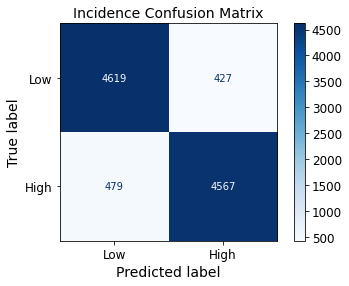

```python
### Incidence confusion matrix ###
from sklearn.metrics import confusion_matrix
from sklearn.metrics import ConfusionMatrixDisplay

# Confusion Matrix
cm = confusion_matrix(y_train_us_enc_shuf[:,0], y_train_pred_rf0)
#actual is rows; predicted is columns

# Plot
disp = ConfusionMatrixDisplay(confusion_matrix=cm, display_labels=['Low','High'])
disp.plot(cmap=plt.cm.Blues, values_format='d')

# Title of Plot
disp.ax_.set_title('Incidence Confusion Matrix', fontsize=14)

print(disp.confusion_matrix)   # displays cm
plt.show()     # displays colored plot of cm
```

The Random Forest classifier correctly classified 4,619 observations as low incidence, incorrectly classified 427 observations as high incidence, correctly classified 4,567 observations as high incidence, and incorrectly classified 479 observations as low incidence.

The normalized version of the confusion matrix above was also plotted as shown below by using `normalize='true'` which normalizes the confusion matrix over the true labels (rows). This normalization of the confusion matrix took into account the number of samples in each class. This is especially helpful for visualizing imbalanced data when interpreting the strength of the classifier on each class. The shade of coloring of the boxes remained the same in the plot below since since there was an equal number of low and high incidence observations in the training set.

```
[[0.91537852 0.08462148]
 [0.09492667 0.90507333]]
```

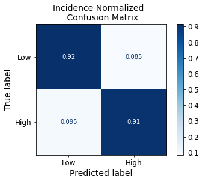

```python
#### Incidence normalized confusion matrix ###
from sklearn.metrics import confusion_matrix
from sklearn.metrics import ConfusionMatrixDisplay

# Normalized confusion Matrix
cm = confusion_matrix(y_train_us_enc_shuf[:,0], y_train_pred_rf0, normalize='true')

# Plot
disp = ConfusionMatrixDisplay(confusion_matrix=cm, display_labels=['Low', 'High'])
disp.plot(cmap=plt.cm.Blues)

# Title of Plot
disp.ax_.set_title("Incidence Normalized  \n Confusion Matrix", fontsize=14)

print(disp.confusion_matrix)   # displays cm
plt.show()     # displays colored plot of cm
```

From the above normalized confusion matrix, it is clear that the low and high incidence classes performed about the same. The low incidence class had a normalized value of 0.92 while the high incidence class had a value of about 0.91. The highest possible value is 1. A value of 1 would mean 100% of the samples whose true label is the one belonging to the row it's in, had a true label belonging to the row the value is in and a predicted label belonging the column the value is in. The values 0.91 and 0.92 are relatively close to 1, so the Random Forest classifier performed well on both classes and on the Incidence target as a whole.

The following code created and displayed the confusion matrix for the Categorical Case Count target as well as a colored plot of the confusion matrix based on the confusion matrix values.

```
[[6065  364   20    0]
 [ 305 1776  155    8]
 [  16  246  545  125]
 [   0   15  140  312]]
```

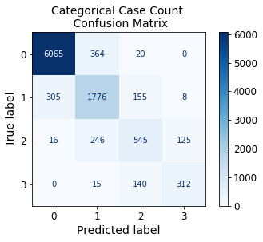

```python
### Categorical Case Count confusion matrix ###
from sklearn.metrics import confusion_matrix
from sklearn.metrics import ConfusionMatrixDisplay

# Confusion Matrix
cm = confusion_matrix(y_train_us_enc_shuf[:,1], y_train_pred_rf1)

# Plot
disp = ConfusionMatrixDisplay(confusion_matrix=cm, display_labels=[0,1,2,3])
disp.plot(cmap=plt.cm.Blues,values_format='d')

# Title of Plot
disp.ax_.set_title('Categorical Case Count \n Confusion Matrix', fontsize=14)

print(disp.confusion_matrix)   # displays cm
plt.show()     # displays colored plot of cm
```

The Random Forest classifier correctly classified 6,065 observations as class 0 case count, incorrectly classified 364 observations as class 1 when its true label was class 0, correctly classified 1,776 observations as class 1 case count, incorrectly classified 305 observations as class 0 case count when its true label was class 1, correctly classified 312 observations as class 3 case count, and incorrectly classified 140 observations as class 2 when its true label was class 3. Since the Categorical Case Count classes were imbalanced, it might not be as obvious how well the classifier did in comparison amongst the classes. The normalized confusion matrix more clearly shows the differences in class performance and if the most common majority class (class 0) really did outperform the least common minority class (class 3).

```
[[0.94045588 0.05644286 0.00310126 0.        ]
 [0.135918   0.79144385 0.06907308 0.00356506]
 [0.01716738 0.2639485  0.58476395 0.13412017]
 [0.         0.03211991 0.29978587 0.66809422]]
```

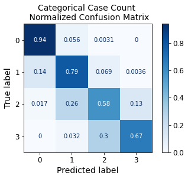

```python
#### Categorical Case Count normalized confusion matrix ###
from sklearn.metrics import confusion_matrix
from sklearn.metrics import ConfusionMatrixDisplay

# Normalized Confusion Matrix
cm = confusion_matrix(y_train_us_enc_shuf[:,1], y_train_pred_rf1, normalize='true')

# Plot
disp = ConfusionMatrixDisplay(confusion_matrix=cm, display_labels=[0,1,2,3])
disp.plot(cmap=plt.cm.Blues)

# Title of Plot
disp.ax_.set_title("Categorical Case Count \n Normalized Confusion Matrix", fontsize=14)

print(disp.confusion_matrix)   # displays cm
plt.show()     # displays colored plot of cm
```

### 4.2.5 Recall and Precision

Recall and precision consider true and false positives and negatives. In the equations shown below, a true positive is considered a sample that the classifier labeled as the specified positive class and its true label was indeed the specified positive class; a false positive is considered a sample that the classifier labeled as the specified positive class, but its true label was not the specified positive classl; a true negative is considered a sample that the classifier labeled as a class that was not the specified positive class and its true label was indeed not the specified positive class; a false negative is considered a sample that the classifier labeled as a class that was not the specified positive class, but its true label was the specified positive class.

Here are the equations for recall and precision:

$TP = \text{True positives}$

$FP = \text{False positives}$

$TN = \text{True negatives}$

$FN = \text{False negatives}$

$\text{Precision} = TP/(TP+FP)$

$\text{Recall} = TP/(TP+FN)$

Recall is the accuracy of the data for one class. For example, if tested the subset consisting of only the observations which had high incidence, recall for high incidence is same as the accuracy of that subset.

In example, a court judge might want high precision since innocent till proven guilty, while a lab test or car organization might want high recall to be better safe than sorry (catch all the positive cases for a disease or catch all the vehicles that fail to meet minimum safety standards).

```python
from sklearn.metrics import precision_score, recall_score

recall_score(y_train_us_enc_shuf[:,0], y_train_pred_rf0, average='macro')
```

```
0.9102259215219977
```

```python
precision_score(y_train_us_enc_shuf[:,0], y_train_pred_rf0, average='macro')
```

```
0.9102694909057601
```

```python
recall_score(y_train_us_enc_shuf[:,1], y_train_pred_rf1, average='micro')
```

```
0.8618707887435593
```

### 4.2.6 Classification Report

The classification report displays all the recall and precision scores as well as the f1-score and overall accuracy of the Random Forest classifier for each target variable.

```python
#### Incidence classification report ###
from sklearn.metrics import classification_report

print(classification_report(y_train_us_enc_shuf[:,0], y_train_pred_rf0))
```

```
              precision    recall  f1-score   support

         0.0       0.91      0.92      0.91      5046
         1.0       0.91      0.91      0.91      5046

    accuracy                           0.91     10092
   macro avg       0.91      0.91      0.91     10092
weighted avg       0.91      0.91      0.91     10092
```

```python
#### Categorical Case Count classification report ###
from sklearn.metrics import classification_report

print(classification_report(y_train_us_enc_shuf[:,1], y_train_pred_rf1))
```

```
              precision    recall  f1-score   support

         0.0       0.95      0.94      0.95      6449
         1.0       0.74      0.79      0.76      2244
         2.0       0.63      0.58      0.61       932
         3.0       0.70      0.67      0.68       467

    accuracy                           0.86     10092
   macro avg       0.76      0.75      0.75     10092
weighted avg       0.86      0.86      0.86     10092
```

The macro average recall value is the average of the recall scores: $$(0.94+0.79+0.58+0.67)/4=0.75.$$

The weighted average recall values takes the proportion of each label in the dataset into consideration: $$(0.94*6449+0.79*2244+0.58*932+0.67*467)/(6449+2244+932+467)=0.86.$$

```python
# recall values exampled above
print('Macro avg recall:', round((0.94+0.79+0.58+0.67)/4, 3))
print('Weighted avg recall:', round((0.94*6449+0.79*2244+0.58*932+0.67*467)/(6449+2244+932+467), 3))
```

```
Macro avg recall: 0.745
Weighted avg recall: 0.861
```

The classification results for the Random Forest classifier are really good for Incidence and not as good for Categorical Case Count.

### 4.2.7 Multioutput Accuracy

The output below shows the multioutput accuracy of the training data was 100% for the Random Forest classifier fit on the whole training set.

```python
print(multi_rf_clf.score(X_train_us_shuf, y_train_us_enc_shuf))
```

```
1.0
```

The multioutput accuracy of the training data shown above is an accuracy from a model fit on all the data it classified. A more accurate depiction of what the accuracy of the test data might look like would be taking the accuracy of the cross validated predictions. Since no metric in `sklearn.metrics` currently supports the multioutput-multiclass classification task, I combined the outputs from `y_train_pred_rf0` and `y_train_pred_rf1` together to get a multioutput accuracy from the cross-validated predictions.

The code and output below is for the two column dataframe of the predicted labels from the cross-validation of the training set for each target variable.

```python
y_train_pred_rf_df = pd.DataFrame({'0': y_train_pred_rf0, '1': y_train_pred_rf1})
print(y_train_pred_rf_df.shape) # 10092 samples, 2 columns
y_train_pred_rf_df.head()
```

```
(10092, 2)
```

|  | 0 | 1 |
| --- | --- | --- |
| 0 | 0.0 | 0.0 |
| 1 | 1.0 | 1.0 |
| 2 | 1.0 | 1.0 |
| 3 | 1.0 | 0.0 |
| 4 | 0.0 | 0.0 |

The function below combined the two outputs to form one output where each class in the output was a represention for the incidence and case count category outputs. More explicitly, labels that were low incidence and case count class 0 were given a label of 0; labels that were low incidence and case count class 1 were given a label of 1; labels that were low incidence and case count class 2 were given a label of 2; labels that were low incidence and case count class 3 were given a label of 3; labels that were high incidence and case count class 0 were given a label of 4; labels that were high incidence and case count class 1 were given a label of 5; labels that were high incidence and case count class 2 were given a label of 6; labels that were high incidence and case count class 3 were given a label of 7.

```python
def funcCombLabs(row):
    if row[0] == 0:
        if row[1] == 0:
          val = 0
        elif row[1] == 1:
          val = 1
        elif row[1] == 2:
          val = 2
        elif row[1] == 3:
          val = 3
    else:
        if row[1] == 0:
          val = 4
        elif row[1] == 1:
          val = 5
        elif row[1] == 2:
          val = 6
        elif row[1] == 3:
          val = 7
    return val

y_train_pred_rf_df['CombLabels'] = y_train_pred_rf_df.apply(funcCombLabs, axis=1)
np.ravel(y_train_pred_rf_df['CombLabels'])
```

```
array([0, 5, 5, ..., 0, 6, 0])
```

The third column, "CombLabels", in both the predicted and actual target datasets is the single output of the combined labels.

```python
y_train_true_df = pd.DataFrame(y_train_us_enc_shuf)
y_train_true_df['CombLabels'] = y_train_true_df.apply(funcCombLabs, axis=1)
```

The accuracy of the cross-validated predictions of the training set was approximately 78.91%. This means the Random Forest classifier classified both the incidence and categorical case count labels correctly for approximately 78.91% of the samples in the training set.

```python
from sklearn.metrics import accuracy_score

accuracy_score(y_train_true_df['CombLabels'], y_train_pred_rf_df['CombLabels'])
```

```
0.7891399128022196
```

### 4.2.8 Feauture Importances

The `MultiOutputClassifier` object has no attribute `feature_importances_` so I found the mean of the feature importances for each target variable.

```python
# Mean feauture importances
feature_importances = []
for clf in multi_target_rf.estimators_:
    feature_importances.append(clf.feature_importances_)

print("Mean Feature Importances:")
for score, name in sorted(zip(np.mean(feature_importances, axis=0), X_train.columns)):
    print(name, score)
```

```
Mean Feature Importances:
Minimum Temperature 0.06169167525416244
Precipitation 0.06552504154095098
Average Temperature 0.07584270333454067
Population Density 0.0785374114134787
Percent Forest Area 0.07927075105761741
Maximum Temperature 0.0966228356639664
Population 0.12406669428490817
CENTLAT 0.15087132685611682
CENTLON 0.2675715605942586
```

Latitude and longitude had the highest mean feature importances meaning their feature importances were either high for both target variables or extremely high for at least one target variable. While the mean feature importance for maximum temperature was higher than half of the other features' mean feature importances, the other climate data, minimum temperature, precipitation, and average temperature, had the lowest mean feature importances.

Below are the feature importances for each target variable independently.

```python
# Incidence feature importances
print("Incidence Feature Importances:")
for score, name in sorted(zip(feature_importances[0], X_train.columns)):
    print(name, score)
```

```
Incidence Feature Importances:
Population Density 0.046336332946899504
Minimum Temperature 0.05823334156210933
Population 0.06013148801184336
Precipitation 0.06560906014637403
Average Temperature 0.08508361153530365
Percent Forest Area 0.09161088361266559
Maximum Temperature 0.10920307594065588
CENTLAT 0.17258357103301633
CENTLON 0.31120863521113246
```

```python
# Categorical Case Count feature importances
print("Categorical Case Count Feature Importances:")
for score, name in sorted(zip(feature_importances[1], X_train.columns)):
    print(name, score)
```

```
Categorical Case Count Feature Importances:
Minimum Temperature 0.06515000894621555
Precipitation 0.06544102293552795
Average Temperature 0.06660179513377769
Percent Forest Area 0.06693061850256923
Maximum Temperature 0.08404259538727692
Population Density 0.1107384898800579
CENTLAT 0.12915908267921727
Population 0.18800190055797297
CENTLON 0.22393448597738466
```

As displayed above, both incidence and categorical case count had their highest feature importance belonging to longitude. Maximum temperature had a higher feature importance when labeling for incidence than it did when labeling for categorical case count. Population had a higer feature importance than latitude when labeling for categorical case count. Latitude and longitude had high importances for both targets with longitude having a slightly higher importance for incidence. The top four features based on feature importance for incidence were Percent Forest Area, Maximum Temperature, CENTLAT, and CENTLON (in that order). The top four features based on feature importance for categorical case count were Population Density, CENTLAT, Population, and CENTLON (in that order).

## 4.3 K-Nearest Neighbors

### 4.3.1 Description and Standardization

In the K-Nearest Neighbors (KNN) algorithm each training sample's feature data is made into a vector in a multidimensional space. During training, the algorithm stores the training samples feature vectors with their corresponding class labels. During classification, each test sample feature data are made into vectors and put into the multidimenional feature space where each test sample is classified based on the labels of the k closest training sample vectors.

When the weight function in Scikit-learn's KNN classifier is `uniform`, all sample points in each neighborhood are weighted equally so the test sample is classified by assigning the label that is most frequent among the k training samples nearest to that test point (nearest neighbors). When the weight function in Scikit-learn's KNN classifier is `distance`, the sample points or vectors are weighted by the inverse of their respective distance to the test point or vector. [33] With this, closer neighbors, or neighbors with a smaller distance, to the test point have a greater influence than the neighbors that are further away.

The distance between two points in the multidimensional feature space is the distance between two vectors and those two vectors each contain the feature data values of their own sample. Hence, if the range of values of one feature is much different than another feature, the distance calculations will be off. Thus, each feature data was standardized before being put into the KNN classifier.

To standardize each feature, I used `StandardScaler` which transformed the data such that the distribution for each feature had a mean value 0 and standard deviation of 1.

```python
from sklearn.preprocessing import StandardScaler

# Initialise the Scaler
scaler = StandardScaler()

# To scale data
scaler.fit(X_train_us_shuf)
```

```
StandardScaler(copy=True, with_mean=True, with_std=True)
```

```python
# Scale train feature data
X_train_us_shuf_scal = scaler.transform(X_train_us_shuf)
```

```python
# Scale test feature data
X_test_scal = scaler.transform(X_test)
```

### 4.3.2 Training K-Nearest Neighbors Classifier

I used the scaled training data to train the KNN classifier.

```python
from sklearn.multioutput import MultiOutputClassifier
from sklearn.neighbors import KNeighborsClassifier

knn = KNeighborsClassifier()
multi_target_knn = MultiOutputClassifier(knn, n_jobs=-1)
multi_knn_clf = multi_target_knn.fit(X_train_us_shuf_scal, y_train_us_enc_shuf)
```

Below displays the settings of the hyperparameters of the `multi_target_knn`. This includes the KNN estimator.

```python
multi_knn_clf.get_params()
```

```
{'estimator': KNeighborsClassifier(algorithm='auto', leaf_size=30, metric='minkowski',
                      metric_params=None, n_jobs=None, n_neighbors=5, p=2,
                      weights='uniform'),
 'estimator__algorithm': 'auto',
 'estimator__leaf_size': 30,
 'estimator__metric': 'minkowski',
 'estimator__metric_params': None,
 'estimator__n_jobs': None,
 'estimator__n_neighbors': 5,
 'estimator__p': 2,
 'estimator__weights': 'uniform',
 'n_jobs': -1}
```

As shown below, the settings of the hyperparameters of the KNN estimators are the same between both target variables' fitted models.

```python
multi_target_knn.estimators_
```

```
[KNeighborsClassifier(algorithm='auto', leaf_size=30, metric='minkowski',
                      metric_params=None, n_jobs=None, n_neighbors=5, p=2,
                      weights='uniform'),
 KNeighborsClassifier(algorithm='auto', leaf_size=30, metric='minkowski',
                      metric_params=None, n_jobs=None, n_neighbors=5, p=2,
                      weights='uniform')]
```

### 4.3.3 Cross-Validation

To evaluate the KNN model, I used Scikit-Learn’s K-fold cross-validation feature in the same manner as done with the Random Forest model.

```python
### Incidence cross validation scores ###
from sklearn.model_selection import cross_val_score

cross_val_score(multi_knn_clf.estimators_[0], X_train_us_shuf_scal, y_train_us_enc_shuf[:,0],
                cv=3, scoring="accuracy")
```

```
array([0.89298454, 0.89982164, 0.90041617])
```

All three folds yielded an accuracy above 89.0% and below 91.0% for the Incidence target.

```python
### Categorical Case Count cross validation scores ###
from sklearn.model_selection import cross_val_score

cross_val_score(multi_knn_clf.estimators_[1], X_train_us_shuf_scal, y_train_us_enc_shuf[:,1],
                cv=3, scoring="accuracy")
```

```
array([0.82401902, 0.81688466, 0.828478  ])
```

All three folds yielded an accuracy above 81.0% and below 83.0% for the Categorical Case Count target. The accuracy for the Incidence target was a little higher than Categorical Case Count's accuracy.

### 4.3.4 Confusion Matrix

Seperate confusion matrices were made for the Incidence target variable and Categorical Case Count target variable.

First the predictions made by the cross-validations were found and stored into `y_train_pred_knn0` and `y_train_pred_knn1` for the Incidence and Categorical Case Count targets, respectively.

```python
from sklearn.model_selection import cross_val_predict

### Incidence cross validation predictions ###
y_train_pred_knn0 = cross_val_predict(multi_target_knn.estimators_[0],
                                      X_train_us_shuf_scal, y_train_us_enc_shuf[:,0], cv=3)

### Categorical Case Count cross validation predictions ###
y_train_pred_knn1 = cross_val_predict(multi_target_knn.estimators_[1],
                                      X_train_us_shuf_scal, y_train_us_enc_shuf[:,1], cv=3)
```

The following code created and displayed the confusion matrix for the Incidence target as well as a colored plot of the confusion matrix based on the confusion matrix values.

```
[[4513  533]
 [ 499 4547]]
```

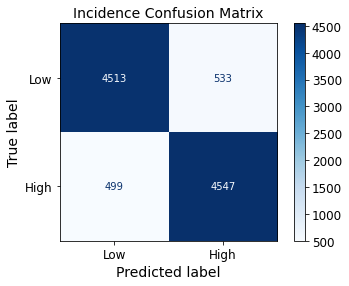

```python
### Incidence confusion matrix ###
from sklearn.metrics import confusion_matrix
from sklearn.metrics import ConfusionMatrixDisplay

# Confusion Matrix
cm = confusion_matrix(y_train_us_enc_shuf[:,0], y_train_pred_knn0)
#actual is rows; predicted is columns

# Plot
disp = ConfusionMatrixDisplay(confusion_matrix=cm, display_labels=['Low','High'])
disp.plot(cmap=plt.cm.Blues,values_format='d')

# Title of Plot
disp.ax_.set_title('Incidence Confusion Matrix', fontsize=14)

print(disp.confusion_matrix)   # displays cm
plt.show()     # displays colored plot of cm
```

The KNN classifier correctly classified 4,513 observations as low incidence, incorrectly classified 533 observations as high incidence, correctly classified 4,547 observations as high incidence, and incorrectly classified 499 observations as low incidence.

The normalized version of the confusion matrix above was also plotted as shown below by using `normalize='true'` which normalizes the confusion matrix over the true labels (rows). The shade of coloring of the boxes remained the same in the plot below since since there was an equal number of low and high incidence observations in the training set.

```
[[0.89437178 0.10562822]
 [0.09889021 0.90110979]]
```

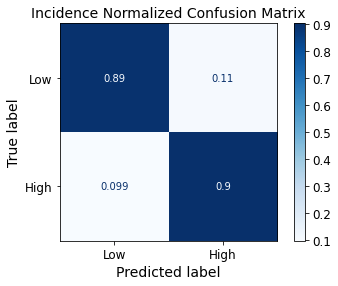

```python
### Incidence normalized confusion matrix ###
from sklearn.metrics import confusion_matrix
from sklearn.metrics import ConfusionMatrixDisplay

# Normalized Confusion Matrix
cm = confusion_matrix(y_train_us_enc_shuf[:,0], y_train_pred_knn0, normalize='true')
#actual is rows; predicted is columns

# Plot
disp = ConfusionMatrixDisplay(confusion_matrix=cm, display_labels=['Low','High'])
disp.plot(cmap=plt.cm.Blues)

# Title of Plot
disp.ax_.set_title('Incidence Normalized Confusion Matrix', fontsize=14)

print(disp.confusion_matrix)   # displays cm
plt.show()     # displays colored plot of cm
```

From the above normalized confusion matrix, it is clear that the low and high incidence classes performed about the same. The low incidence class had a normalized value of 0.89 while the high incidence class had a value of about 0.9. The values 0.89 and 0.9 are relatively close to 1, so the KNN classifier performed well on both classes and on the Incidence target as a whole.

The following code created and displayed the confusion matrix for the Categorical Case Count target as well as a colored plot of the confusion matrix based on the confusion matrix values.

```
[[5966  449   23   11]
 [ 471 1601  156   16]
 [  29  330  459  114]
 [   2   48  136  281]]
```

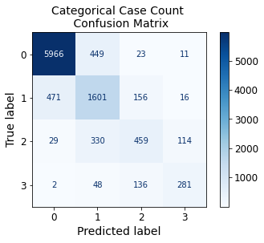

```python
### Categorical Case Count confusion matrix ###
from sklearn.metrics import confusion_matrix
from sklearn.metrics import ConfusionMatrixDisplay

# Confusion Matrix
cm = confusion_matrix(y_train_us_enc_shuf[:,1], y_train_pred_knn1)
#actual is rows; predicted is columns

# Plot
disp = ConfusionMatrixDisplay(confusion_matrix=cm, display_labels=[0,1,2,3])
disp.plot(cmap=plt.cm.Blues,values_format='d')

# Title of Plot
disp.ax_.set_title('Categorical Case Count \n Confusion Matrix', fontsize=14)

print(disp.confusion_matrix)   # displays cm
plt.show()     # displays colored plot of cm
```

Since the Categorical Case Count classes were imbalanced, it might not be as obvious how well the classifier did in comparison amongst the classes. The normalized confusion matrix more clearly shows the differences in class performance and if the most common majority class (class 0) really did outperform the least common minority class (class 3).

```
[[0.92510467 0.0696232  0.00356644 0.00170569]
 [0.20989305 0.71345811 0.06951872 0.00713012]
 [0.03111588 0.35407725 0.49248927 0.1223176 ]
 [0.00428266 0.10278373 0.29122056 0.60171306]]
```

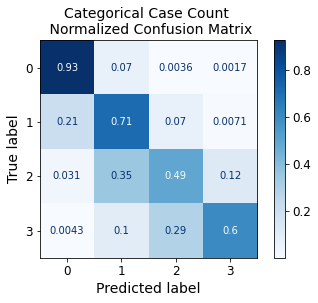

```python
### Categorical Case Count normalized confusion matrix ###
from sklearn.metrics import ConfusionMatrixDisplay

# Normalized Confusion Matrix
cm = confusion_matrix(y_train_us_enc_shuf[:,1], y_train_pred_knn1, normalize='true')
#actual is rows; predicted is columns

# Plot
disp = ConfusionMatrixDisplay(confusion_matrix=cm, display_labels=[0,1,2,3])
disp.plot(cmap=plt.cm.Blues)

# Title of Plot
disp.ax_.set_title("Categorical Case Count \n Normalized Confusion Matrix", fontsize=14)

print(disp.confusion_matrix)   # displays cm
plt.show()     # displays colored plot of cm
```

### 4.3.5 Classification Report

The classification report displays all the recall and precision scores as well as the f1-score and overall accuracy of the KNN classifier for each target variable.

```python
#### Incidence classification report ###
from sklearn.metrics import classification_report

print(classification_report(y_train_us_enc_shuf[:,0], y_train_pred_knn0))
```

```
              precision    recall  f1-score   support

         0.0       0.90      0.89      0.90      5046
         1.0       0.90      0.90      0.90      5046

    accuracy                           0.90     10092
   macro avg       0.90      0.90      0.90     10092
weighted avg       0.90      0.90      0.90     10092
```

```python
#### Categorical Case Count classification report ###
from sklearn.metrics import classification_report

print(classification_report(y_train_us_enc_shuf[:,1], y_train_pred_knn1))
```

```
              precision    recall  f1-score   support

         0.0       0.92      0.93      0.92      6449
         1.0       0.66      0.71      0.69      2244
         2.0       0.59      0.49      0.54       932
         3.0       0.67      0.60      0.63       467

    accuracy                           0.82     10092
   macro avg       0.71      0.68      0.69     10092
weighted avg       0.82      0.82      0.82     10092
```

The classification results for the KNN classifier are really good for Incidence and not as good for Categorical Case Count.

### 4.3.6 Multioutput Accuracy

I combined the outputs from `y_train_pred_knn0` and `y_train_pred_knn1` together to get a multioutput accuracy from the cross-validated predictions.

The code and output below is for the two column dataframe of the predicted labels from the cross-validation of the training set for each target variable.

```python
y_train_pred_knn_df = pd.DataFrame({'0': y_train_pred_knn0, '1': y_train_pred_knn1})
print(y_train_pred_knn_df.shape)
y_train_pred_knn_df.head()
```

```
(10092, 2)
```

|  | 0 | 1 |
| --- | --- | --- |
| 0 | 0.0 | 0.0 |
| 1 | 1.0 | 1.0 |
| 2 | 1.0 | 1.0 |
| 3 | 1.0 | 0.0 |
| 4 | 0.0 | 0.0 |

The following code applied the function from section 2 of Chapter 4 (4.2.7) to `y_train_pred_knn_df` and `y_train_true_df` so that the two outputs would be combined to form one output where each class in the output was a represention for the incidence and case count category outputs.

```python
y_train_pred_knn_df['CombLabels'] = y_train_pred_knn_df.apply(funcCombLabs, axis=1)
np.ravel(y_train_pred_knn_df['CombLabels'])
```

```
array([0, 5, 5, ..., 0, 6, 0])
```

```python
y_train_true_df = pd.DataFrame(y_train_us_enc_shuf)
y_train_true_df['CombLabels'] = y_train_true_df.apply(funcCombLabs, axis=1)
```

The accuracy of the cross-validated predictions of the training set was approximately 74.15%. This means the KNN classifier classified both the incidence and categorical case count labels correctly for approximately 74.15% of the samples in the training set.

```python
from sklearn.metrics import accuracy_score

accuracy_score(y_train_true_df['CombLabels'], y_train_pred_knn_df['CombLabels'])
```

```
0.7414783987316687
```

## 4.4 Hyperparameter Optimization

The hyperparameters of the Random Forest and K-Nearest Neighbors classifiers were optimized.

### 4.4.1 Random Forest Fine-Tuning

The Random Forest classifier's hyperparameters were fine-tuned using a cross-validated grid-search over a parameter grid.

These are the hyperparameters that can be tuned for the Random Forest classifier:

```python
forest.get_params().keys()
```

```
dict_keys(['bootstrap', 'ccp_alpha', 'class_weight', 'criterion', 'max_depth', 'max_features', 'max_leaf_nodes', 'max_samples', 'min_impurity_decrease', 'min_impurity_split', 'min_samples_leaf', 'min_samples_split', 'min_weight_fraction_leaf', 'n_estimators', 'n_jobs', 'oob_score', 'random_state', '…
```

Since the `MultiOutputClassifier` was used as an extension to the Random Forest classifier, I needed the hyperparameters for that classifier which in this case took Random Forest hyperparameters as displayed below.

```python
multi_target_rf.get_params().keys()
```

```
dict_keys(['estimator__bootstrap', 'estimator__ccp_alpha', 'estimator__class_weight', 'estimator__criterion', 'estimator__max_depth', 'estimator__max_features', 'estimator__max_leaf_nodes', 'estimator__max_samples', 'estimator__min_impurity_decrease', 'estimator__min_impurity_split', 'estimator__min…
```

I used Scikit-learn's `GridSearchCV` to fine-tune the Random Forest hyperparameters. The code below tested all the combinations of the hyperparameters given using 5-fold cross-validation in order to find the combination of hyperparameters whose Random Forest estimator yields the best score which was set to accuracy.

```python
from sklearn.model_selection import GridSearchCV
from sklearn.multioutput import MultiOutputClassifier
from sklearn.ensemble import RandomForestClassifier

param_grid = [
    {'estimator__n_estimators': [3, 10, 30, 100], 'estimator__max_features': [3, 6, 9]},
    {'estimator__bootstrap': [True], 'estimator__n_estimators': [3, 10],
     'estimator__max_features': [3, 6, 9]},
  ]

forest_gs = RandomForestClassifier(random_state=42)
multi_target_rf_gs = MultiOutputClassifier(forest_gs, n_jobs=-1)

grid_search_rf = GridSearchCV(estimator=multi_target_rf_gs, param_grid=param_grid,
                              cv=5, verbose=3)
grid_search_rf.fit(X_train_us_shuf, y_train_us_enc_shuf)
```

```
Fitting 5 folds for each of 18 candidates, totalling 90 fits
[CV] estimator__max_features=3, estimator__n_estimators=3 ............
[CV]  estimator__max_features=3, estimator__n_estimators=3, score=0.738, total=   0.1s
[CV] estimator__max_features=3, estimator__n_estimators=3 ............
```

```
[Parallel(n_jobs=1)]: Using backend SequentialBackend with 1 concurrent workers.
[Parallel(n_jobs=1)]: Done   1 out of   1 | elapsed:    0.1s remaining:    0.0s
```

```
[CV]  estimator__max_features=3, estimator__n_estimators=3, score=0.749, total=   0.1s
[CV] estimator__max_features=3, estimator__n_estimators=3 ............
[CV]  estimator__max_features=3, estimator__n_estimators=3, score=0.754, total=   0.1s
[CV] estimator__max_features=3, estimator__n_estimators=3 ............
```

```
[Parallel(n_jobs=1)]: Done   2 out of   2 | elapsed:    0.2s remaining:    0.0s
```

[output not shown]

[output cut: 118 more lines]

[output not shown]

```
[Parallel(n_jobs=1)]: Done  90 out of  90 | elapsed:  1.8min finished
```

```
GridSearchCV(cv=5, error_score=nan,
             estimator=MultiOutputClassifier(estimator=RandomForestClassifier(bootstrap=True,
                                                                              ccp_alpha=0.0,
                                                                              class_weight=None,
                                                                              criterion='gini',
                                                                              max_depth=None,
                                                                              max_features='auto',
                                                                              max_leaf_nodes=None,
                                                                              max_samples=None,
                                                                              min_impurity_decrease=0.0,
                                                                              min_impurity_split=None,
                                                                              min_samples_leaf=1,
                                                                              min_samples_split=2,
                                                                              min_weight_fraction_leaf=0...
                                                                              random_state=42,
                                                                              verbose=0,
                                                                              warm_start=False),
                                             n_jobs=-1),
             iid='deprecated', n_jobs=None,
             param_grid=[{'estimator__max_features': [3, 6, 9],
                          'estimator__n_estimators': [3, 10, 30, 100]},
                         {'estimator__bootstrap': [True],
                          'estimator__max_features': [3, 6, 9],
                          'estimator__n_estimators': [3, 10]}],
             pre_dispatch='2*n_jobs', refit=True, return_train_score=False,
             scoring=None, verbose=3)
```

The `GridSearchCV` attribute `best_estimator_` outputs the estimator which yielded the highest score (or smallest loss if specified) on the left out data. The score was set to accuracy so the estimator that yielded the highest accuracy on a fold was chosen by the grid-search as the best estimator.

```python
grid_search_rf.best_estimator_
```

```
MultiOutputClassifier(estimator=RandomForestClassifier(bootstrap=True,
                                                       ccp_alpha=0.0,
                                                       class_weight=None,
                                                       criterion='gini',
                                                       max_depth=None,
                                                       max_features=6,
                                                       max_leaf_nodes=None,
                                                       max_samples=None,
                                                       min_impurity_decrease=0.0,
                                                       min_impurity_split=None,
                                                       min_samples_leaf=1,
                                                       min_samples_split=2,
                                                       min_weight_fraction_leaf=0.0,
                                                       n_estimators=100,
                                                       n_jobs=None,
                                                       oob_score=False,
                                                       random_state=42,
                                                       verbose=0,
                                                       warm_start=False),
                      n_jobs=-1)
```

The `GridSearchCV` attribute `best_score_` outputs the mean cross-validated score of the `best_estimator_`. The mean accuracy of the chosen estimator on the five folds was approximately 0.7943. The best estimator approximately got on average between the cross-validated folds made from the entire training set 79.43% of both the Incidence and Categorical Case Count labels correct.

```python
grid_search_rf.best_score_
```

```
0.7942944406728744
```

The hyperparameter settings that gave the best accuracy on the hold out data were a maximum of 6 features considered at each split within the random forest's decision trees and a number of 100 estimators (decision trees) in the Random Forest estimator.

```python
grid_search_rf.best_params_
```

```
{'estimator__max_features': 6, 'estimator__n_estimators': 100}
```

#### 4.4.1.1 Multioutput Accuracy

The following code found the accuracy of the grid-searched Random Forest classifier's predictions from 3-fold cross-validations of the training set.

```python
y_train_pred_rf_gs0 = cross_val_predict(grid_search_rf.best_estimator_.estimators_[0],
                                         X_train_us_shuf_scal, y_train_us_enc_shuf[:,0], cv=3)
y_train_pred_rf_gs1 = cross_val_predict(grid_search_rf.best_estimator_.estimators_[1],
                                         X_train_us_shuf_scal, y_train_us_enc_shuf[:,1], cv=3)

y_train_pred_rf_gs_df = pd.DataFrame({'0': y_train_pred_rf_gs0, '1': y_train_pred_rf_gs1})
y_train_pred_rf_gs_df['CombLabels'] = y_train_pred_rf_gs_df.apply(funcCombLabs, axis=1)
accuracy_score(y_train_true_df['CombLabels'], y_train_pred_rf_gs_df['CombLabels'])
```

```
0.7913198573127229
```

The accuracy score of the cross-validated predictions of the entire training set was approximately 0.7913. This means the grid-searched Random Forest classifier classified both the incidence and categorical case count labels correctly for approximately 79.13% of the samples in the training set.

#### 4.4.1.2 Classification Report

```python
#### Incidence classification report ###
from sklearn.metrics import classification_report

print(classification_report(y_train_us_enc_shuf[:,0], y_train_pred_rf_gs0))
```

```
              precision    recall  f1-score   support

         0.0       0.90      0.92      0.91      5046
         1.0       0.92      0.90      0.91      5046

    accuracy                           0.91     10092
   macro avg       0.91      0.91      0.91     10092
weighted avg       0.91      0.91      0.91     10092
```

```python
#### Categorical Case Count classification report ###
from sklearn.metrics import classification_report

print(classification_report(y_train_us_enc_shuf[:,1], y_train_pred_rf_gs1))
```

```
              precision    recall  f1-score   support

         0.0       0.95      0.94      0.95      6449
         1.0       0.75      0.79      0.77      2244
         2.0       0.63      0.59      0.61       932
         3.0       0.70      0.67      0.68       467

    accuracy                           0.86     10092
   macro avg       0.76      0.75      0.75     10092
weighted avg       0.86      0.86      0.86     10092
```

#### 4.4.1.3 Tree Visualization

The decision trees of the Random Forest estimator for the Incidence target variable are displayed below.

```python
gs_rf_clf0 = grid_search_rf.best_estimator_.estimators_[0]
gs_rf_clf0.estimators_
```

[output not shown]

[output cut: 545 more lines]

[output not shown]

There are 100 decision trees in the Random Forest estimator for Incidence.

```python
print(gs_rf_clf0.n_estimators) #There are 100 estimators or 100 decision trees
```

```
100
```

Shown below is the first tree in the random forest whose target is Incidence.

```python
gs_rf_clf0.estimators_[0] #first tree or estimator
```

```
DecisionTreeClassifier(ccp_alpha=0.0, class_weight=None, criterion='gini',
                       max_depth=None, max_features=6, max_leaf_nodes=None,
                       min_impurity_decrease=0.0, min_impurity_split=None,
                       min_samples_leaf=1, min_samples_split=2,
                       min_weight_fraction_leaf=0.0, presort='deprecated',
                       random_state=1608637542, splitter='best')
```

The visualization below is the top of the first tree of the Random Forest classifier fitted for Incidence.

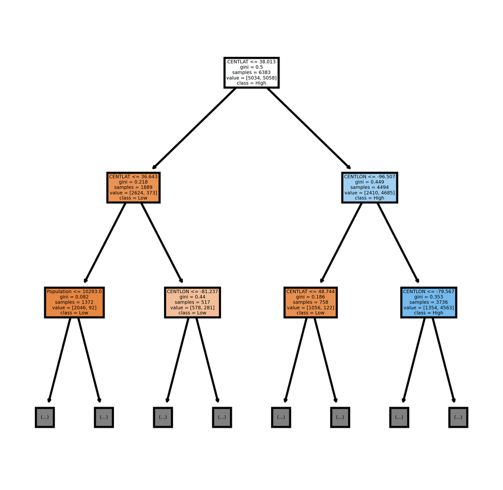

```python
#Visualize the top of the first tree of the Random Forest classifier
from sklearn import tree

fn = X_train.columns[:-1]   #feature names
cn = oe.categories_[0]      #Incidence target classes ['Low', 'High']
fig, axes = plt.subplots(nrows=1, ncols=1, figsize=(4,4), dpi=800)
tree.plot_tree(gs_rf_clf0.estimators_[0],
               feature_names=fn,
               class_names=cn,
               filled=True,
               max_depth=2);
#fig.savefig('rf_individualtree.png')
```

### 4.4.2 K-Nearest Neighbors Fine-Tuning

The K-Nearest Neighbors (KNN) classifier's hyperparameters were fine-tuned using a cross-validated grid-search over a parameter grid.

```python
from sklearn.preprocessing import StandardScaler

# Initialise the Scaler
scaler = StandardScaler()

# To scale data
scaler.fit(X_train_us_shuf)

X_train_us_shuf_scal = scaler.transform(X_train_us_shuf)
X_test_scal = scaler.transform(X_test)
```

These are the hyperparameters that can be fine-tuned for the KNN classifier:

```python
knn.get_params().keys()
```

```
dict_keys(['algorithm', 'leaf_size', 'metric', 'metric_params', 'n_jobs', 'n_neighbors', 'p', 'weights'])
```

Since the `MultiOutputClassifier` was used as an extension to the KNN classifier, I needed the hyperparameters for that classifier which in this case took KNN hyperparameters as displayed below.

```python
multi_target_knn.get_params().keys()
```

```
dict_keys(['estimator__algorithm', 'estimator__leaf_size', 'estimator__metric', 'estimator__metric_params', 'estimator__n_jobs', 'estimator__n_neighbors', 'estimator__p', 'estimator__weights', 'estimator', 'n_jobs'])
```

I used Scikit-learn's `GridSearchCV` to fine-tune the KNN hyperparameters. The code below tested all the combinations of the hyperparameters given using 5-fold cross-validation in order to find the combination of hyperparameters whose KNN estimator yields the best score which was set to accuracy.

```python
from sklearn.model_selection import GridSearchCV
from sklearn.multioutput import MultiOutputClassifier
from sklearn.neighbors import KNeighborsClassifier

knn_gs = KNeighborsClassifier()
multi_target_knn_gs = MultiOutputClassifier(knn_gs, n_jobs=-1)

param_grid = [
              {'estimator__n_neighbors': [3, 5, 7, 9, 11], # odd numbers for voting
               'estimator__weights': ['uniform','distance']}
              ]

grid_search_knn = GridSearchCV(estimator=multi_target_knn_gs, param_grid=param_grid,
                               cv=5, verbose=3)
grid_search_knn.fit(X_train_us_shuf_scal, y_train_us_enc_shuf)
```

```
Fitting 5 folds for each of 10 candidates, totalling 50 fits
[CV] estimator__n_neighbors=3, estimator__weights=uniform ............
```

```
[Parallel(n_jobs=1)]: Using backend SequentialBackend with 1 concurrent workers.
```

```
[CV]  estimator__n_neighbors=3, estimator__weights=uniform, score=0.733, total=   0.2s
[CV] estimator__n_neighbors=3, estimator__weights=uniform ............
[CV]  estimator__n_neighbors=3, estimator__weights=uniform, score=0.733, total=   0.2s
[CV] estimator__n_neighbors=3, estimator__weights=uniform ............
```

```
[Parallel(n_jobs=1)]: Done   1 out of   1 | elapsed:    0.2s remaining:    0.0s
[Parallel(n_jobs=1)]: Done   2 out of   2 | elapsed:    0.4s remaining:    0.0s
```

[output not shown]

[output cut: 40 more lines]

[output not shown]

```
[Parallel(n_jobs=1)]: Done  50 out of  50 | elapsed:    8.3s finished
```

```
GridSearchCV(cv=5, error_score=nan,
             estimator=MultiOutputClassifier(estimator=KNeighborsClassifier(algorithm='auto',
                                                                            leaf_size=30,
                                                                            metric='minkowski',
                                                                            metric_params=None,
                                                                            n_jobs=None,
                                                                            n_neighbors=5,
                                                                            p=2,
                                                                            weights='uniform'),
                                             n_jobs=-1),
             iid='deprecated', n_jobs=None,
             param_grid=[{'estimator__n_neighbors': [3, 5, 7, 9, 11],
                          'estimator__weights': ['uniform', 'distance']}],
             pre_dispatch='2*n_jobs', refit=True, return_train_score=False,
             scoring=None, verbose=3)
```

The `GridSearchCV` attribute `best_estimator_` outputs the estimator which yielded the highest score (or smallest loss if specified) on the left out data. The score was set to accuracy so the KNN estimator that yielded the highest accuracy on a fold was chosen by the grid-search as the best estimator.

```python
grid_search_knn.best_estimator_
```

```
MultiOutputClassifier(estimator=KNeighborsClassifier(algorithm='auto',
                                                     leaf_size=30,
                                                     metric='minkowski',
                                                     metric_params=None,
                                                     n_jobs=None, n_neighbors=9,
                                                     p=2, weights='distance'),
                      n_jobs=-1)
```

The `GridSearchCV` attribute `best_score_` outputs the mean cross-validated score of the `best_estimator_`. The mean accuracy of the chosen estimator on the five folds was approximately 0.7557. The best estimator approximately got on average between the cross-validated folds made from the entire training set 75.57% of both the Incidence and Categorical Case Count labels correct.

```python
grid_search_knn.best_score_
```

```
0.7557483883287166
```

The hyperparameter settings that gave the best accuracy on the hold out data were a number of 9 nearest neighbors and the weight function set to 'distance' for the KNN estimator.

```python
grid_search_knn.best_params_
```

```
{'estimator__n_neighbors': 9, 'estimator__weights': 'distance'}
```

#### 4.4.2.1 Multioutput Accuracy

The following code found the accuracy of the grid-searched KNN classifier's predictions from 3-fold cross-validations of the training set.

```python
y_train_pred_knn_gs0 = cross_val_predict(grid_search_knn.best_estimator_.estimators_[0],
                                         X_train_us_shuf_scal, y_train_us_enc_shuf[:,0], cv=3)
y_train_pred_knn_gs1 = cross_val_predict(grid_search_knn.best_estimator_.estimators_[1],
                                         X_train_us_shuf_scal, y_train_us_enc_shuf[:,1], cv=3)

y_train_pred_knn_gs_df = pd.DataFrame({'0': y_train_pred_knn_gs0, '1': y_train_pred_knn_gs1})
y_train_pred_knn_gs_df['CombLabels'] = y_train_pred_knn_gs_df.apply(funcCombLabs, axis=1)
accuracy_score(y_train_true_df['CombLabels'], y_train_pred_knn_gs_df['CombLabels'])
```

```
0.7512881490289338
```

The accuracy of the cross-validated predictions of the entire training set was approximately 75.13%. This means the grid-searched KNN classifier classified both the incidence and categorical case count labels correctly for approximately 75.13% of the samples in the training set.

## 4.5 Ensemble

### 4.5.1 Voting Classifier

The ensemble method used was a soft voting classification. Soft voting classification involves the prediction of the class labels based on the argument of the maximum of the sums of the predicted probabilities. In this case, the probabilites were from the Random Forest classifier and K-Nearest Neighbors classifier from the grid-searches. For random forests, "the predicted class probabilities of an input sample are computed as the mean predicted class probabilities of the trees in the forest. The class probability of a single tree is the fraction of samples of the same class in a leaf." https://scikit-learn.org/stable/modules/generated/sklearn.ensemble.RandomForestClassifier.html#sklearn.ensemble.RandomForestClassifier.predict_proba . For KNN, the probability estimates of each class are based on the proportion of labels among nearest neighbors and the nearest neighbors distance to the test point when `weights='distance'`.

#### 4.5.1.1 Fitting Voting Classifier

The following code sets up and fits the Soft Voting classifier for both target variables. The input of the Soft Voting classifier is the unscaled data. The Random Forest classifier found in the grid-search takes the unscaled data as input while the KNN classifier is put into a pipeline where the data is first scaled then given to the KNN estimator as input.

```python
from sklearn.ensemble import VotingClassifier
from sklearn.pipeline import make_pipeline

scale_knn0 = make_pipeline(StandardScaler(), grid_search_knn.best_estimator_.estimators_[0])
rf_clf0 = grid_search_rf.best_estimator_.estimators_[0]

voting_clf0 = VotingClassifier(
    estimators=[('rf', rf_clf0),
                ('knn', scale_knn0)],
    voting='soft')

v0 = voting_clf0.fit(X_train_us_shuf, y_train_us_enc_shuf[:,0])
```

```python
from sklearn.ensemble import VotingClassifier

scale_knn1 = make_pipeline(StandardScaler(), grid_search_knn.best_estimator_.estimators_[1])
rf_clf1 = grid_search_rf.best_estimator_.estimators_[1]

voting_clf1 = VotingClassifier(
    estimators=[('rf', rf_clf1),
                ('knn', scale_knn1)],
    voting='soft')

v1 = voting_clf1.fit(X_train_us_shuf, y_train_us_enc_shuf[:,1])
```

#### 4.5.1.2 Cross-Validation

To evaluate the Soft Voting classifier, I used Scikit-Learn’s K-fold cross-validation feature in the same manner as done with the Random Forest and KNN models.

```python
### Incidence cross validation scores ###
from sklearn.model_selection import cross_val_score

cross_val_score(voting_clf0, X_train_us_shuf, y_train_us_enc_shuf[:,0],
                cv=3, scoring="accuracy")
```

```
array([0.90249703, 0.91557669, 0.91141498])
```

All three folds yielded an accuracy above 90.0% and below 92.0% for the Incidence target.

```python
### Categorical Case Count cross validation scores ###
from sklearn.model_selection import cross_val_score

cross_val_score(voting_clf1, X_train_us_shuf, y_train_us_enc_shuf[:,1],
                cv=3, scoring="accuracy")
```

```
array([0.85879905, 0.8608799 , 0.86593341])
```

All three folds yielded an accuracy above 85.0% and below 87.0% for the Categorical Case Count target. The accuracy for the Incidence target was a little higher than Categorical Case Count's accuracy.

#### 4.5.1.3 Confusion Matrix

Seperate confusion matrices were made for the Incidence target variable and Categorical Case Count target variable.

First the predictions made by the cross-validations were found and stored into `y_train_pred_ens0` and `y_train_pred_ens1` for the Incidence and Categorical Case Count targets, respectively.

```python
from sklearn.model_selection import cross_val_predict

### Incidence cross-validation predictions ###
y_train_pred_ens0 = cross_val_predict(voting_clf0, X_train_us_shuf,
                                      y_train_us_enc_shuf[:,0], cv=3)

#### Categorical Case Count cross-validation predictions ###
y_train_pred_ens1 = cross_val_predict(voting_clf1, X_train_us_shuf,
                                      y_train_us_enc_shuf[:,1], cv=3)
```

The following code created and displayed the confusion matrix for the Incidence target as well as a colored plot of the confusion matrix based on the confusion matrix values.

```
[[4607  439]
 [ 471 4575]]
```

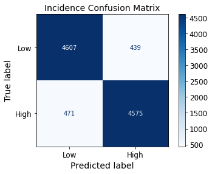

```python
### Incidence confusion matrix ###
from sklearn.metrics import ConfusionMatrixDisplay

# Confusion Matrix
cm = confusion_matrix(y_train_us_enc_shuf[:,0], y_train_pred_ens0)

# Plot
disp = ConfusionMatrixDisplay(confusion_matrix=cm, display_labels=['Low','High'])
disp.plot(cmap=plt.cm.Blues, values_format='d')

# Title of Plot
disp.ax_.set_title('Incidence Confusion Matrix', fontsize=14)

print(disp.confusion_matrix)   # displays cm
plt.show()     # displays colored plot of cm
```

```
[[0.9130004  0.0869996 ]
 [0.09334126 0.90665874]]
```

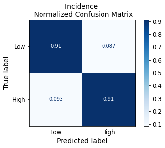

```python
#### Incidence normalized confusion matrix ###
from sklearn.metrics import ConfusionMatrixDisplay

# Normalized Confusion Matrix
cm = confusion_matrix(y_train_us_enc_shuf[:,0], y_train_pred_ens0, normalize='true')

# Plot
disp = ConfusionMatrixDisplay(confusion_matrix=cm, display_labels=['Low', 'High'])
disp.plot(cmap=plt.cm.Blues)

# Title of Plot
disp.ax_.set_title("Incidence \n Normalized Confusion Matrix", fontsize=14)

print(disp.confusion_matrix)   # displays cm
plt.show()     # displays colored plot of cm
```

```
[[6047  379   20    3]
 [ 306 1796  133    9]
 [   6  270  540  116]
 [   0   22  130  315]]
```

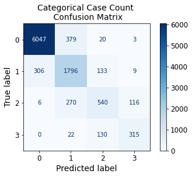

```python
### Categorical Case Count confusion matrix ###
from sklearn.metrics import ConfusionMatrixDisplay

# Confusion Matrix
cm = confusion_matrix(y_train_us_enc_shuf[:,1], y_train_pred_ens1)

# Plot
disp = ConfusionMatrixDisplay(confusion_matrix=cm, display_labels=[0,1,2,3])
disp.plot(cmap=plt.cm.Blues, values_format='d')

# Title of Plot
disp.ax_.set_title('Categorical Case Count \n Confusion Matrix', fontsize=14)

print(disp.confusion_matrix)   # displays cm
plt.show()     # displays colored plot of cm
```

```
[[9.37664754e-01 5.87688014e-02 3.10125601e-03 4.65188401e-04]
 [1.36363636e-01 8.00356506e-01 5.92691622e-02 4.01069519e-03]
 [6.43776824e-03 2.89699571e-01 5.79399142e-01 1.24463519e-01]
 [0.00000000e+00 4.71092077e-02 2.78372591e-01 6.74518201e-01]]
```

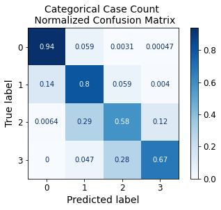

```python
#### Categorical Case Count normalized confusion matrix ###
from sklearn.metrics import ConfusionMatrixDisplay

# Normalized Confusion Matrix
cm = confusion_matrix(y_train_us_enc_shuf[:,1], y_train_pred_ens1, normalize='true')

# Plot
disp = ConfusionMatrixDisplay(confusion_matrix=cm, display_labels=[0,1,2,3])
disp.plot(cmap=plt.cm.Blues)

# Title of Plot
disp.ax_.set_title("Categorical Case Count \n Normalized Confusion Matrix", fontsize=14)

print(disp.confusion_matrix)   # displays cm
plt.show()     # displays colored plot of cm
```

#### 4.5.1.4 Classification Report

```python
#### Incidence classification report ###
from sklearn.metrics import classification_report

print(classification_report(y_train_us_enc_shuf[:,0], y_train_pred_ens0))
```

```
              precision    recall  f1-score   support

         0.0       0.91      0.91      0.91      5046
         1.0       0.91      0.91      0.91      5046

    accuracy                           0.91     10092
   macro avg       0.91      0.91      0.91     10092
weighted avg       0.91      0.91      0.91     10092
```

```python
#### Categorical Case Count classification report ###
from sklearn.metrics import classification_report

print(classification_report(y_train_us_enc_shuf[:,1], y_train_pred_ens1))
```

```
              precision    recall  f1-score   support

         0.0       0.95      0.94      0.94      6449
         1.0       0.73      0.80      0.76      2244
         2.0       0.66      0.58      0.62       932
         3.0       0.71      0.67      0.69       467

    accuracy                           0.86     10092
   macro avg       0.76      0.75      0.75     10092
weighted avg       0.86      0.86      0.86     10092
```

#### 4.5.1.5 Multioutput Accuracy

```python
y_train_pred_ens_df = pd.DataFrame({'0': y_train_pred_ens0, '1': y_train_pred_ens1})
```

```python
y_train_pred_ens_df['CombLabels'] = y_train_pred_ens_df.apply(funcCombLabs, axis=1)
```

```python
y_train_true_df = pd.DataFrame(y_train_us_enc_shuf)
y_train_true_df['CombLabels'] = y_train_true_df.apply(funcCombLabs, axis=1)
```

```python
from sklearn.metrics import accuracy_score

accuracy_score(y_train_true_df['CombLabels'], y_train_pred_ens_df['CombLabels'])
```

```
0.7887435592548553
```

## 4.6 Comparison of Classifiers

```python
from sklearn.metrics import accuracy_score

print("Random Forest Classifier Multioutput Accuracy:",
      accuracy_score(y_train_true_df['CombLabels'], y_train_pred_rf_df['CombLabels']))
print("KNN Classifier Multioutput Accuracy:",
      accuracy_score(y_train_true_df['CombLabels'], y_train_pred_knn_df['CombLabels']))
print("Grid-Searched Random Forest Classifier Multioutput Accuracy:",
      accuracy_score(y_train_true_df['CombLabels'], y_train_pred_rf_gs_df['CombLabels']))
print("Grid-Searched KNN Classifier Multioutput Accuracy:",
      accuracy_score(y_train_true_df['CombLabels'], y_train_pred_knn_gs_df['CombLabels']))
print("Soft Voting Classifier Multioutput Accuracy:",
      accuracy_score(y_train_true_df['CombLabels'], y_train_pred_ens_df['CombLabels']))
```

```
Random Forest Classifier Multioutput Accuracy: 0.7891399128022196
KNN Classifier Multioutput Accuracy: 0.7414783987316687
Grid-Searched Random Forest Classifier Multioutput Accuracy: 0.7913198573127229
Grid-Searched KNN Classifier Multioutput Accuracy: 0.7512881490289338
Soft Voting Classifier Multioutput Accuracy: 0.7887435592548553
```

The grid-searched Random Forest model had the highest multioutput accuracy, approximately 79.13%, on the train set out of all the classifiers trained. The KNN classifier fitted prior to the grid-search yielded the lowest multioutput accuracy, approximately 74.15%, on the train set out of all the classifiers trained. The KNN classifier found from the grid-search did have an increased accuracy of approximately 75.13%. The Soft Voting Classifier yielded a multioutput accuracy, approximately 78.87%, on the train set that was slightly less than the grid-searched and non-grid-searched Random Forest accuracies.

```python
from sklearn.metrics import classification_report

print("Random Forest Classification Report (Incidence): \n",
      classification_report(y_train_us_enc_shuf[:,0], y_train_pred_rf0))
print("KNN Classification Report (Incidence): \n",
      classification_report(y_train_us_enc_shuf[:,0], y_train_pred_knn0))

print("Random Forest Classification Report (CaseCat): \n",
      classification_report(y_train_us_enc_shuf[:,1], y_train_pred_rf1))
print("KNN Classification Report (CaseCat): \n",
      classification_report(y_train_us_enc_shuf[:,1], y_train_pred_knn1))
```

```
Random Forest Classification Report (Incidence):
               precision    recall  f1-score   support

         0.0       0.91      0.92      0.91      5046
         1.0       0.91      0.91      0.91      5046

    accuracy                           0.91     10092
   macro avg       0.91      0.91      0.91     10092
weighted avg       0.91      0.91      0.91     10092

KNN Classification Report (Incidence):
               precision    recall  f1-score   support

         0.0       0.90      0.89      0.90      5046
         1.0       0.90      0.90      0.90      5046

    accuracy                           0.90     10092
   macro avg       0.90      0.90      0.90     10092
weighted avg       0.90      0.90      0.90     10092

Random Forest Classification Report (CaseCat):
               precision    recall  f1-score   support

         0.0       0.95      0.94      0.95      6449
         1.0       0.74      0.79      0.76      2244
         2.0       0.63      0.58      0.61       932
         3.0       0.70      0.67      0.68       467

    accuracy                           0.86     10092
   macro avg       0.76      0.75      0.75     10092
weighted avg       0.86      0.86      0.86     10092

KNN Classification Report (CaseCat):
               precision    recall  f1-score   support

         0.0       0.92      0.93      0.92      6449
         1.0       0.66      0.71      0.69      2244
         2.0       0.59      0.49      0.54       932
         3.0       0.67      0.60      0.63       467

    accuracy                           0.82     10092
   macro avg       0.71      0.68      0.69     10092
weighted avg       0.82      0.82      0.82     10092
```

```python
print("Grid-Searched Random Forest Classification Report (Incidence): \n",
      classification_report(y_train_us_enc_shuf[:,0], y_train_pred_rf_gs0))
print("Grid-Searched KNN Classification Report (Incidence): \n",
      classification_report(y_train_us_enc_shuf[:,0], y_train_pred_knn_gs0))
print("Soft Voting Classification Report (Incidence): \n",
      classification_report(y_train_us_enc_shuf[:,0], y_train_pred_ens0))
```

```
Grid-Searched Random Forest Classification Report (Incidence):
               precision    recall  f1-score   support

         0.0       0.90      0.92      0.91      5046
         1.0       0.92      0.90      0.91      5046

    accuracy                           0.91     10092
   macro avg       0.91      0.91      0.91     10092
weighted avg       0.91      0.91      0.91     10092

Grid-Searched KNN Classification Report (Incidence):
               precision    recall  f1-score   support

         0.0       0.90      0.90      0.90      5046
         1.0       0.90      0.90      0.90      5046

    accuracy                           0.90     10092
   macro avg       0.90      0.90      0.90     10092
weighted avg       0.90      0.90      0.90     10092

Soft Voting Classification Report (Incidence):
               precision    recall  f1-score   support

         0.0       0.91      0.91      0.91      5046
         1.0       0.91      0.91      0.91      5046

    accuracy                           0.91     10092
   macro avg       0.91      0.91      0.91     10092
weighted avg       0.91      0.91      0.91     10092
```

```python
print("Grid-Searched Random Forest Classification Report (CaseCat): \n",
      classification_report(y_train_us_enc_shuf[:,1], y_train_pred_rf_gs1))
print("Grid-Searched KNN Classification Report (CaseCat): \n",
      classification_report(y_train_us_enc_shuf[:,1], y_train_pred_knn_gs1))
print("Soft Voting Classification Report (CaseCat): \n",
      classification_report(y_train_us_enc_shuf[:,1], y_train_pred_ens1))
```

```
Grid-Searched Random Forest Classification Report (CaseCat):
               precision    recall  f1-score   support

         0.0       0.95      0.94      0.95      6449
         1.0       0.75      0.79      0.77      2244
         2.0       0.63      0.59      0.61       932
         3.0       0.70      0.67      0.68       467

    accuracy                           0.86     10092
   macro avg       0.76      0.75      0.75     10092
weighted avg       0.86      0.86      0.86     10092

Grid-Searched KNN Classification Report (CaseCat):
               precision    recall  f1-score   support

         0.0       0.94      0.92      0.93      6449
         1.0       0.67      0.74      0.71      2244
         2.0       0.59      0.51      0.55       932
         3.0       0.65      0.63      0.64       467

    accuracy                           0.83     10092
   macro avg       0.71      0.70      0.71     10092
weighted avg       0.83      0.83      0.83     10092

Soft Voting Classification Report (CaseCat):
               precision    recall  f1-score   support

         0.0       0.95      0.94      0.94      6449
         1.0       0.73      0.80      0.76      2244
         2.0       0.66      0.58      0.62       932
         3.0       0.71      0.67      0.69       467

    accuracy                           0.86     10092
   macro avg       0.76      0.75      0.75     10092
weighted avg       0.86      0.86      0.86     10092
```

From the above classification reports, the grid-searched Random Forest classifier and Soft Voting classifier seem to have performed the best on the train set. The Soft Voting classifier performed slightly better on the higher classes of Categorical Case Count than the grid-searched Random Forest classifier based on f1-score, while the grid-searched Random Forest model performed slightly better on the lower classes of Categorical Case Count than the Soft Voting classifier based on f1-score. The grid-searched Random Forest model performed about the same on Oncidence as the Soft Voting classifier based on f1-score. The grid-searched Random Forest model seems to have performed the best overall, slightly better than the Soft Voting classifier due to multioutput accuracy, on the train set. Thus, that was the classifier chosen to be tested on the test set.

## 5.1 Multioutput Accuracy

The Random Forest estimator from the grid-search was already refit on the whole training set using the best hyperparameters that were found in the grid-search.

```python
final_model = grid_search_rf.best_estimator_
```

```python
final_model.score(X_test, y_test_enc)
```

```
0.8814403371001723
```

The Random Forest classifier achieved about 0.8814 or 88.14% accuracy on the test set. This means the classifier correctly labeled both the Incidence and Categorical Case Count correctly for about 88.14% of the observations in the test set. This is a fairly high score considering both target labels had to be correct in this accuracy score.

Recall the multioutput accuracy of the random forest found in the grid-searh on the training set. The random forest achieved approximately 79.13% accuracy on the training set. The multioutput accuracy on the test set is about 9% higher than the accuracy on the cross-validated predictions on the training set. This could be because the test set had a higher proportion (almost 27% more) of categorical case count class 0 samples (90.42%) than the undersampled training set had (63.90%) (as shown in 3.4.1). As shown in Chapter 4 (4.2.6 Classification Report), the Random Forest classifier performed about 27% better on samples that had a future categorical case count of class 0 than class 3, 35% better than class 2, and about 15% better than class 1 in terms of recall. Thus, if there is almost 27% more samples that have future categorical case count class 0 in the test set, it is likely that more samples would have the correct classification for Categorical Case Count, possibly causing an increase in multioutput accuracy.

## 5.2 Target Accuracy

The classifier's predictions on the test set are displayed below.

```python
final_predictions = final_model.predict(X_test)
final_predictions
```

```
array([[0., 0.],
       [0., 0.],
       [0., 0.],
       ...,
       [0., 0.],
       [0., 0.],
       [0., 0.]])
```

Using the above predictions, the accuracy of each target variable seperately was found.

```python
from sklearn.metrics import accuracy_score

print('Incidence Test Accuracy:', accuracy_score(y_test_enc[:,0], final_predictions[:,0]))
print('Categorical Case Count Test Accuracy:', accuracy_score(y_test_enc[:,1], final_predictions[:,1]))
```

```
Incidence Test Accuracy: 0.9137138479218541
Categorical Case Count Test Accuracy: 0.9446466194215668
```

The Random Forest classifier achieved high accuracies on the test set for both target variables independently.

## 5.3 Confusion Matrix and Error Analysis

Seperate confusion matrices were made for the Incidence target variable and Categorical Case Count target variable. The errors the classifier made for each target variable were analyzed following their normalized confusion matrix.

The following code created and displayed the confusion matrix for the Incidence target along with its normalized confusion matrix.

```
[[8399  763]
 [ 138 1142]]
```

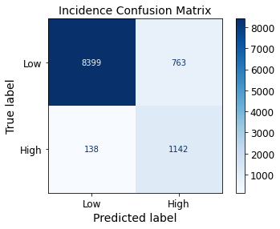

```
[[0.91672124 0.08327876]
 [0.1078125  0.8921875 ]]
```

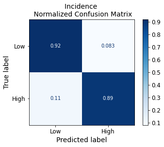

```python
from sklearn.metrics import confusion_matrix
from sklearn.metrics import ConfusionMatrixDisplay

### Incidence confusion matrix ###
# Confusion Matrix
conf_mx0 = confusion_matrix(y_test_enc[:,0], final_predictions[:,0])
#actual is rows; predicted is columns
# Plot
disp0 = ConfusionMatrixDisplay(confusion_matrix=conf_mx0, display_labels=['Low','High'])
disp0.plot(cmap=plt.cm.Blues, values_format='d')
# Title of Plot
disp0.ax_.set_title('Incidence Confusion Matrix', fontsize=14)
print(disp0.confusion_matrix)   # displays conf_mx
plt.show()     # displays colored plot of conf_mx

#### Incidence normalized confusion matrix ###
# Normalized Confusion Matrix
norm_conf_mx0 = confusion_matrix(y_test_enc[:,0], final_predictions[:,0], normalize='true')
# Plot
disp_norm0 = ConfusionMatrixDisplay(confusion_matrix=norm_conf_mx0, display_labels=['Low', 'High'])
disp_norm0.plot(cmap=plt.cm.Blues)
# Title of Plot
disp_norm0.ax_.set_title("Incidence \n Normalized Confusion Matrix", fontsize=14)
print(disp_norm0.confusion_matrix)   # displays norm_conf_mx
plt.show()          # displays colored plot of norm_conf_mx
```

138 samples were classified as a county or county equivalent that would have low incidence of Lyme disease cases when they were a county or county equivalent that would have high incidence of Lyme disease cases. The plot below displays a clearer visualization of the errors made by the classifier on the test set for the target variable Incidence.

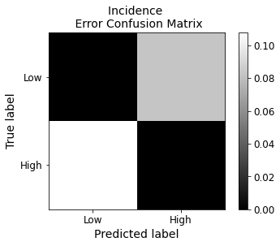

```python
#### Incidence error confusion matrix ###

# Normalized Confusion Matrix
row_sums0 = conf_mx0.sum(axis=1, keepdims=True)
norm_conf_mx0 = conf_mx0 / row_sums0 # equivalent to normalize='true'
# Error Confusion Matrix
np.fill_diagonal(norm_conf_mx0, 0)
# Plot
disp_norm0 = ConfusionMatrixDisplay(confusion_matrix=norm_conf_mx0, display_labels=["Low","High"])
disp_norm0.plot(cmap=plt.cm.gray, include_values=False)
# Title of Plot
disp_norm0.ax_.set_title("Incidence \n Error Confusion Matrix", fontsize=14)

plt.show()
```

There is a white box where the column is the Low Incidence class and row is the High Incidence class. This means the counties that would have a high incidence of Lyme disease very often got misclasified as a county that would have a low incidence of Lyme disease relative to the number of counties that would have a high incidence of Lyme disease. The box where the column is the High Incidence class and row is the Low Incidence class is a light gray. This means the counties that would have a low incidence of Lyme disease often got misclasified as a county that would have a high incidence of Lyme disease relative to the number of counties that would have a low incidence of Lyme disease. Since that box was darker than the white box, the classifier was slightly more successful with the classifications of counties that would have a low incidence of Lyme disease than it was with counties that would have a high incidence of Lyme disease.

```
[[9153  267   14    8]
 [ 111  469   52   11]
 [   3   60  174   32]
 [   0    3   17   68]]
```

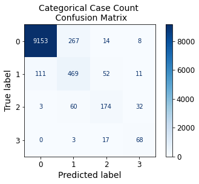

```
[[9.69392078e-01 2.82779072e-02 1.48273671e-03 8.47278119e-04]
 [1.72628305e-01 7.29393468e-01 8.08709176e-02 1.71073095e-02]
 [1.11524164e-02 2.23048327e-01 6.46840149e-01 1.18959108e-01]
 [0.00000000e+00 3.40909091e-02 1.93181818e-01 7.72727273e-01]]
```

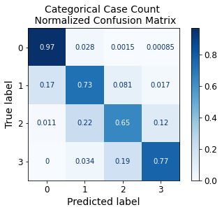

```python
from sklearn.metrics import ConfusionMatrixDisplay

### Categorical Case Count confusion matrix ###
# Confusion Matrix
conf_mx1 = confusion_matrix(y_test_enc[:,1], final_predictions[:,1])
# Plot
disp1 = ConfusionMatrixDisplay(confusion_matrix=conf_mx1, display_labels=[0,1,2,3])
disp1.plot(cmap=plt.cm.Blues, values_format='d')
# Title of Plot
disp1.ax_.set_title('Categorical Case Count \n Confusion Matrix', fontsize=14)
print(disp1.confusion_matrix)   # displays conf_mx
plt.show()     # displays colored plot of conf_mx

#### Categorical Case Count normalized confusion matrix ###
# Normalized Confusion Matrix
norm_conf_mx1 = confusion_matrix(y_test_enc[:,1], final_predictions[:,1], normalize='true')
# Plot
disp_norm1 = ConfusionMatrixDisplay(confusion_matrix=norm_conf_mx1, display_labels=[0,1,2,3])
disp_norm1.plot(cmap=plt.cm.Blues)
# Title of Plot
disp_norm1.ax_.set_title("Categorical Case Count \n Normalized Confusion Matrix", fontsize=14)
print(disp_norm1.confusion_matrix)   # displays norm_conf_mx
plt.show()          # displays colored plot of norm_conf_mx
```

The plot below displays a clearer visualization of the errors made by the classifier on the test set for the target variable Categorical Case Count.

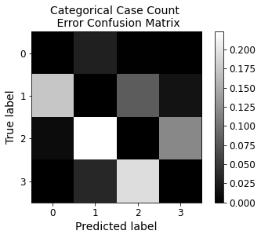

```python
#### Categorical Case Count error confusion matrix ###

# Normalized Confusion Matrix
row_sums1 = conf_mx1.sum(axis=1, keepdims=True)
norm_conf_mx1 = conf_mx1 / row_sums1 # equivalent to normalize='true'
# Error Confusion Matrix
np.fill_diagonal(norm_conf_mx1, 0)
# Plot
disp_norm1 = ConfusionMatrixDisplay(confusion_matrix=norm_conf_mx1, display_labels=[0,1,2,3])
disp_norm1.plot(cmap=plt.cm.gray, include_values=False)
# Title of Plot
disp_norm1.ax_.set_title("Categorical Case Count \n Error Confusion Matrix", fontsize=14)

plt.show()
```

A lot of samples that were classified as class 1 case count were actualy class 2 case count.

## 5.4 Recall

```python
from sklearn.metrics import precision_score, recall_score

recall_score(y_test_enc[:,0], final_predictions[:,0], average=None)
```

```
array([0.91672124, 0.8921875 ])
```

The recall score for high incidence is not as high as the recall score for low incidence.

```python
from sklearn.metrics import precision_score, recall_score

recall_score(y_test_enc[:,1], final_predictions[:,1], average=None)
```

```
array([0.96939208, 0.72939347, 0.64684015, 0.77272727])
```

The recall score for categorical case count class 0 was relatively high with a score of approximately 0.969. The lowest recall score, approximately 0.646, belonged to categorical case count class 2. The recall scores for categorical case count class 1 and 3 were approximately 0.729 and 0.773, respectively.

## 5.5 Precision

```python
from sklearn.metrics import precision_score, recall_score

precision_score(y_test_enc[:,0], final_predictions[:,0], average=None)
```

```
array([0.98383507, 0.59947507])
```

```python
from sklearn.metrics import precision_score, recall_score

precision_score(y_test_enc[:,1], final_predictions[:,1], average=None)
```

```
array([0.98769828, 0.58698373, 0.6770428 , 0.57142857])
```

A pharmaceutical company or a company aiming to make profits off of Lyme disease treatments may put more importance on precision. The CDC, public health officials, or any other environmental or scientific organization, may put more importance on overall accuracy or f1-score and recall for reasons being that they want to have the most accurate representation of Lyme disease cases and tracking of cases, or to prepare or give funding to areas that need it the most or have cases frequently.

## 5.6 Classification Report

```python
from sklearn.metrics import classification_report

print(classification_report(y_test_enc[:,0], final_predictions[:,0]))
```

```
              precision    recall  f1-score   support

         0.0       0.98      0.92      0.95      9162
         1.0       0.60      0.89      0.72      1280

    accuracy                           0.91     10442
   macro avg       0.79      0.90      0.83     10442
weighted avg       0.94      0.91      0.92     10442
```

```python
from sklearn.metrics import classification_report

print(classification_report(y_test_enc[:,1], final_predictions[:,1]))
```

```
              precision    recall  f1-score   support

         0.0       0.99      0.97      0.98      9442
         1.0       0.59      0.73      0.65       643
         2.0       0.68      0.65      0.66       269
         3.0       0.57      0.77      0.66        88

    accuracy                           0.94     10442
   macro avg       0.71      0.78      0.74     10442
weighted avg       0.95      0.94      0.95     10442
```

## 5.7 Unknown Data Comparison

I explored the relationship between number of misclassifications and number of "unknowns" for the years 2004, 2011, and 2018 since those are the three full years in the test set.

```python
test_comp_df = X_test.copy()
test_comp_df['ActualCatCaseCount'] = y_test_enc[:,1]
test_comp_df['PredCatCaseCount'] = final_predictions[:,1]
print(test_comp_df.shape)
test_comp_df.head()
```

```
(10442, 11)
```

|  | CENTLAT | CENTLON | Population | Population Density | Percent Forest Area | Precipitation | Average Temperature | Maximum Temperature | Minimum Temperature | ActualCatCaseCount | PredCatCaseCount |
| --- | --- | --- | --- | --- | --- | --- | --- | --- | --- | --- | --- |
| 2 | 32.534897 | -86.642761 | 45909.0 | 0.000030 | 0.705797 | 51.34 | 64.4 | 75.7 | 53.0 | 0.0 | 0.0 |
| 9 | 32.534897 | -86.642761 | 54135.0 | 0.000035 | 0.705797 | 73.20 | 63.8 | 74.6 | 52.9 | 0.0 | 0.0 |
| 16 | 32.534897 | -86.642761 | 55242.0 | 0.000036 | 0.705797 | 50.76 | 66.1 | 78.5 | 53.7 | 0.0 | 0.0 |
| 19 | 30.660178 | -87.749784 | 147957.0 | 0.000036 | 0.705797 | 65.80 | 67.3 | 77.7 | 56.9 | 0.0 | 0.0 |
| 26 | 30.660178 | -87.749784 | 179406.0 | 0.000044 | 0.705797 | 78.43 | 67.2 | 77.3 | 57.0 | 0.0 | 0.0 |

```python
colnames = {'Cases2000':2000,'Cases2001':2001,'Cases2002':2002,'Cases2003':2003,
            'Cases2004':2004,'Cases2005':2005,'Cases2006':2006,'Cases2007':2007,
            'Cases2008':2008,'Cases2009':2009,'Cases2010':2010,'Cases2011':2011,
            'Cases2012':2012,'Cases2013':2013,'Cases2014':2014,'Cases2015':2015,
            'Cases2016':2016,'Cases2017':2017,'Cases2018':2018}

caseYears = [2000,2001,2002,2003,2004,2005,2006,2007,2008,2009,2010,2011,2012,
             2013,2014,2015,2016,2017,2018]

# number of unknowns per state for each year
LD_UnknownCases_df = pd.melt(LDcounts_uk_df.rename(columns=colnames),
                     id_vars=['Ctyname','Stname','STCODE','CTYCODE'],
                     value_vars=caseYears, var_name='Year',
                     value_name='UnknownCaseCount')
print(LD_UnknownCases_df.shape)
LD_UnknownCases_df.head()
```

```
(950, 6)
```

|  | Ctyname | Stname | STCODE | CTYCODE | Year | UnknownCaseCount |
| --- | --- | --- | --- | --- | --- | --- |
| 0 | Alabama | Alabama | 1 | 999 | 2000 | 0 |
| 1 | Alaska | Alaska | 2 | 999 | 2000 | 0 |
| 2 | Arizona | Arizona | 4 | 999 | 2000 | 0 |
| 3 | Arkansas | Arkansas | 5 | 999 | 2000 | 0 |
| 4 | California | California | 6 | 999 | 2000 | 0 |

```python
# test_comp_df indices matches test_set
test_full_df = test_set.copy()
test_full_df['PredCatCaseCount'] = test_comp_df['PredCatCaseCount']

def func3(row):
  if row['Future CaseCount'] != row['PredCatCaseCount']:
    return 1
  else:
    return 0
test_full_df['MisclasCount'] = test_full_df.apply(lambda row: func3(row), axis=1)

# Narrowed down to the 3 full years of test set 2004, 2011, and 2018
test_full_df = test_full_df[(test_full_df['Future Year']==2004) |
                            (test_full_df['Future Year']==2011) |
                            (test_full_df['Future Year']==2018)]

# Narrowed down to the 3 full years of test set 2004, 2011, and 2018
test_LD_UkCases_df = LD_UnknownCases_df[(LD_UnknownCases_df['Year']==2004) |
                                        (LD_UnknownCases_df['Year']==2011) |
                                        (LD_UnknownCases_df['Year']==2018)]

test_MisclasCount_df = pd.DataFrame(
    test_full_df.groupby(['Stname','Future Year'], as_index=False)['MisclasCount'].sum())
# number of misclasifications for each state per year
# rename future year to year for merging so that the future year of prediction matches the year for unknowns
test_MisclasCount_df.rename(columns={'Future Year':'Year'}, inplace=True)

test_uk_misclas_df = pd.merge(test_LD_UkCases_df, test_MisclasCount_df,
                         on=['Stname','Year'],
                         how='outer')
print(test_uk_misclas_df.shape)
test_uk_misclas_df.head()
```

```
(153, 7)
```

|  | Ctyname | Stname | STCODE | CTYCODE | Year | UnknownCaseCount | MisclasCount |
| --- | --- | --- | --- | --- | --- | --- | --- |
| 0 | Alabama | Alabama | 1.0 | 999.0 | 2004.0 | 0.0 | 5.0 |
| 1 | Alaska | Alaska | 2.0 | 999.0 | 2004.0 | 0.0 | 3.0 |
| 2 | Arizona | Arizona | 4.0 | 999.0 | 2004.0 | 0.0 | 3.0 |
| 3 | Arkansas | Arkansas | 5.0 | 999.0 | 2004.0 | 0.0 | 0.0 |
| 4 | California | California | 6.0 | 999.0 | 2004.0 | 0.0 | 24.0 |

```python
test_uk_misclas_df[test_uk_misclas_df.isnull().any(axis=1)]
```

|  | Ctyname | Stname | STCODE | CTYCODE | Year | UnknownCaseCount | MisclasCount |
| --- | --- | --- | --- | --- | --- | --- | --- |
| 10 | Hawaii | Hawaii | 15.0 | 999.0 | 2004.0 | 0.0 | NaN |
| 60 | Hawaii | Hawaii | 15.0 | 999.0 | 2011.0 | 0.0 | NaN |
| 110 | Hawaii | Hawaii | 15.0 | 999.0 | 2018.0 | 0.0 | NaN |
| 150 | NaN | District of Columbia | NaN | NaN | 2004.0 | NaN | 1.0 |
| 151 | NaN | District of Columbia | NaN | NaN | 2011.0 | NaN | 1.0 |
| 152 | NaN | District of Columbia | NaN | NaN | 2018.0 | NaN | 1.0 |

I dropped Hawaii and added District of Columbia to Virginia.

```python
test_uk_misclas_df[test_uk_misclas_df['Stname']=='Virginia']
```

|  | Ctyname | Stname | STCODE | CTYCODE | Year | UnknownCaseCount | MisclasCount |
| --- | --- | --- | --- | --- | --- | --- | --- |
| 45 | Virginia | Virginia | 51.0 | 999.0 | 2004.0 | 0.0 | 49.0 |
| 95 | Virginia | Virginia | 51.0 | 999.0 | 2011.0 | 93.0 | 72.0 |
| 145 | Virginia | Virginia | 51.0 | 999.0 | 2018.0 | 34.0 | 88.0 |

```python
# Add District of Columbia to Virginia
DC_uk_misVal = test_uk_misclas_df.MisclasCount[test_uk_misclas_df['Stname']=='District of Columbia'].values
test_uk_misclas_df.MisclasCount[test_uk_misclas_df['Stname']=='Virginia'] += DC_uk_misVal
test_uk_misclas_df[test_uk_misclas_df['Stname']=='Virginia']
```

|  | Ctyname | Stname | STCODE | CTYCODE | Year | UnknownCaseCount | MisclasCount |
| --- | --- | --- | --- | --- | --- | --- | --- |
| 45 | Virginia | Virginia | 51.0 | 999.0 | 2004.0 | 0.0 | 50.0 |
| 95 | Virginia | Virginia | 51.0 | 999.0 | 2011.0 | 93.0 | 73.0 |
| 145 | Virginia | Virginia | 51.0 | 999.0 | 2018.0 | 34.0 | 89.0 |

```python
test_uk_misclas_df.dropna(inplace=True)
```

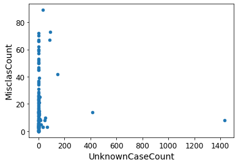

```python
import matplotlib.pyplot as plt
%matplotlib inline

ax = test_uk_misclas_df.plot.scatter(x='UnknownCaseCount', y='MisclasCount')
```

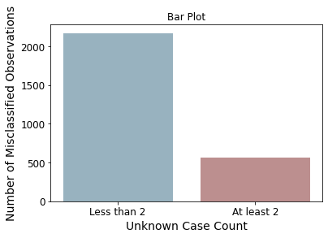

```python
#barplot
%matplotlib inline

ukCat0 = test_uk_misclas_df.MisclasCount[test_uk_misclas_df['UnknownCaseCount']<2].sum()
ukCat1 = test_uk_misclas_df.MisclasCount[test_uk_misclas_df['UnknownCaseCount']>=2].sum()
barlist = plt.bar(['Less than 2','At least 2'],
                  height=[ukCat0,ukCat1],
                  color=[(0.2, 0.4, 0.5, 0.5),'rosybrown','maroon'])
plt.ylabel('Number of Misclassified Observations')
plt.xlabel('Unknown Case Count')
plt.title('Bar Plot')
plt.show()
```

```python
test_LD_UkCases_cty_df = test_LD_UkCases_df.drop('Ctyname',axis=1)
test_full_cty_df = test_full_df.loc[:,['STCODE','CTYCODE','Stname','Ctyname',
                                       'Future Year','MisclasCount']]
test_full_cty_df.Stname[test_full_cty_df['Ctyname']=='District of Columbia'] = 'Virginia'
test_full_cty_df.rename(columns={'Future Year':'Year'}, inplace=True)
test_uk_misclas_cty_df = pd.merge(test_LD_UkCases_cty_df, test_full_cty_df,
                                  on=['Stname','Year'], how='outer')
```

```python
print(test_uk_misclas_cty_df.shape)
test_uk_misclas_cty_df.head()
```

```
(9411, 9)
```

|  | Stname | STCODE_x | CTYCODE_x | Year | UnknownCaseCount | STCODE_y | CTYCODE_y | Ctyname | MisclasCount |
| --- | --- | --- | --- | --- | --- | --- | --- | --- | --- |
| 0 | Alabama | 1 | 999 | 2004 | 0 | 1.0 | 1.0 | Autauga County | 0.0 |
| 1 | Alabama | 1 | 999 | 2004 | 0 | 1.0 | 3.0 | Baldwin County | 0.0 |
| 2 | Alabama | 1 | 999 | 2004 | 0 | 1.0 | 5.0 | Barbour County | 0.0 |
| 3 | Alabama | 1 | 999 | 2004 | 0 | 1.0 | 7.0 | Bibb County | 0.0 |
| 4 | Alabama | 1 | 999 | 2004 | 0 | 1.0 | 9.0 | Blount County | 0.0 |

```python
test_uk_misclas_cty_df[test_uk_misclas_cty_df.isnull().any(axis=1)]
```

|  | Stname | STCODE_x | CTYCODE_x | Year | UnknownCaseCount | STCODE_y | CTYCODE_y | Ctyname | MisclasCount |
| --- | --- | --- | --- | --- | --- | --- | --- | --- | --- |
| 544 | Hawaii | 15 | 999 | 2004 | 0 | NaN | NaN | NaN | NaN |
| 3681 | Hawaii | 15 | 999 | 2011 | 0 | NaN | NaN | NaN | NaN |
| 6818 | Hawaii | 15 | 999 | 2018 | 0 | NaN | NaN | NaN | NaN |

```python
test_uk_misclas_cty_df.dropna(inplace=True)
```

```python
print("The following calculations were on the test set samples whose labels\n",
      "represented Lyme disease in the years 2004, 2011, and 2018:")

# Total number of observations with less than 2 unknown (2004,2011,2018)
A = len(test_uk_misclas_cty_df[test_uk_misclas_cty_df['UnknownCaseCount']<2])
print("\tNumber of observations with less than 2 unknown:",
      A) #8070
# Number of misclasified observations with less than 2 unknown (2004,2011,2018)
a = test_uk_misclas_df.MisclasCount[test_uk_misclas_df['UnknownCaseCount']<2].sum()
print("\tNumber of misclasified observations with less than 2 unknown:",
      int(a)) #2171
# Percent of miscalssified observations with less than 2 unknown out of all
          # observations with less than 2 unknown (2004,2011,2018)
print("\tProportion of misclasified observations with less than 2 unknown\n",
      "\t out of all observations with less than 2 unknown:",
      a/A) #0.2690210656753408

# Total number of observations with at least 2 unknown (2004,2011,2018)
B = len(test_uk_misclas_cty_df[test_uk_misclas_cty_df['UnknownCaseCount']>=2])
print("\tNumber of observations with at least 2 unknown:",
      B) #1338
# Number of misclasified observations with at least 2 unknown (2004,2011,2018)
b = test_uk_misclas_df.MisclasCount[test_uk_misclas_df['UnknownCaseCount']>=2].sum()
print("\tNumber of misclasified observations with at least 2 unknown:",
      b) #568.0
# Percent of misclassified observations with at least 2 unknown out of all
          # observations with at least 2 unknown (2004,2011,2018)
print("\tProportion of misclassified observations with at least 2 unknown\n",
      "\t out of all observations with at least 2 unknown:",
      b/B) #0.42451420029895365

print("\tDifference between the proportions:", (b/B) - (a/A))
#0.42451420029895365-0.2690210656753408=0.15549313462361286
```

```
The following calculations were on the test set samples whose labels
 represented Lyme disease in the years 2004, 2011, and 2018:
	Number of observations with less than 2 unknown: 8070
	Number of misclasified observations with less than 2 unknown: 2171
	Proportion of misclasified observations with less than 2 unknown
 	 out of all observations with less than 2 unknown: 0.2690210656753408
	Number of observations with at least 2 unknown: 1338
	Number of misclasified observations with at least 2 unknown: 568.0
	Proportion of misclassified observations with at least 2 unknown
 	 out of all observations with at least 2 unknown: 0.42451420029895365
	Difference between the proportions: 0.15549313462361286
```

The percentage of misclassified observations with their respective state reporting at least two unknown cases for the corresponding year out of all the test set observations (2004, 2011, and 2018 predictions) with their respective state reporting at least two unknown cases for the corresponding year was a little over 15% (about 15.549%) more than the percentage of misclassified observations with their respective state reporting less than two unknown cases for the corresponding year out of all the test set observations (2004, 2011, and 2018 predictions) with their respective state reporting less than two unknown cases for the corresponding year. Thus, even though there were more observations misclassifed with less than two unknown cases, the percentages reflect that an observation in this dataset was more likely to be misclassified when the respective state reported at least two unknown cases for the corresponding year than when the respective state reported less than two unknown cases for the corresponding year.

## 5.8 Year Comparison

I compared the performance of the classifier on the full years to the random "other" years in the test set.

```python
print(LD_ff_df.loc[X_test.index].shape)
LD_ff_df.loc[X_test.index].head()
```

```
(10442, 24)
```

|  | Ctyname | Stname | STCODE | CTYCODE | Year | CaseCount | Population | Frequency | AREALAND | CENTLAT | CENTLON | Population Density | Percent Forest Area | Precipitation | Average Temperature | Maximum Temperature | Minimum Temperature | Incidence | CaseCat | Future Year | Future CaseCount | Future CaseCat | Future Frequency | Future Incidence |
| --- | --- | --- | --- | --- | --- | --- | --- | --- | --- | --- | --- | --- | --- | --- | --- | --- | --- | --- | --- | --- | --- | --- | --- | --- |
| 2 | Autauga County | Alabama | 1.0 | 1.0 | 2002 | 0.0 | 45909.0 | 0.000000 | 1.539602e+09 | 32.534897 | -86.642761 | 0.000030 | 0.705797 | 51.34 | 64.4 | 75.7 | 53.0 | Low | 0 | 2004 | 0.0 | 0 | 0.000000 | Low |
| 9 | Autauga County | Alabama | 1.0 | 1.0 | 2009 | 0.0 | 54135.0 | 0.000000 | 1.539602e+09 | 32.534897 | -86.642761 | 0.000035 | 0.705797 | 73.20 | 63.8 | 74.6 | 52.9 | Low | 0 | 2011 | 0.0 | 0 | 0.000000 | Low |
| 16 | Autauga County | Alabama | 1.0 | 1.0 | 2016 | 2.0 | 55242.0 | 0.000036 | 1.539602e+09 | 32.534897 | -86.642761 | 0.000036 | 0.705797 | 50.76 | 66.1 | 78.5 | 53.7 | Low | 0 | 2018 | 0.0 | 0 | 0.000000 | Low |
| 19 | Baldwin County | Alabama | 1.0 | 3.0 | 2002 | 1.0 | 147957.0 | 0.000007 | 4.117626e+09 | 30.660178 | -87.749784 | 0.000036 | 0.705797 | 65.80 | 67.3 | 77.7 | 56.9 | Low | 0 | 2004 | 0.0 | 0 | 0.000000 | Low |
| 26 | Baldwin County | Alabama | 1.0 | 3.0 | 2009 | 1.0 | 179406.0 | 0.000006 | 4.117626e+09 | 30.660178 | -87.749784 | 0.000044 | 0.705797 | 78.43 | 67.2 | 77.3 | 57.0 | Low | 0 | 2011 | 1.0 | 0 | 0.000005 | Low |

```python
y_test_comp = y_test.copy()
y_test_comp["Predicted Incidence"] = oe.inverse_transform(final_predictions)[:,0]
y_test_comp["Predicted CaseCat"] = final_predictions[:,1].astype(int)
print(y_test_comp.shape)
y_test_comp.head()
```

```
(10442, 4)
```

|  | Future Incidence | Future CaseCat | Predicted Incidence | Predicted CaseCat |
| --- | --- | --- | --- | --- |
| 2 | Low | 0 | Low | 0 |
| 9 | Low | 0 | Low | 0 |
| 16 | Low | 0 | Low | 0 |
| 19 | Low | 0 | Low | 0 |
| 26 | Low | 0 | Low | 0 |

```python
incorr_df = y_test_comp.loc[y_test_comp["Future Incidence"] != y_test_comp["Predicted Incidence"]]
print(incorr_df.shape) #(901, 4)
incorr_df.head()
```

```
(901, 4)
```

|  | Future Incidence | Future CaseCat | Predicted Incidence | Predicted CaseCat |
| --- | --- | --- | --- | --- |
| 1240 | High | 0 | Low | 0 |
| 1345 | Low | 0 | High | 0 |
| 1498 | Low | 0 | High | 0 |
| 1512 | Low | 0 | High | 0 |
| 1556 | Low | 0 | High | 0 |

```python
ff_incorr_Inc = LD_ff_df.loc[incorr_df.index]
print(ff_incorr_Inc.shape)
ff_incorr_Inc.head()
```

```
(901, 24)
```

|  | Ctyname | Stname | STCODE | CTYCODE | Year | CaseCount | Population | Frequency | AREALAND | CENTLAT | CENTLON | Population Density | Percent Forest Area | Precipitation | Average Temperature | Maximum Temperature | Minimum Temperature | Incidence | CaseCat | Future Year | Future CaseCount | Future CaseCat | Future Frequency | Future Incidence |
| --- | --- | --- | --- | --- | --- | --- | --- | --- | --- | --- | --- | --- | --- | --- | --- | --- | --- | --- | --- | --- | --- | --- | --- | --- |
| 1240 | Denali Borough | Alaska | 2.0 | 68.0 | 2016 | 0.0 | 2039.0 | 0.000000 | 3.291010e+10 | 63.676986 | -150.031876 | 6.195667e-08 | 0.351672 | 24.38 | 30.4 | 39.1 | 21.8 | Low | 0 | 2018 | 1.0 | 0 | 0.000486 | High |
| 1345 | Ketchikan Gateway Borough | Alaska | 2.0 | 130.0 | 2002 | 1.0 | 13599.0 | 0.000074 | 1.257938e+10 | 55.484756 | -131.031234 | 1.081055e-06 | 0.351672 | 164.56 | 40.4 | 45.8 | 35.1 | Low | 0 | 2004 | 0.0 | 0 | 0.000000 | Low |
| 1498 | Sitka City and Borough | Alaska | 2.0 | 220.0 | 2002 | 0.0 | 8874.0 | 0.000000 | 7.433477e+09 | 57.175668 | -135.298496 | 1.193789e-06 | 0.351672 | 155.11 | 40.6 | 45.6 | 35.5 | Low | 0 | 2004 | 0.0 | 0 | 0.000000 | Low |
| 1512 | Sitka City and Borough | Alaska | 2.0 | 220.0 | 2016 | 0.0 | 8738.0 | 0.000000 | 7.433477e+09 | 57.175668 | -135.298496 | 1.175493e-06 | 0.351672 | 153.45 | 43.3 | 48.5 | 38.1 | Low | 0 | 2018 | 0.0 | 0 | 0.000000 | Low |
| 1556 | Valdez-Cordova Census Area | Alaska | 2.0 | 261.0 | 2009 | 0.0 | 9492.0 | 0.000000 | 8.865585e+10 | 61.408247 | -144.781893 | 1.070657e-07 | 0.351672 | 65.21 | 27.0 | 35.3 | 18.7 | Low | 0 | 2011 | 0.0 | 0 | 0.000000 | Low |

The dataset below shows the observations in the test set that the classifier misclassified when predicted the incidence for the future years 2004, 2011, or 2018.

```python
# future year 2004 2011 or 2018 which model hadn't seen at all in training
unseenYear_df = ff_incorr_Inc.loc[(ff_incorr_Inc["Future Year"] == 2004) |
                                  (ff_incorr_Inc["Future Year"] == 2011) |
                                  (ff_incorr_Inc["Future Year"] == 2018)]
print(unseenYear_df.shape)
unseenYear_df.head()
```

```
(823, 24)
```

|  | Ctyname | Stname | STCODE | CTYCODE | Year | CaseCount | Population | Frequency | AREALAND | CENTLAT | CENTLON | Population Density | Percent Forest Area | Precipitation | Average Temperature | Maximum Temperature | Minimum Temperature | Incidence | CaseCat | Future Year | Future CaseCount | Future CaseCat | Future Frequency | Future Incidence |
| --- | --- | --- | --- | --- | --- | --- | --- | --- | --- | --- | --- | --- | --- | --- | --- | --- | --- | --- | --- | --- | --- | --- | --- | --- |
| 1240 | Denali Borough | Alaska | 2.0 | 68.0 | 2016 | 0.0 | 2039.0 | 0.000000 | 3.291010e+10 | 63.676986 | -150.031876 | 6.195667e-08 | 0.351672 | 24.38 | 30.4 | 39.1 | 21.8 | Low | 0 | 2018 | 1.0 | 0 | 0.000486 | High |
| 1345 | Ketchikan Gateway Borough | Alaska | 2.0 | 130.0 | 2002 | 1.0 | 13599.0 | 0.000074 | 1.257938e+10 | 55.484756 | -131.031234 | 1.081055e-06 | 0.351672 | 164.56 | 40.4 | 45.8 | 35.1 | Low | 0 | 2004 | 0.0 | 0 | 0.000000 | Low |
| 1498 | Sitka City and Borough | Alaska | 2.0 | 220.0 | 2002 | 0.0 | 8874.0 | 0.000000 | 7.433477e+09 | 57.175668 | -135.298496 | 1.193789e-06 | 0.351672 | 155.11 | 40.6 | 45.6 | 35.5 | Low | 0 | 2004 | 0.0 | 0 | 0.000000 | Low |
| 1512 | Sitka City and Borough | Alaska | 2.0 | 220.0 | 2016 | 0.0 | 8738.0 | 0.000000 | 7.433477e+09 | 57.175668 | -135.298496 | 1.175493e-06 | 0.351672 | 153.45 | 43.3 | 48.5 | 38.1 | Low | 0 | 2018 | 0.0 | 0 | 0.000000 | Low |
| 1556 | Valdez-Cordova Census Area | Alaska | 2.0 | 261.0 | 2009 | 0.0 | 9492.0 | 0.000000 | 8.865585e+10 | 61.408247 | -144.781893 | 1.070657e-07 | 0.351672 | 65.21 | 27.0 | 35.3 | 18.7 | Low | 0 | 2011 | 0.0 | 0 | 0.000000 | Low |

The dataset below shows the observations in the test set that the classifier misclassified when predicted the incidence for the future years other than 2004, 2011, or 2018.

```python
otherIncorr_Inc = ff_incorr_Inc.loc[(ff_incorr_Inc["Future Year"] != 2004) &
                                    (ff_incorr_Inc["Future Year"] != 2011) &
                                    (ff_incorr_Inc["Future Year"] != 2018)]
print(otherIncorr_Inc.shape)
otherIncorr_Inc.head()
```

```
(78, 24)
```

|  | Ctyname | Stname | STCODE | CTYCODE | Year | CaseCount | Population | Frequency | AREALAND | CENTLAT | CENTLON | Population Density | Percent Forest Area | Precipitation | Average Temperature | Maximum Temperature | Minimum Temperature | Incidence | CaseCat | Future Year | Future CaseCount | Future CaseCat | Future Frequency | Future Incidence |
| --- | --- | --- | --- | --- | --- | --- | --- | --- | --- | --- | --- | --- | --- | --- | --- | --- | --- | --- | --- | --- | --- | --- | --- | --- |
| 13437 | Boone County | Iowa | 19.0 | 15.0 | 2007 | 0.0 | 26553.0 | 0.000000 | 1.477383e+09 | 42.036448 | -93.931643 | 0.000018 | 0.084310 | 43.25 | 49.0 | 59.1 | 38.9 | Low | 0 | 2009 | 0.0 | 0 | 0.000000 | Low |
| 14647 | Poweshiek County | Iowa | 19.0 | 157.0 | 2010 | 1.0 | 18914.0 | 0.000053 | 1.514945e+09 | 41.686363 | -92.531464 | 0.000012 | 0.084310 | 51.59 | 48.7 | 58.9 | 38.5 | Low | 0 | 2012 | 1.0 | 0 | 0.000053 | Low |
| 14866 | Washington County | Iowa | 19.0 | 183.0 | 2008 | 0.0 | 21686.0 | 0.000000 | 1.473216e+09 | 41.335526 | -91.717861 | 0.000015 | 0.084310 | 47.14 | 47.8 | 58.0 | 37.6 | Low | 0 | 2010 | 1.0 | 0 | 0.000046 | Low |
| 48396 | Franklin County | Virginia | 51.0 | 67.0 | 2014 | 1.0 | 56268.0 | 0.000018 | 1.788680e+09 | 36.991903 | -79.881105 | 0.000031 | 0.629382 | 40.35 | 54.8 | 65.6 | 43.9 | Low | 0 | 2016 | 1.0 | 0 | 0.000018 | Low |
| 38763 | Mercer County | Pennsylvania | 42.0 | 85.0 | 2003 | 7.0 | 119431.0 | 0.000059 | 1.741807e+09 | 41.302121 | -80.257693 | 0.000069 | 0.586066 | 49.67 | 47.6 | 57.8 | 37.5 | Low | 0 | 2005 | 3.0 | 0 | 0.000025 | Low |

```python
# Accuracy for 2018
inc2018 = len(ff_incorr_Inc.loc[ff_incorr_Inc['Future Year'] == 2018])
print("Number of 2018 incorrect Incidence classifications: \n", inc2018)
print("Proportion of 2018 Incidence misclassifications out of total Incidence misclassifications: \n",
      inc2018/len(ff_incorr_Inc)) # percent wrong out of incorrect
print("Proportion of correct 2018 Incidence classifications out of total 2018 observations: \n",
      1-inc2018/len(test_set.loc[test_set['Future Year'] == 2018])) # Accuracy out of total 2018 test set

# Accuracy for 2011
inc2011 = len(ff_incorr_Inc.loc[ff_incorr_Inc['Future Year'] == 2011])
print("\nNumber of 2011 incorrect Incidence classifications: \n", inc2011)
print("Proportion of 2011 Incidence misclassifications out of total Incidence misclassifications: \n",
      inc2011/len(ff_incorr_Inc)) # percent wrong out of incorrect
print("Proportion of correct 2011 Incidence classifications out of total 2011 observations: \n",
      1-inc2011/len(test_set[test_set['Future Year'] == 2011])) # Accuracy out of total 2011 test set

# Accuracy for 2004
inc2004 = len(ff_incorr_Inc.loc[ff_incorr_Inc['Future Year'] == 2004])
print("\nNumber of 2004 incorrect Incidence classifications: \n", inc2004)
print("Proportion of 2004 Incidence misclassifications out of total Incidence misclassifications: \n",
      inc2004/len(ff_incorr_Inc)) # percent wrong out of incorrect
print("Proportion of correct 2004 Incidence classifications out of total 2004 observations: \n",
      1-inc2004/len(test_set[test_set['Future Year'] == 2004])) # Accuracy out of total 2004 test set

# Accuracy for the subset of all other years in test set
incOther = len(ff_incorr_Inc.loc[(ff_incorr_Inc['Future Year'] != 2004) &
                                 (ff_incorr_Inc['Future Year'] != 2011) &
                                 (ff_incorr_Inc['Future Year'] != 2018)])
print("\nNumber of random (other) years incorrect Incidence classifications: \n", incOther)
print("Proportion of random (other) years Incidence misclassifications out of \n",
      "total Incidence misclassifications: \n",
      incOther/len(ff_incorr_Inc)) # percent wrong out of incorrect
print("Proportion of correct random (other) years Incidence classifications out of \n",
      "total random (other) years observations: \n",
      1-incOther/len(test_set[(test_set['Future Year'] != 2004) &
                              (test_set['Future Year'] != 2011) &
                              (test_set['Future Year'] != 2018)])) # Accuracy out of total Other test set
```

```
Number of 2018 incorrect Incidence classifications:
 217
Proportion of 2018 Incidence misclassifications out of total Incidence misclassifications:
 0.24084350721420644
Proportion of correct 2018 Incidence classifications out of total 2018 observations:
 0.9308035714285714

Number of 2011 incorrect Incidence classifications:
 265
Proportion of 2011 Incidence misclassifications out of total Incidence misclassifications:
 0.29411764705882354
Proportion of correct 2011 Incidence classifications out of total 2011 observations:
 0.9154974489795918

Number of 2004 incorrect Incidence classifications:
 341
Proportion of 2004 Incidence misclassifications out of total Incidence misclassifications:
 0.37846836847946724
Proportion of correct 2004 Incidence classifications out of total 2004 observations:
 0.8912627551020408

Number of random (other) years incorrect Incidence classifications:
 78
Proportion of random (other) years Incidence misclassifications out of
 total Incidence misclassifications:
 0.08657047724750278
Proportion of correct random (other) years Incidence classifications out of
 total random (other) years observations:
 0.9245647969052224
```

The above calculations show that even though the proportion of Incidence misclassifications of years that the classifier had seen before was a lot less than the proportion of Incidence misclassifications of years that the classifier had not seen before, it is most likely due to the fact that the number of observations in the test set that were for the years the classifier had not seen before (future years 2004, 2011, and 2018) was a lot more than the number of observations in the test set that were for years the classifier had seen before (any observation with a future year other than 2004, 2011, and 2018).

The classifier predicted the incidence for the year 2018 better than the incidence for the years 2011 and 2004. It also had a higher accuracy with 2018 than it did with the "random" other (observations with a future year other than 2004, 2011, and 2018 in the test set) years. The accuracies for those subgroups ranged from around 89% to 93% which are all very close in range. Thus, whether the future year had been seen before in training did not have a huge impact on the classification results.

## 5.9 2020 Lyme Disease Predictions

Using the 2018 data, the classifier predicted the incidence and class of case count for Lyme disease in the United States per county for the year 2020.

```python
df_2020 = LD_full_df.loc[LD_full_df['Year']==2018]

X_2020 = df_2020.loc[:,['CENTLAT','CENTLON','Population','Population Density',
                        'Percent Forest Area','Precipitation',
                        'Average Temperature','Maximum Temperature',
                        'Minimum Temperature']]
```

Below are the predictions for the incidence and class of case count for the year 2020 where the true labels are currently not out yet as the year 2020 has not finished.

```python
pred_2020 = final_model.predict(X_2020)
pred_2020
```

```
array([[0., 0.],
       [0., 0.],
       [0., 0.],
       ...,
       [0., 0.],
       [0., 0.],
       [0., 0.]])
```

```python
pred_2020 = oe.inverse_transform(pred_2020)
pred_2020_df = pd.DataFrame(pred_2020).rename({0:"2020 Incidence", 1:"2020 CaseCat"}, axis=1)
pred_2020_df
```

|  | 2020 Incidence | 2020 CaseCat |
| --- | --- | --- |
| 0 | Low | 0 |
| 1 | Low | 0 |
| 2 | Low | 0 |
| 3 | Low | 0 |
| 4 | Low | 0 |
| ... | ... | ... |
| 3131 | Low | 0 |
| 3132 | Low | 0 |
| 3133 | Low | 0 |
| 3134 | Low | 0 |
| 3135 | Low | 0 |

3136 rows × 2 columns

```python
full_2020_df = LD_full_df.iloc[X_2020.index.values]
full_2020_df["2020 Incidence"] = pred_2020[:,0]
full_2020_df["2020 CaseCat"] = pred_2020[:,1]
```

Below displays the full dataset for 2018 data and 2020 predictions where the future predictions are the last two columns.

```python
full_2020_df
```

|  | Ctyname | Stname | STCODE | CTYCODE | Year | CaseCount | Population | Frequency | AREALAND | CENTLAT | CENTLON | Population Density | Percent Forest Area | Precipitation | Average Temperature | Maximum Temperature | Minimum Temperature | Incidence | CaseCat | 2020 Incidence | 2020 CaseCat |
| --- | --- | --- | --- | --- | --- | --- | --- | --- | --- | --- | --- | --- | --- | --- | --- | --- | --- | --- | --- | --- | --- |
| 18 | Autauga County | Alabama | 1.0 | 1.0 | 2018 | 0.0 | 55601.0 | 0.000000 | 1.539602e+09 | 32.534897 | -86.642761 | 0.000036 | 0.705797 | 68.14 | 65.2 | 76.2 | 54.1 | Low | 0 | Low | 0 |
| 37 | Baldwin County | Alabama | 1.0 | 3.0 | 2018 | 0.0 | 218022.0 | 0.000000 | 4.117626e+09 | 30.660178 | -87.749784 | 0.000053 | 0.705797 | 75.08 | 68.1 | 77.9 | 58.2 | Low | 0 | Low | 0 |
| 56 | Barbour County | Alabama | 1.0 | 5.0 | 2018 | 0.0 | 24881.0 | 0.000000 | 2.292160e+09 | 31.869522 | -85.393415 | 0.000011 | 0.705797 | 60.05 | 65.9 | 76.6 | 55.1 | Low | 0 | Low | 0 |
| 75 | Bibb County | Alabama | 1.0 | 7.0 | 2018 | 1.0 | 22400.0 | 0.000045 | 1.612160e+09 | 32.998601 | -87.126462 | 0.000014 | 0.705797 | 63.68 | 63.9 | 75.0 | 52.7 | Low | 0 | Low | 0 |
| 94 | Blount County | Alabama | 1.0 | 9.0 | 2018 | 2.0 | 57840.0 | 0.000035 | 1.670128e+09 | 33.980805 | -86.567538 | 0.000035 | 0.705797 | 60.71 | 62.5 | 72.4 | 52.6 | Low | 0 | Low | 0 |
| ... | ... | ... | ... | ... | ... | ... | ... | ... | ... | ... | ... | ... | ... | ... | ... | ... | ... | ... | ... | ... | ... |
| 59507 | Sweetwater County | Wyoming | 56.0 | 37.0 | 2018 | 0.0 | 43051.0 | 0.000000 | 2.700563e+10 | 41.659527 | -108.880389 | 0.000002 | 0.184229 | 8.34 | 43.5 | 57.0 | 30.0 | Low | 0 | Low | 0 |
| 59526 | Teton County | Wyoming | 56.0 | 39.0 | 2018 | 0.0 | 23081.0 | 0.000000 | 1.035182e+10 | 43.932677 | -110.589375 | 0.000002 | 0.184229 | 35.71 | 36.0 | 48.0 | 24.2 | Low | 0 | Low | 0 |
| 59545 | Uinta County | Wyoming | 56.0 | 41.0 | 2018 | 0.0 | 20299.0 | 0.000000 | 5.391176e+09 | 41.287452 | -110.547577 | 0.000004 | 0.184229 | 10.70 | 41.3 | 54.8 | 27.9 | Low | 0 | Low | 0 |
| 59564 | Washakie County | Wyoming | 56.0 | 43.0 | 2018 | 0.0 | 7885.0 | 0.000000 | 5.798139e+09 | 43.905107 | -107.681897 | 0.000001 | 0.184229 | 12.05 | 43.9 | 57.2 | 30.6 | Low | 0 | Low | 0 |
| 59583 | Weston County | Wyoming | 56.0 | 45.0 | 2018 | 0.0 | 6967.0 | 0.000000 | 6.210804e+09 | 43.840238 | -104.567844 | 0.000001 | 0.184229 | 21.94 | 43.7 | 56.8 | 30.6 | Low | 0 | Low | 0 |

3136 rows × 21 columns

Below displays the 2020 predictions alongside the name of the county and state.

```python
name_pred_2020 = full_2020_df.loc[:,["Ctyname","Stname","2020 Incidence",
                                     "2020 CaseCat", ]]
name_pred_2020
```

|  | Ctyname | Stname | 2020 Incidence | 2020 CaseCat |
| --- | --- | --- | --- | --- |
| 18 | Autauga County | Alabama | Low | 0 |
| 37 | Baldwin County | Alabama | Low | 0 |
| 56 | Barbour County | Alabama | Low | 0 |
| 75 | Bibb County | Alabama | Low | 0 |
| 94 | Blount County | Alabama | Low | 0 |
| ... | ... | ... | ... | ... |
| 59507 | Sweetwater County | Wyoming | Low | 0 |
| 59526 | Teton County | Wyoming | Low | 0 |
| 59545 | Uinta County | Wyoming | Low | 0 |
| 59564 | Washakie County | Wyoming | Low | 0 |
| 59583 | Weston County | Wyoming | Low | 0 |

3136 rows × 4 columns

## 6.1 Closure

The classification that was done consisted of the two-year future prediction of Lyme disease incidence and categorical case count for counties and county-equivalents. Article based research was done on Lyme disease prior to finding the data and creating the features that would help predict the incidence and class count of reported Lyme diease cases at the county level. After exploring and transforming the data I found from credible resources to create the features and targets, I trained and fine tuned multiple classifiers. The best model chosen from the train set to be the final classifier for the prediction of the classes for Lyme disease incidence and case count for the year that was two years into the future was the Random Forest classifier. This was found through fine-tuning and evaluations by cross-validations, confusion matrices, recall and precision scores, and multiple ouput, or multiple target, accuracies for the Random Forest and K-Nearest-Neighbors classifiers. I tested the final classifier on the test set and evaluated it using accuracy, recall and precision, and analyzed the classification with error analysis and comparisons of years and "unknown" data. Overall, the model performed well, with high accuracies above 90% for each individual target on the test set made up of data that was not seen while fitting the classifier.

I showed the test set accuracy for each class (recall) for both targets. I showed the accuracies for the years 2004, 2011, and 2018 in the test set and compared them with the random "other" years. The year, whether it was a full year or a collection of samples from different years that were years, but not samples the classifier had seen during training or when it was fit, that the classifier was predicting the targets for did not show a significant affect on the accuracy of the model on the test set. I also explored the relationship between misclassifications and data for the cases of unknown residence. It was found that samples of counties or county equivalents that belonged to states with a higher unknown case count for the year the classifier was predicting labels for were misclassificated more frequently (out of the samples of counties or county equivalents that belonged to states with at least two reported cases of unknown residence for the year the classifier was predicting labels for) than the samples of counties or county equivalents that belonged to states with a lower unknown case count for the year the classifier was predicting labels for (out of the samples of counties or county equivalents that belonged to states with less than two reported cases of unknown residence for the year the classifier was predicting labels for). The scores of the final classifier on the test set are not horrible, and despite some low scores such as the recall and precision of the Categorical Case Count target variable classes, some scores were very high. Ultimately, insight was gained on Lyme disease including the yearly future predictions of United States county and county equivalent incidences and counts of reported cases of Lyme disease.

## 6.2 Further

An addition of feature(s) representing medical or insurance coverage and/or county poverty rates could be explored as the number of reported cases might be less for areas where poeple do not have good health insurance where they could go to the doctor to get tested for Lyme disease. Another feature could be the amount of travel or location of travel the residing poeple of counties and county equivalents take. Naturally occurring populations of blacklegged and western blacklegged ticks do not occur in Alaska [34] so the Lyme disease cases reported there could be from traveling to other states where ticks do naturally occur.

The average of the monthly maximum and minimum temperatures per year were used as features, but could use the actual (not average of monthly) maximum and minimum temperatures for the year. Instead of a feature for forest area within the state, that could be changed to the forest area within a certain radius of the county. Also, features such as the number of residential and nonresidential building units or the growth rate of counties (e.g. population change or population density growth rate) or number of new buildings beig made (building permits) could be included in the feature dataset for training.

It is not uncommon to have coinfections of other tick-borne diseases with Lyme disease so more tick-borne diseases could be explored with Lyme disease such as Babesiosis.

# References

[1] “Lyme Disease.” $\textit{Centers for Disease Control and Prevention}$, Centers for Disease Control and Prevention, 16 Dec. 2019, www.cdc.gov/lyme/index.html.

[2] “TDR | Vectors.” $\textit{World Health Organization}$, World Health Organization, 1 Apr. 2019, www.who.int/tdr/diseases-topics/vectors/en/.

[3] “Transmission.” $\textit{Centers for Disease Control and Prevention}$, Centers for Disease Control and Prevention, 29 Jan. 2020, www.cdc.gov/lyme/transmission/index.html.

[4] Steere, Allen C, et al. “Lyme Borreliosis.” $\textit{Nature Reviews. Disease Primers}$, U.S. National Library of Medicine, 15 Dec. 2016, www.ncbi.nlm.nih.gov/pmc/articles/PMC5539539/.

[5] “Diseases Transmitted by Ticks.” $\textit{Centers for Disease Control and Prevention}$, Centers for Disease Control and Prevention, 2 Apr. 2020, www.cdc.gov/ticks/diseases/index.html.

[6] “What You Need to Know about Borrelia Mayonii.” $\textit{Centers for Disease Control and Prevention}$, Centers for Disease Control and Prevention, 12 Sept. 2019, www.cdc.gov/lyme/mayonii/index.html.

[7] “Lyme Disease Maps: Historical Data.” $\textit{Centers for Disease Control and Prevention}$, Centers for Disease Control and Prevention, 22 Nov. 2019, www.cdc.gov/lyme/stats/maps.html.

[8] “Why Is CDC Concerned about Lyme Disease?” $\textit{Centers for Disease Control and Prevention}$, Centers for Disease Control and Prevention, 1 Dec. 2017, www.cdc.gov/lyme/why-is-cdc-concerned-about-lyme-disease.html.

[9] “Signs and Symptoms of Untreated Lyme Disease.” $\textit{Centers for Disease Control and Prevention}$, Centers for Disease Control and Prevention, 13 Apr. 2020, www.cdc.gov/lyme/signs_symptoms/index.html.

[10] “Post-Treatment Lyme Disease Syndrome.” $\textit{Centers for Disease Control and Prevention}$, Centers for Disease Control and Prevention, 8 Nov. 2019, www.cdc.gov/lyme/postLDS/index.html.

[11] “Preventing Tick Bites on People.” $\textit{Centers for Disease Control and Prevention}$, Centers for Disease Control and Prevention, 30 Sept. 2019, www.cdc.gov/lyme/prev/on_people.html.

[12] “How Ticks Spread Disease.” $\textit{Centers for Disease Control and Prevention}$, Centers for Disease Control and Prevention, 9 Apr. 2019, www.cdc.gov/ticks/life_cycle_and_hosts.html.

[13] $\textit{Google}$, Google, colab.research.google.com/.

[14] Anaconda Software Distribution. Computer software. Vers. 2-2.4.0. Anaconda, Nov. 2016. Web. https://anaconda.com.

[15] $\textit{Project Jupyter}$, jupyter.org/.

[16] Python Software Foundation. Python Language Reference, version 2.7. Available at http://www.python.org

[17] Travis E. Oliphant. $\textit{A guide to NumPy}$, USA: Trelgol Publishing, (2006).

[18] Wes McKinney. $\textit{Data Structures for Statistical Computing in Python}$, Proceedings of the 9th Python in Science Conference, 51-56 (2010) (http://conference.scipy.org/proceedings/scipy2010/mckinney.html)

[19] Guillaume Lemaître, Fernando Nogueira, Christos K. Aridas. $\textit{Imbalanced-learn: A Python Toolbox to Tackle the Curse of Imbalanced Datasets in Machine Learning}$, $\textit{Journal of Machine Learning Research}$. 18(17):1−5, 2017. http://jmlr.org/papers/v18/16-365.html

[20] Fabian Pedregosa, Gaël Varoquaux, Alexandre Gramfort, Vincent Michel, Bertrand Thirion, Olivier Grisel, Mathieu Blondel, Peter Prettenhofer, Ron Weiss, Vincent Dubourg, Jake Vanderplas, Alexandre Passos, David Cournapeau, Matthieu Brucher, Matthieu Perrot, Édouard Duchesnay. Scikit-learn: Machine Learning in Python, $\textit{Journal of Machine Learning Research}$, 12, 2825-2830 (2011)

[21] J. D. Hunter, "Matplotlib: A 2D Graphics Environment", $\textit{Computing in Science & Engineering}$, vol. 9, no. 3, pp. 90-95, 2007.

[22] “Lyme Disease Surveillance and Available Data.” $\textit{Centers for Disease Control and Prevention}$, Centers for Disease Control and Prevention, 22 Nov. 2019, www.cdc.gov/lyme/stats/survfaq.html.

[23] Index of /Programs-Surveys/Popest/Datasets/2000-2010/Intercensal/County, www2.census.gov/programs-surveys/popest/datasets/2000-2010/intercensal/county/.

[24] Index of /Programs-Surveys/Popest/Datasets/2010-2018/Counties/Totals, www2.census.gov/programs-surveys/popest/datasets/2010-2018/counties/totals/.

[25] “Terms and Definitions.” $\textit{United States Census Bureau}$, 2016, www.census.gov/programs-surveys/popest/guidance-geographies/terms-and-definitions.html.

[26] “Changes to Counties or County Equivalent Entities: 2010s.” $\textit{United States Census Bureau}$, 2020, www.census.gov/programs-surveys/geography/technical-documentation/county-changes/2010.html .

[27] Hornsby, Cory. “TIGERweb.” County Census 2010, 10 Sept. 2012, tigerweb.geo.census.gov/tigerwebmain/TIGERweb_counties_census2010.html.

[28] NOAA National Centers for Environmental information, Climate at a Glance: County Mapping, published April 2020, retrieved on April 19, 2020 from https://www.ncdc.noaa.gov/cag/

[29] “Prevent Lyme Disease.” $\textit{Centers for Disease Control and Prevention}$, Centers for Disease Control and Prevention, 1 May 2019, www.cdc.gov/ncezid/dvbd/media/lymedisease.html.

[30] $\textit{Centers for Disease Control and Prevention}$. County-level Lyme disease data from 2000-2018. Public-use data file and documentation. https://www.cdc.gov/lyme/resources/LD-Case-Counts-by-County-00-18.csv. 2019.

[31] “Lyme Disease Maps: Most Recent Year.” $\textit{Centers for Disease Control and Prevention}$, Centers for Disease Control and Prevention, 22 Nov. 2019, www.cdc.gov/lyme/datasurveillance/maps-recent.html.

[32] “3.2.4.3.1. Sklearn.ensemble.RandomForestClassifier¶.” $\textit{Scikit}$, scikit-learn.org/stable/modules/generated/sklearn.ensemble.RandomForestClassifier.html#sklearn.ensemble.RandomForestClassifier.

[33] “Sklearn.neighbors.KNeighborsClassifier¶.” $\textit{Scikit}$, scikit-learn.org/stable/modules/generated/sklearn.neighbors.KNeighborsClassifier.html.

[34] “Regions Where Ticks Live.” $\textit{Centers for Disease Control and Prevention}$, Centers for Disease Control and Prevention, 2 Apr. 2020, www.cdc.gov/ticks/geographic_distribution.html.

[35] Vogt, J.T., and W. Brad Smith. “Forest Inventory and Analysis, Fiscal Year 2016 Business Report.” $\textit{United States Department of Agriculture}$, 2017, www.fs.usda.gov/sites/default/files/fs_media/fs_document/publication-15817-usda-forest-service-fia-annual-report-508.pdf. 71